# FFA-Norm values

Based on the 2009 Paper by Kohls, Sauer and Walach

Sebastian Sauer

2025-05-05 21:58:36.773452

# 1 Summary

- This analyses comprises (a) descriptive (summary) statistics as well as (b) norm values
- All analyses were based on the FMI13 as presented in Kohls, Sauer and Walach (2009):

> Kohls, N., Sauer, S., & Walach, H. (2009). Facets of mindfulness – Results of an online study investigating the Freiburg mindfulness inventory. *Personality and Individual Differences, 46*(2), 224–230. https://doi.org/10.1016/j.paid.2008.10.009
- Results are presented for (a) a general factor solution (b) and for the two factor solution, based on the paper of Kohls, Sauer and Walach (2009)
- The present norm analyses includes the following norm values: z-values, T values, percentage rank empirical, percentage rank based on a normal distribution
- For the descriptive analyses, typical statistics are reproted, ie. mean, sd, range, quartiles, skewness, kurtosis as well as a “0-1-standardized mean”, defined as mean/3 (as 3 is the theoretical upper limit of each score). This statistics is meant to easy comparison.
- A number of subgroup results are presented: by sex (female and male), continuous mindfulness training (yes or no), whether intensive mindfulnes retreats have been conducted (yes or noy), whether Vipassana training is practiced (yes or no), age (median split, ie., 49 years)

# 2 Setup

Load R-Packages and other functions used.

```r
library(easystats)
library(here)
library(tidyverse)
#library(knitr)
library(DataExplorer)
#library(scales)
library(knitr)
library(gt)
library(magrittr)  # extract2
library(lavaan)
library(semPlot)
library(psych)
```

```r
source("R-code/funs.R")
source("R-code/01-prepare-data.R")
```

# 3 Data

## 3.1 Prepare data

```r
d_w_items <- prepare_FMI_data()
```

```
## The following items were matched to the *presence* factor:  ffa_1 ffa_2 ffa_3 ffa_5 ffa_7 ffa_10
## The following items were matched to the *acceptance* factor:  ffa_4 ffa_6 ffa_8 ffa_9 ffa_11 ffa_12 ffa_14
## mutating factors to character variables
```

```r
names(d_w_items)
```

```
##  [1] "Nummer"                 "STATUS"                 "Einwilligung"
##  [4] "Alter"                  "Geschlecht"             "Bildung"
##  [7] "Haushaltsgrösse"        "Religion"               "Evang"
## [10] "Islam"                  "Judentum"               "keineRel"
## [13] "Andere_Religion"        "feste_Stelle"           "Einkommen"
## [16] "Kursteilnahme"          "tägl_Übung"             "Achts_regel"
## [19] "Vip_regel"              "Zen_regel"              "TM_regel"
## [22] "Kontemp_regel"          "Yoga_regel"             "TaiChi_regel"
## [25] "ChiGong_regel"          "Tantra_regel"           "Ander_regel"
## [28] "Anderes"                "Praxisjahre"            "Retreats"
## [31] "Theorie"                "Presence"               "Acceptance"
## [34] "Summe"                  "Acceptance13"           "SummeFFA13"
## [37] "phq_sum"                "fmi13_mean"             "presence_mean"
## [40] "acceptance13_mean"      "fmi14_mean"             "ffa_1"
## [43] "ffa_2"                  "ffa_3"                  "ffa_4"
## [46] "ffa_5"                  "ffa_6"                  "ffa_7"
## [49] "ffa_8"                  "ffa_9"                  "ffa_10"
## [52] "ffa_11"                 "ffa_12"                 "ffa_13r"
## [55] "ffa_14"                 "mindfulness_experience"
```

## 3.2 Item labels

```r
item_labels <-
  read_csv("metadata/FMI-items.csv") |>
  mutate(item_name = paste0("FFA_", nr))
```

## 3.3 Matching items to factors

Presence items:

```r
item_labels |>
  filter(facet_PAID_2009 == "Presence") |>
  select(nr) |>
  extract2(1)
```

```
## [1]  1  2  3  5  7 10
```

Acceptance items:

```r
item_labels |>
  filter(facet_PAID_2009 == "Acceptance") |>
  select(nr)|>
  extract2(1)
```

```
## [1]  4  6  8  9 11 12 13 14
```

# 4 Describe factors

## 4.1 Visualization of factor distributions

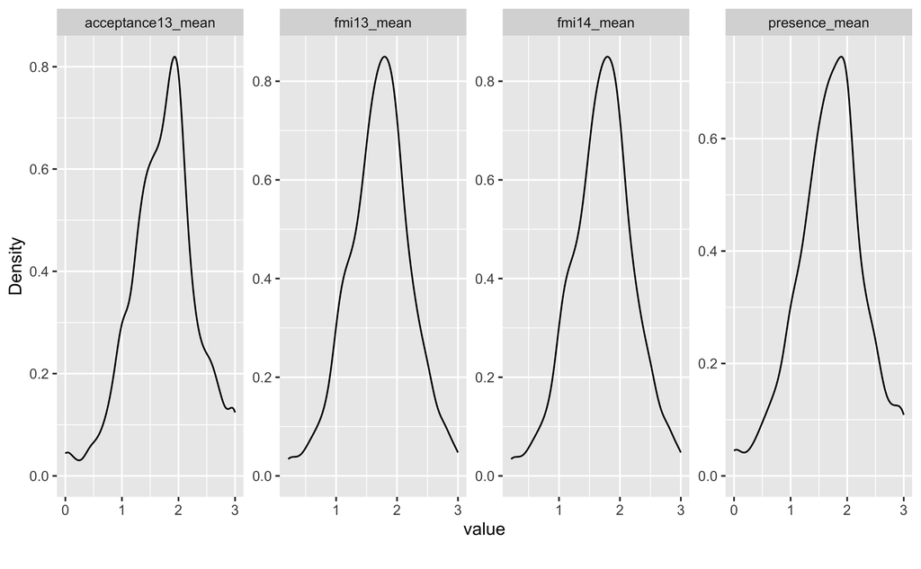

```r
d_w_items %>%
  select(ends_with("_mean")) %>%
  plot_density() + theme_minimal()
```

Alternative visualization, keeping the x-axis constant:

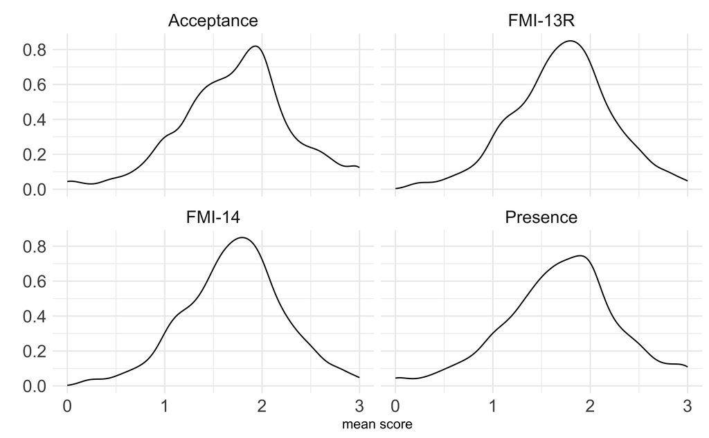

```r
facet_labs <- c(acceptance13_mean = "Acceptance",
                fmi13_mean = "FMI-13R",
                fmi14_mean = "FMI-14",
                presence_mean = "Presence")


d_w_items %>%
  select(ends_with("_mean")) %>%
  pivot_longer(everything()) %>%
  ggplot(aes(x = value)) +
  geom_density() +
  facet_wrap(~ name, labeller = as_labeller(facet_labs)) +
  theme_minimal() +
  theme(strip.text = element_text(size = 14),
                axis.text = element_text(size =14)) +
  labs(y = "",
       x = "mean score")
```

## 4.2 Descriptive statistics

“Mean01” refers to a 0-1-standardized mean.

```r
d_w_items %>%
  select(ends_with("_mean")) %>%
  describe_distribution(iqr = FALSE, range = TRUE, quartiles = TRUE) %>%
  mutate(Mean01 = Mean/3) %>%
  mutate(Model = c("FMI-13R", "Presence", "Acceptance", "FMI-14")) |>
  relocate(Mean01, .after = Mean) %>%
  relocate(Model, .before = everything()) |>
  select(-Variable, -n_Missing) |>
  knitr::kable(digits = 2)
```

| Model | Mean | Mean01 | SD | Min | Max | Q1 | Q3 | Skewness | Kurtosis | n |
| --- | --- | --- | --- | --- | --- | --- | --- | --- | --- | --- |
| FMI-13R | 1.71 | 0.57 | 0.51 | 0.21 | 3 | 1.36 | 2 | -0.15 | 0.16 | 1012 |
| Presence | 1.70 | 0.57 | 0.59 | 0.00 | 3 | 1.33 | 2 | -0.24 | 0.19 | 1012 |
| Acceptance | 1.73 | 0.58 | 0.58 | 0.00 | 3 | 1.43 | 2 | -0.22 | 0.27 | 1012 |
| FMI-14 | 1.71 | 0.57 | 0.51 | 0.21 | 3 | 1.36 | 2 | -0.15 | 0.16 | 1012 |

## 4.3 Norms

```r
d_w_items %>%
  select(ends_with("_mean")) %>%
  map(~ knitr::kable(compute_all_norms(., min_score = 0, max_score = 3, by = .1),
                     digits = 2))
```

$fmi13_mean

| score | perc_rank | z | stanine | T | perc_normal |
| --- | --- | --- | --- | --- | --- |
| 0.0 | 0.00 | -3.37 | 1.00 | 16.35 | 0.00 |
| 0.1 | 0.00 | -3.17 | 1.00 | 18.31 | 0.00 |
| 0.2 | 0.00 | -2.97 | 1.00 | 20.28 | 0.00 |
| 0.3 | 0.01 | -2.78 | 1.00 | 22.24 | 0.00 |
| 0.4 | 0.01 | -2.58 | 1.00 | 24.21 | 0.00 |
| 0.5 | 0.02 | -2.38 | 1.00 | 26.17 | 0.01 |
| 0.6 | 0.02 | -2.19 | 1.00 | 28.13 | 0.01 |
| 0.7 | 0.03 | -1.99 | 1.02 | 30.10 | 0.02 |
| 0.8 | 0.04 | -1.79 | 1.41 | 32.06 | 0.04 |
| 0.9 | 0.05 | -1.60 | 1.80 | 34.02 | 0.06 |
| 1.0 | 0.09 | -1.40 | 2.20 | 35.99 | 0.08 |
| 1.1 | 0.12 | -1.20 | 2.59 | 37.95 | 0.11 |
| 1.2 | 0.15 | -1.01 | 2.98 | 39.92 | 0.16 |
| 1.3 | 0.21 | -0.81 | 3.38 | 41.88 | 0.21 |
| 1.4 | 0.25 | -0.62 | 3.77 | 43.84 | 0.27 |
| 1.5 | 0.34 | -0.42 | 4.16 | 45.81 | 0.34 |
| 1.6 | 0.40 | -0.22 | 4.55 | 47.77 | 0.41 |
| 1.7 | 0.45 | -0.03 | 4.95 | 49.74 | 0.49 |
| 1.8 | 0.58 | 0.17 | 5.34 | 51.70 | 0.57 |
| 1.9 | 0.64 | 0.37 | 5.73 | 53.66 | 0.64 |
| 2.0 | 0.76 | 0.56 | 6.13 | 55.63 | 0.71 |
| 2.1 | 0.80 | 0.76 | 6.52 | 57.59 | 0.78 |
| 2.2 | 0.83 | 0.96 | 6.91 | 59.56 | 0.83 |
| 2.3 | 0.89 | 1.15 | 7.30 | 61.52 | 0.88 |
| 2.4 | 0.91 | 1.35 | 7.70 | 63.48 | 0.91 |
| 2.5 | 0.95 | 1.54 | 8.09 | 65.45 | 0.94 |
| 2.6 | 0.96 | 1.74 | 8.48 | 67.41 | 0.96 |
| 2.7 | 0.97 | 1.94 | 8.88 | 69.38 | 0.97 |
| 2.8 | 0.99 | 2.13 | 9.00 | 71.34 | 0.98 |
| 2.9 | 0.99 | 2.33 | 9.00 | 73.30 | 0.99 |
| 3.0 | 1.00 | 2.53 | 9.00 | 75.27 | 0.99 |

$presence_mean

| score | perc_rank | z | stanine | T | perc_normal |
| --- | --- | --- | --- | --- | --- |
| 0.0 | 0.01 | -2.86 | 1.00 | 21.37 | 0.00 |
| 0.1 | 0.01 | -2.69 | 1.00 | 23.06 | 0.00 |
| 0.2 | 0.02 | -2.53 | 1.00 | 24.74 | 0.01 |
| 0.3 | 0.02 | -2.36 | 1.00 | 26.43 | 0.01 |
| 0.4 | 0.02 | -2.19 | 1.00 | 28.12 | 0.01 |
| 0.5 | 0.04 | -2.02 | 1.00 | 29.80 | 0.02 |
| 0.6 | 0.04 | -1.85 | 1.30 | 31.49 | 0.03 |
| 0.7 | 0.06 | -1.68 | 1.64 | 33.18 | 0.05 |
| 0.8 | 0.06 | -1.51 | 1.97 | 34.86 | 0.07 |
| 0.9 | 0.09 | -1.34 | 2.31 | 36.55 | 0.09 |
| 1.0 | 0.15 | -1.18 | 2.65 | 38.24 | 0.12 |
| 1.1 | 0.15 | -1.01 | 2.98 | 39.92 | 0.16 |
| 1.2 | 0.21 | -0.84 | 3.32 | 41.61 | 0.20 |
| 1.3 | 0.21 | -0.67 | 3.66 | 43.30 | 0.25 |
| 1.4 | 0.29 | -0.50 | 4.00 | 44.99 | 0.31 |
| 1.5 | 0.40 | -0.33 | 4.33 | 46.67 | 0.37 |
| 1.6 | 0.40 | -0.16 | 4.67 | 48.36 | 0.43 |
| 1.7 | 0.52 | 0.00 | 5.01 | 50.05 | 0.50 |
| 1.8 | 0.52 | 0.17 | 5.35 | 51.73 | 0.57 |
| 1.9 | 0.64 | 0.34 | 5.68 | 53.42 | 0.63 |
| 2.0 | 0.77 | 0.51 | 6.02 | 55.11 | 0.70 |
| 2.1 | 0.77 | 0.68 | 6.36 | 56.79 | 0.75 |
| 2.2 | 0.84 | 0.85 | 6.70 | 58.48 | 0.80 |
| 2.3 | 0.84 | 1.02 | 7.03 | 60.17 | 0.85 |
| 2.4 | 0.89 | 1.19 | 7.37 | 61.85 | 0.88 |
| 2.5 | 0.93 | 1.35 | 7.71 | 63.54 | 0.91 |
| 2.6 | 0.93 | 1.52 | 8.05 | 65.23 | 0.94 |
| 2.7 | 0.96 | 1.69 | 8.38 | 66.91 | 0.95 |
| 2.8 | 0.96 | 1.86 | 8.72 | 68.60 | 0.97 |
| 2.9 | 0.98 | 2.03 | 9.00 | 70.29 | 0.98 |
| 3.0 | 1.00 | 2.20 | 9.00 | 71.97 | 0.99 |

$acceptance13_mean

| score | perc_rank | z | stanine | T | perc_normal |
| --- | --- | --- | --- | --- | --- |
| 0.0 | 0.01 | -2.99 | 1.00 | 20.06 | 0.00 |
| 0.1 | 0.01 | -2.82 | 1.00 | 21.78 | 0.00 |
| 0.2 | 0.01 | -2.65 | 1.00 | 23.51 | 0.00 |
| 0.3 | 0.02 | -2.48 | 1.00 | 25.24 | 0.01 |
| 0.4 | 0.02 | -2.30 | 1.00 | 26.96 | 0.01 |
| 0.5 | 0.03 | -2.13 | 1.00 | 28.69 | 0.02 |
| 0.6 | 0.04 | -1.96 | 1.08 | 30.42 | 0.03 |
| 0.7 | 0.04 | -1.79 | 1.43 | 32.14 | 0.04 |
| 0.8 | 0.05 | -1.61 | 1.77 | 33.87 | 0.05 |
| 0.9 | 0.08 | -1.44 | 2.12 | 35.60 | 0.07 |
| 1.0 | 0.13 | -1.27 | 2.47 | 37.33 | 0.10 |
| 1.1 | 0.13 | -1.09 | 2.81 | 39.05 | 0.14 |
| 1.2 | 0.17 | -0.92 | 3.16 | 40.78 | 0.18 |
| 1.3 | 0.24 | -0.75 | 3.50 | 42.51 | 0.23 |
| 1.4 | 0.24 | -0.58 | 3.85 | 44.23 | 0.28 |
| 1.5 | 0.33 | -0.40 | 4.19 | 45.96 | 0.34 |
| 1.6 | 0.42 | -0.23 | 4.54 | 47.69 | 0.41 |
| 1.7 | 0.42 | -0.06 | 4.88 | 49.41 | 0.48 |
| 1.8 | 0.51 | 0.11 | 5.23 | 51.14 | 0.55 |
| 1.9 | 0.63 | 0.29 | 5.57 | 52.87 | 0.61 |
| 2.0 | 0.75 | 0.46 | 5.92 | 54.60 | 0.68 |
| 2.1 | 0.75 | 0.63 | 6.26 | 56.32 | 0.74 |
| 2.2 | 0.82 | 0.80 | 6.61 | 58.05 | 0.79 |
| 2.3 | 0.87 | 0.98 | 6.96 | 59.78 | 0.84 |
| 2.4 | 0.87 | 1.15 | 7.30 | 61.50 | 0.87 |
| 2.5 | 0.90 | 1.32 | 7.65 | 63.23 | 0.91 |
| 2.6 | 0.94 | 1.50 | 7.99 | 64.96 | 0.93 |
| 2.7 | 0.94 | 1.67 | 8.34 | 66.68 | 0.95 |
| 2.8 | 0.96 | 1.84 | 8.68 | 68.41 | 0.97 |
| 2.9 | 0.98 | 2.01 | 9.00 | 70.14 | 0.98 |
| 3.0 | 1.00 | 2.19 | 9.00 | 71.87 | 0.99 |

$fmi14_mean

| score | perc_rank | z | stanine | T | perc_normal |
| --- | --- | --- | --- | --- | --- |
| 0.0 | 0.00 | -3.37 | 1.00 | 16.35 | 0.00 |
| 0.1 | 0.00 | -3.17 | 1.00 | 18.31 | 0.00 |
| 0.2 | 0.00 | -2.97 | 1.00 | 20.28 | 0.00 |
| 0.3 | 0.01 | -2.78 | 1.00 | 22.24 | 0.00 |
| 0.4 | 0.01 | -2.58 | 1.00 | 24.21 | 0.00 |
| 0.5 | 0.02 | -2.38 | 1.00 | 26.17 | 0.01 |
| 0.6 | 0.02 | -2.19 | 1.00 | 28.13 | 0.01 |
| 0.7 | 0.03 | -1.99 | 1.02 | 30.10 | 0.02 |
| 0.8 | 0.04 | -1.79 | 1.41 | 32.06 | 0.04 |
| 0.9 | 0.05 | -1.60 | 1.80 | 34.02 | 0.06 |
| 1.0 | 0.09 | -1.40 | 2.20 | 35.99 | 0.08 |
| 1.1 | 0.12 | -1.20 | 2.59 | 37.95 | 0.11 |
| 1.2 | 0.15 | -1.01 | 2.98 | 39.92 | 0.16 |
| 1.3 | 0.21 | -0.81 | 3.38 | 41.88 | 0.21 |
| 1.4 | 0.25 | -0.62 | 3.77 | 43.84 | 0.27 |
| 1.5 | 0.34 | -0.42 | 4.16 | 45.81 | 0.34 |
| 1.6 | 0.40 | -0.22 | 4.55 | 47.77 | 0.41 |
| 1.7 | 0.45 | -0.03 | 4.95 | 49.74 | 0.49 |
| 1.8 | 0.58 | 0.17 | 5.34 | 51.70 | 0.57 |
| 1.9 | 0.64 | 0.37 | 5.73 | 53.66 | 0.64 |
| 2.0 | 0.76 | 0.56 | 6.13 | 55.63 | 0.71 |
| 2.1 | 0.80 | 0.76 | 6.52 | 57.59 | 0.78 |
| 2.2 | 0.83 | 0.96 | 6.91 | 59.56 | 0.83 |
| 2.3 | 0.89 | 1.15 | 7.30 | 61.52 | 0.88 |
| 2.4 | 0.91 | 1.35 | 7.70 | 63.48 | 0.91 |
| 2.5 | 0.95 | 1.54 | 8.09 | 65.45 | 0.94 |
| 2.6 | 0.96 | 1.74 | 8.48 | 67.41 | 0.96 |
| 2.7 | 0.97 | 1.94 | 8.88 | 69.38 | 0.97 |
| 2.8 | 0.99 | 2.13 | 9.00 | 71.34 | 0.98 |
| 2.9 | 0.99 | 2.33 | 9.00 | 73.30 | 0.99 |
| 3.0 | 1.00 | 2.53 | 9.00 | 75.27 | 0.99 |

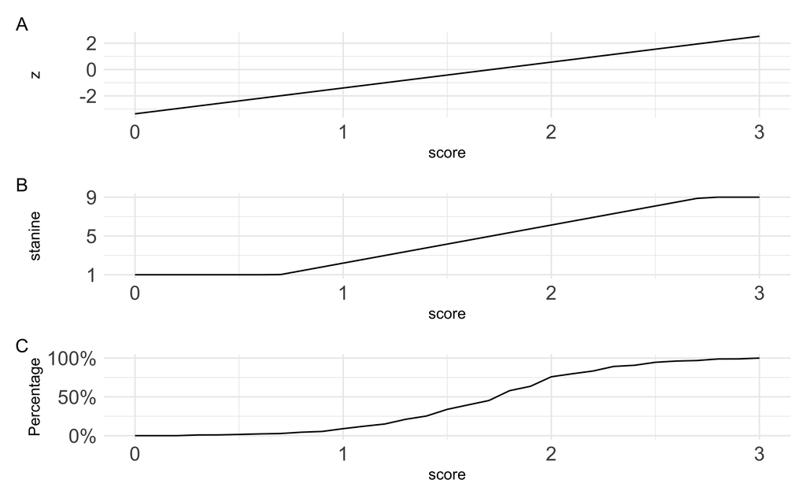

```r
norms <-
d_w_items %>%
  select(ends_with("_mean")) %>%
  map(~ compute_all_norms(.,
                          min_score = 0,
                          max_score = 3,
                          by = .1),
      digits = 2)


p_norm1 <-
norms %>%
  pluck(1) %>%
  ggplot(aes(x = score, y = z)) +
  geom_line() +
  scale_y_continuous(breaks = c(-2, 0, 2)) +
  theme(strip.text = element_text(size = 14),
                axis.text = element_text(size =14))


p_norm2 <-
norms %>%
  pluck(1) %>%
  ggplot(aes(x = score, y = stanine)) +
  geom_line() +
  scale_y_continuous(breaks = c(1, 5, 9)) +
  theme(strip.text = element_text(size = 14),
                axis.text = element_text(size =14))


p_norm3 <-
norms %>%
  pluck(1) %>%
  ggplot(aes(x = score, y = perc_rank)) +
  geom_line() +
  labs(y = "Percentage")  +
  scale_y_continuous(breaks = c(0, .5, 1),

                     labels = c("0%", "50%", "100%")) +
  theme(strip.text = element_text(size = 14),
                axis.text = element_text(size =14))


see::plots(p_norm1, p_norm2, p_norm3, tags = TRUE,
           n_rows = 3)
```

```r
#
# see::plots(p_norm1, p_norm2, p_norm3, tags = TRUE,
#            n_rows = 3,
#            title =  "FMI-13R mean value (x-axis) vs. different norm values (y-axis)")
```

# 5 Item statistics and reliability

## 5.1 FMI14

Item statistics:

```r
fmi14_desc1 <-
d_w_items |>
  select(starts_with("ffa_", ignore.case = FALSE)) |>
  psych::alpha()

col_names <- c("Nr.", "mean", "*SD*", "*r<sub>it</sub>*", "*r<sub>it</sub> dropped*")

fmi14_desc1[["item.stats"]] |>
  mutate(nr = 1:14) |>
  select(nr, mean, sd, r.cor, r.drop) |>
    kable(col.names = col_names, escape = FALSE, digits = 2, row.names = FALSE)
```

| Nr. | mean | *SD* | *r<sub>it</sub>* | *r<sub>it</sub> dropped* |
| --- | --- | --- | --- | --- |
| 1 | 1.91 | 0.85 | 0.53 | 0.49 |
| 2 | 1.51 | 0.89 | 0.50 | 0.46 |
| 3 | 1.42 | 0.86 | 0.49 | 0.45 |
| 4 | 1.89 | 0.86 | 0.62 | 0.57 |
| 5 | 1.84 | 0.83 | 0.67 | 0.63 |
| 6 | 1.80 | 0.82 | 0.65 | 0.60 |
| 7 | 1.78 | 0.84 | 0.68 | 0.63 |
| 8 | 1.84 | 0.77 | 0.53 | 0.49 |
| 9 | 1.71 | 0.84 | 0.66 | 0.61 |
| 10 | 1.72 | 0.85 | 0.67 | 0.62 |
| 11 | 1.74 | 0.84 | 0.68 | 0.64 |
| 12 | 1.54 | 0.86 | 0.66 | 0.61 |
| 13 | 1.67 | 0.90 | 0.01 | 0.00 |
| 14 | 1.60 | 0.84 | 0.55 | 0.51 |

Omega:

```r
fmi14_omega <-
d_w_items |>
  select(starts_with("ffa_", ignore.case = FALSE)) |>
  psych::omega(nfactors = 1)

fmi14_omega
```

```
## Omega
## Call: omegah(m = m, nfactors = nfactors, fm = fm, key = key, flip = flip,
##     digits = digits, title = title, sl = sl, labels = labels,
##     plot = plot, n.obs = n.obs, rotate = rotate, Phi = Phi, option = option,
##     covar = covar)
## Alpha:                 0.87
## G.6:                   0.87
## Omega Hierarchical:    0.87
## Omega H asymptotic:    1
## Omega Total            0.87
##
## Schmid Leiman Factor loadings greater than  0.2
##            g  F1*   h2   h2   u2 p2 com
## ffa_1   0.53      0.28 0.28 0.72  1   1
## ffa_2   0.51      0.26 0.26 0.74  1   1
## ffa_3   0.49      0.24 0.24 0.76  1   1
## ffa_4   0.61      0.37 0.37 0.63  1   1
## ffa_5   0.67      0.45 0.45 0.55  1   1
## ffa_6   0.65      0.43 0.43 0.57  1   1
## ffa_7   0.69      0.47 0.47 0.53  1   1
## ffa_8   0.53      0.28 0.28 0.72  1   1
## ffa_9   0.65      0.42 0.42 0.58  1   1
## ffa_10  0.67      0.45 0.45 0.55  1   1
## ffa_11  0.67      0.45 0.45 0.55  1   1
## ffa_12  0.66      0.43 0.43 0.57  1   1
## ffa_13r                0.00 1.00  1   1
## ffa_14  0.56      0.31 0.31 0.69  1   1
##
## With Sums of squares  of:
##   g F1*  h2
## 4.9 0.0 1.9
##
## general/max  2.55   max/min =   1.939515e+16
## mean percent general =  1    with sd =  0 and cv of  0
## Explained Common Variance of the general factor =  1
##
## The degrees of freedom are 77  and the fit is  0.4
## The number of observations was  1012  with Chi Square =  402.03  with prob <  1.7e-45
## The root mean square of the residuals is  0.05
## The df corrected root mean square of the residuals is  0.05
```

[output cut: 8 more lines]

```
##
## RMSEA index =  0.065  and the 10 % confidence intervals are  0.058 0.071
## BIC =  -130.78
##
## Measures of factor score adequacy
##                                                  g F1*
## Correlation of scores with factors            0.94   0
## Multiple R square of scores with factors      0.89   0
## Minimum correlation of factor score estimates 0.78  -1
##
##  Total, General and Subset omega for each subset
##                                                  g  F1*
## Omega total for total scores and subscales    0.87 0.87
## Omega general for total scores and subscales  0.87 0.87
## Omega group for total scores and subscales    0.00 0.00
```

## 5.2 FMI13-R

```r
fmi13_desc1 <-
d_w_items |>
  select(starts_with("ffa_", ignore.case = FALSE)) |>
  select(-ffa_13r) |>
  psych::alpha()

col_names <- c("Nr.", "mean", "*SD*", "*r<sub>it</sub>*", "*r<sub>it</sub> dropped*")

fmi13_desc1[["item.stats"]] |>
  mutate(nr = 1:13) |>
  select(nr, mean, sd, r.cor, r.drop) |>
    kable(col.names = col_names, escape = FALSE, digits = 2, row.names = FALSE)
```

| Nr. | mean | *SD* | *r<sub>it</sub>* | *r<sub>it</sub> dropped* |
| --- | --- | --- | --- | --- |
| 1 | 1.91 | 0.85 | 0.53 | 0.50 |
| 2 | 1.51 | 0.89 | 0.52 | 0.49 |
| 3 | 1.42 | 0.86 | 0.50 | 0.47 |
| 4 | 1.89 | 0.86 | 0.61 | 0.57 |
| 5 | 1.84 | 0.83 | 0.67 | 0.63 |
| 6 | 1.80 | 0.82 | 0.65 | 0.61 |
| 7 | 1.78 | 0.84 | 0.68 | 0.64 |
| 8 | 1.84 | 0.77 | 0.53 | 0.50 |
| 9 | 1.71 | 0.84 | 0.64 | 0.60 |
| 10 | 1.72 | 0.85 | 0.67 | 0.63 |
| 11 | 1.74 | 0.84 | 0.67 | 0.63 |
| 12 | 1.54 | 0.86 | 0.66 | 0.62 |
| 13 | 1.60 | 0.84 | 0.56 | 0.52 |

Omega:

```r
fmi13_omega <-
d_w_items |>
  select(starts_with("ffa_", ignore.case = FALSE)) |>
  select(-ffa_13r) |>
  psych::omega(nfactors = 1)

fmi13_omega
```

```
## Omega
## Call: omegah(m = m, nfactors = nfactors, fm = fm, key = key, flip = flip,
##     digits = digits, title = title, sl = sl, labels = labels,
##     plot = plot, n.obs = n.obs, rotate = rotate, Phi = Phi, option = option,
##     covar = covar)
## Alpha:                 0.88
## G.6:                   0.88
## Omega Hierarchical:    0.88
## Omega H asymptotic:    1
## Omega Total            0.88
##
## Schmid Leiman Factor loadings greater than  0.2
##           g  F1*   h2   h2   u2 p2 com
## ffa_1  0.53      0.28 0.28 0.72  1   1
## ffa_2  0.51      0.26 0.26 0.74  1   1
## ffa_3  0.49      0.24 0.24 0.76  1   1
## ffa_4  0.61      0.37 0.37 0.63  1   1
## ffa_5  0.67      0.45 0.45 0.55  1   1
## ffa_6  0.65      0.43 0.43 0.57  1   1
## ffa_7  0.69      0.47 0.47 0.53  1   1
## ffa_8  0.53      0.28 0.28 0.72  1   1
## ffa_9  0.65      0.42 0.42 0.58  1   1
## ffa_10 0.67      0.45 0.45 0.55  1   1
## ffa_11 0.67      0.45 0.45 0.55  1   1
## ffa_12 0.66      0.43 0.43 0.57  1   1
## ffa_14 0.56      0.31 0.31 0.69  1   1
##
## With Sums of squares  of:
##   g F1*  h2
## 4.9 0.0 1.9
##
## general/max  2.55   max/min =   Inf
## mean percent general =  1    with sd =  0 and cv of  0
## Explained Common Variance of the general factor =  1
##
## The degrees of freedom are 65  and the fit is  0.32
## The number of observations was  1012  with Chi Square =  323.71  with prob <  5.3e-36
## The root mean square of the residuals is  0.04
## The df corrected root mean square of the residuals is  0.05
## RMSEA index =  0.063  and the 10 % confidence intervals are  0.056 0.07
## BIC =  -126.07
##
## Compare this with the adequacy of just a general factor and no group factors
## The degrees of freedom for just the general factor are 65  and the fit is  0.32
## The number of observations was  1012  with Chi Square =  323.71  with prob <  5.3e-36
## The root mean square of the residuals is  0.04
## The df corrected root mean square of the residuals is  0.05
##
## RMSEA index =  0.063  and the 10 % confidence intervals are  0.056 0.07
## BIC =  -126.07
##
## Measures of factor score adequacy
##                                                  g F1*
## Correlation of scores with factors            0.94   0
## Multiple R square of scores with factors      0.89   0
## Minimum correlation of factor score estimates 0.78  -1
##
##  Total, General and Subset omega for each subset
##                                                  g  F1*
## Omega total for total scores and subscales    0.88 0.88
## Omega general for total scores and subscales  0.88 0.88
## Omega group for total scores and subscales    0.00 0.00
```

# 6 CFA

rename the items for the sake of brevity:

```r
fmi_items <-
 d_w_items %>%
  select(starts_with("ffa"), mindfulness_experience) |>
  rename_with(~ gsub("^ffa_(\\d+[a-zA-Z]?)$", "i\\1", .),
              starts_with("ffa_"))
```

## 6.1 Setup

```r
cfa_results <- list()

get_results_list <- function(cfa_model, model_name) {
  out <- list()

  out <- list(
    obj_name = deparse(substitute(cfa_model)),
    model_name = model_name,
   # overview = list(summary(cfa_model)),
    cfi = fitMeasures(cfa_model)["cfi"],
    tli = fitMeasures(cfa_model)["tli"],
    rmsea = fitMeasures(cfa_model)["rmsea"],
    srmr = fitMeasures(cfa_model)["srmr"]
  )
}
```

```r
polychoric_r <- polychoric(fmi_items |> select(-mindfulness_experience))

polychoric_rho <- polychoric_r$rho

polychoric_rho[lower.tri(polychoric_r$rho, diag = FALSE)] <- NA

polychoric_rho |> kable( digits = 2)
```

|  | i1 | i2 | i3 | i4 | i5 | i6 | i7 | i8 | i9 | i10 | i11 | i12 | i13r | i14 |
| --- | --- | --- | --- | --- | --- | --- | --- | --- | --- | --- | --- | --- | --- | --- |
| i1 | 1 | 0.4 | 0.34 | 0.35 | 0.40 | 0.37 | 0.48 | 0.38 | 0.38 | 0.40 | 0.39 | 0.36 | -0.01 | 0.36 |
| i2 | NA | 1.0 | 0.48 | 0.31 | 0.44 | 0.30 | 0.41 | 0.32 | 0.28 | 0.39 | 0.35 | 0.39 | -0.15 | 0.35 |
| i3 | NA | NA | 1.00 | 0.30 | 0.39 | 0.31 | 0.40 | 0.29 | 0.29 | 0.41 | 0.33 | 0.40 | -0.15 | 0.34 |
| i4 | NA | NA | NA | 1.00 | 0.55 | 0.57 | 0.47 | 0.33 | 0.51 | 0.43 | 0.49 | 0.45 | 0.09 | 0.40 |
| i5 | NA | NA | NA | NA | 1.00 | 0.53 | 0.53 | 0.39 | 0.43 | 0.58 | 0.53 | 0.46 | 0.03 | 0.40 |
| i6 | NA | NA | NA | NA | NA | 1.00 | 0.56 | 0.42 | 0.51 | 0.47 | 0.50 | 0.47 | 0.03 | 0.42 |
| i7 | NA | NA | NA | NA | NA | NA | 1.00 | 0.50 | 0.49 | 0.51 | 0.49 | 0.49 | -0.03 | 0.42 |
| i8 | NA | NA | NA | NA | NA | NA | NA | 1.00 | 0.43 | 0.43 | 0.41 | 0.39 | -0.04 | 0.30 |
| i9 | NA | NA | NA | NA | NA | NA | NA | NA | 1.00 | 0.54 | 0.55 | 0.57 | 0.11 | 0.43 |
| i10 | NA | NA | NA | NA | NA | NA | NA | NA | NA | 1.00 | 0.56 | 0.50 | 0.01 | 0.40 |
| i11 | NA | NA | NA | NA | NA | NA | NA | NA | NA | NA | 1.00 | 0.56 | 0.14 | 0.43 |
| i12 | NA | NA | NA | NA | NA | NA | NA | NA | NA | NA | NA | 1.00 | 0.02 | 0.49 |
| i13r | NA | NA | NA | NA | NA | NA | NA | NA | NA | NA | NA | NA | 1.00 | -0.06 |
| i14 | NA | NA | NA | NA | NA | NA | NA | NA | NA | NA | NA | NA | NA | 1.00 |

## 6.2 One general mindfulness factor, including item 13

```r
FMI14 <-
  "General_Factor=~i1+i2+i3+i4+i5+i6+i7+i8+i9+i10+i11+i12+i13r+i14"
```

### 6.2.1 items as categorical, Pearson

```r
one_factor_ordered_pearson <- cfa(FMI14,
                          data = fmi_items,
                          estimator = "DWLS",
                          ordered = TRUE)

cfa_results[["FMI-14, ordered, Pearson"]] <-
  get_results_list(one_factor_ordered_pearson,
                   model_name = "FMI-14, ordered, Pearson")
```

### 6.2.2 items as categorical, Polychoric

```r
one_factor_ordered_polychoric <- cfa(FMI14,
                                      data = fmi_items,
                                      estimator = "DWLS",
                                      sample.cov = polychoric_rho,
                                      ordered = TRUE)

cfa_results[["FMI-14, ordered, polychoric"]] <-
  get_results_list(one_factor_ordered_polychoric,
                   model_name = "FMI-14, ordered, polychoric")
```

### 6.2.3 items as numerical

```r
one_factor_numeric <- cfa(FMI14, data = fmi_items)

  cfa_results[["FMI-14, numeric"]] <-
  get_results_list(one_factor_numeric,
                   model_name = "FMI-14, numeric")
```

### 6.2.4 items as categorical, Polychoric, mindfulness practitioners only

```r
one_factor_ordered_polychoric_practitioners <- cfa(FMI14,
                                     data = fmi_items |> filter(mindfulness_experience == 1),
                                      estimator = "DWLS",
                                      sample.cov = polychoric_rho,
                                      ordered = TRUE)

cfa_results[["FMI-14, ordered, polychoric, mindfulness practitioners"]] <-
  get_results_list(one_factor_ordered_polychoric_practitioners,
                   model_name = "FMI-14, ordered, polychoric, mindfulness practitioners")
```

## 6.3 Two factors (presence, acceptance) without item 13, correlated factors

```r
FMI13R <- "
# Presence:
presence =~ i1 + i2 + i3 + i5 + i7 + i10

acceptance =~ i4 + i6 + i8 + i9 + i11 + i12 + i14

presence ~~ acceptance
"
```

### 6.3.1 items as numeric:

```r
two_factors_numeric <- cfa(FMI13R,
                           data = fmi_items)

cfa_results[["FMI-13R, numeric"]] <-
  get_results_list(two_factors_numeric,
                   model_name = "FMI-13R, numeric")
```

### 6.3.2 items as categorical, Pearson

```r
model_two_dim_wo_13_ordered <- cfa(FMI13R,
                                   data = fmi_items,
                                   estimator = "DWLS",
                                   ordered = TRUE)


cfa_results[["FMI-13R, ordered, Pearson"]] <-
  get_results_list(model_two_dim_wo_13_ordered,
                   model_name = "FMI-13R, ordered, Pearson")
```

### 6.3.3 items as categorical, Polychoric

```r
model_two_dim_wo_13_ordered_poly<- cfa(FMI13R,
                                   data = fmi_items,
                                   estimator = "DWLS",
                                   sample.cov = polychoric_rho,
                                   ordered = TRUE)


cfa_results[["FMI-13R, ordered, polychoric"]] <-
  get_results_list(model_two_dim_wo_13_ordered_poly,
                   "FMI-13R, ordered, polychoric")
```

### 6.3.4 Plot

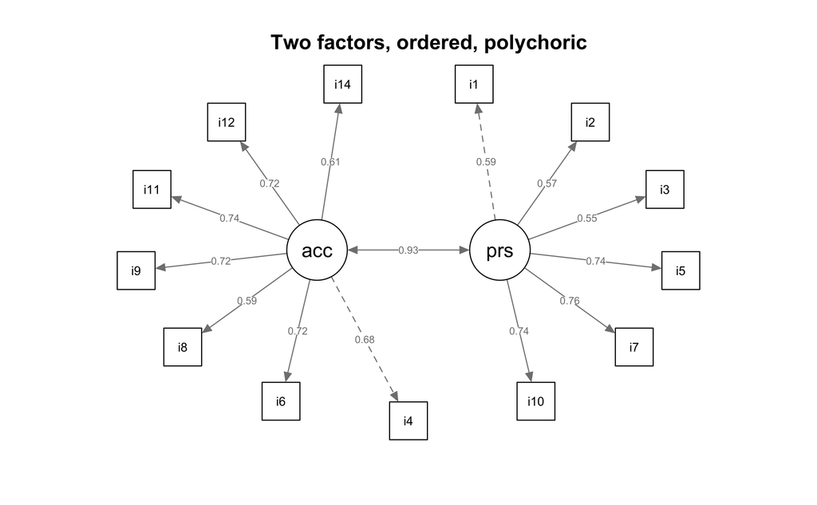

```r
semPaths(model_two_dim_wo_13_ordered_poly,
         what = "path",
         whatLabels = "stand",
         layout = "circle",
        # sizeMan = 3,
         #style = "lisrel",
         residuals = FALSE,
         #fixed = FALSE,
         intercepts = FALSE,
         normalize = FALSE,
         thresholds = F,
         width = 12,
         height = 6,
        # rotation = 2,
        # intAtSide = TRUE,
       #  nCharNodes = 0
)
title("Two factors, ordered, polychoric")
```

Standardized parameters are shown (loadings, correlations).

## 6.4 Two correlated factors, individuals with meditation practice only

### 6.4.1 items as numeric

```r
model_two_dim_wo_13_meditators_only <-
  cfa(FMI13R,
      data = fmi_items |> filter(mindfulness_experience == 1))


cfa_results[["FMI-13R, numeric, mindfulness practitioners"]] <-
  get_results_list(model_two_dim_wo_13_meditators_only,
                   model_name = "FMI-13R, numeric, mindfulness practitioners")
```

### 6.4.2 items as categorical, Pearson

```r
model_two_dim_wo_13_meditators_only_categorical <-
  cfa(FMI13R,
      estimator = "DWLS",
      ordered = TRUE,
      data = fmi_items |> filter(mindfulness_experience == 1))

cfa_results[["FMI-13R, ordered, Pearson, mindfulness practitioners"]] <-
  get_results_list(model_two_dim_wo_13_meditators_only_categorical,
                   model_name = "FMI-13R, ordered, Pearson, mindfulness practitioners")
```

```r
model_two_dim_wo_13_meditators_only_categorical_poly <-
  cfa(FMI13R,
      estimator = "DWLS",
      ordered = TRUE,
      data = fmi_items |> filter(mindfulness_experience == 1))

cfa_results[["FMI-13R, ordered, polychoric, mindfulness practitioners"]] <-
  get_results_list(model_two_dim_wo_13_meditators_only_categorical_poly,
                   model_name = "FMI-13R, ordered, polychoric, mindfulness practitioners")
```

## 6.5 Results

```r
cfa_results_df <-
  do.call(rbind, lapply(cfa_results, as.data.frame))

cfa_results_df |>
  select(-obj_name) |>
  mutate(Nr = 1:nrow(cfa_results_df)) |>
  rename(Model = model_name,
         CFI = cfi,
         TLI = tli,
         RMSEA = rmsea,
         SRMR = srmr) |>
  relocate(Nr, .before = everything()) |>
  kable(digits = 2, row.names = FALSE)
```

| Nr | Model | CFI | TLI | RMSEA | SRMR |
| --- | --- | --- | --- | --- | --- |
| 1 | FMI-14, ordered, Pearson | 0.99 | 0.99 | 0.06 | 0.05 |
| 2 | FMI-14, ordered, polychoric | 0.99 | 0.99 | 0.06 | 0.05 |
| 3 | FMI-14, numeric | 0.92 | 0.91 | 0.06 | 0.04 |
| 4 | FMI-14, ordered, polychoric, mindfulness practitioners | 1.00 | 1.00 | 0.03 | 0.04 |
| 5 | FMI-13R, numeric | 0.95 | 0.94 | 0.06 | 0.04 |
| 6 | FMI-13R, ordered, Pearson | 0.99 | 0.99 | 0.05 | 0.04 |
| 7 | FMI-13R, ordered, polychoric | 0.99 | 0.99 | 0.05 | 0.04 |
| 8 | FMI-13R, numeric, mindfulness practitioners | 0.97 | 0.97 | 0.04 | 0.03 |
| 9 | FMI-13R, ordered, Pearson, mindfulness practitioners | 1.00 | 1.00 | 0.02 | 0.04 |
| 10 | FMI-13R, ordered, polychoric, mindfulness practitioners | 1.00 | 1.00 | 0.02 | 0.04 |

# 7 Norm values for different subgroups

The following subgroup variables were considered:

```r
subgroup_vars <- c("Geschlecht", "Achts_regel", "Retreats", "Vip_regel", "age_below_md")
subgroup_vars
```

```
## [1] "Geschlecht"   "Achts_regel"  "Retreats"     "Vip_regel"    "age_below_md"
```

## 7.1 Split by sex

### 7.1.1 Stats

```r
d_w_items %>%
  #filter(Geschlecht %in% c("männlich", "weiblich")) %>%
  mutate(Geschlecht = as.character(Geschlecht)) %>%
  describe_fmi_stats(
                     var = Geschlecht)
```

Geschlecht=female

| Variable | Mean | Mean_01 | SD | Range | Quartiles | Skewness | Kurtosis | n | n_Missing |
| --- | --- | --- | --- | --- | --- | --- | --- | --- | --- |
| acceptance13_mean | 1.73 | 0.58 | 0.57 | (0.00, 3.00) | 1.29, 2.07 | -0.09 | -0.13 | 515 | 0 |
| fmi13_mean | 1.71 | 0.57 | 0.51 | (0.21, 3.00) | 1.36, 2.07 | -0.11 | -0.27 | 515 | 0 |
| fmi14_mean | 1.71 | 0.57 | 0.51 | (0.21, 3.00) | 1.36, 2.07 | -0.11 | -0.27 | 515 | 0 |
| presence_mean | 1.72 | 0.57 | 0.58 | (0.00, 3.00) | 1.33, 2.00 | -0.11 | -0.10 | 515 | 0 |

Geschlecht=male

| Variable | Mean | Mean_01 | SD | Range | Quartiles | Skewness | Kurtosis | n | n_Missing |
| --- | --- | --- | --- | --- | --- | --- | --- | --- | --- |
| acceptance13_mean | 1.74 | 0.58 | 0.59 | (0.00, 3.00) | 1.43, 2.00 | -0.34 | 0.65 | 495 | 0 |
| fmi13_mean | 1.71 | 0.57 | 0.51 | (0.21, 3.00) | 1.43, 2.00 | -0.19 | 0.58 | 495 | 0 |
| fmi14_mean | 1.71 | 0.57 | 0.51 | (0.21, 3.00) | 1.43, 2.00 | -0.19 | 0.58 | 495 | 0 |
| presence_mean | 1.67 | 0.56 | 0.60 | (0.00, 3.00) | 1.33, 2.00 | -0.35 | 0.42 | 495 | 0 |

Geschlecht=other

| Variable | Mean | Mean_01 | SD | Range | Quartiles | Skewness | Kurtosis | n | n_Missing |
| --- | --- | --- | --- | --- | --- | --- | --- | --- | --- |
| acceptance13_mean | 1.79 | 0.60 | 0.51 | (1.43, 2.14) | 1.61, 1.96 | 9.14e-16 | -2.00 | 2 | 0 |
| fmi13_mean | 1.50 | 0.50 | 0.20 | (1.36, 1.64) | 1.43, 1.57 | 0.00 | -2.00 | 2 | 0 |
| fmi14_mean | 1.50 | 0.50 | 0.20 | (1.36, 1.64) | 1.43, 1.57 | 0.00 | -2.00 | 2 | 0 |
| presence_mean | 1.33 | 0.44 | 0.00 | (1.33, 1.33) | 1.33, 1.33 |  |  | 2 | 0 |

Plot:

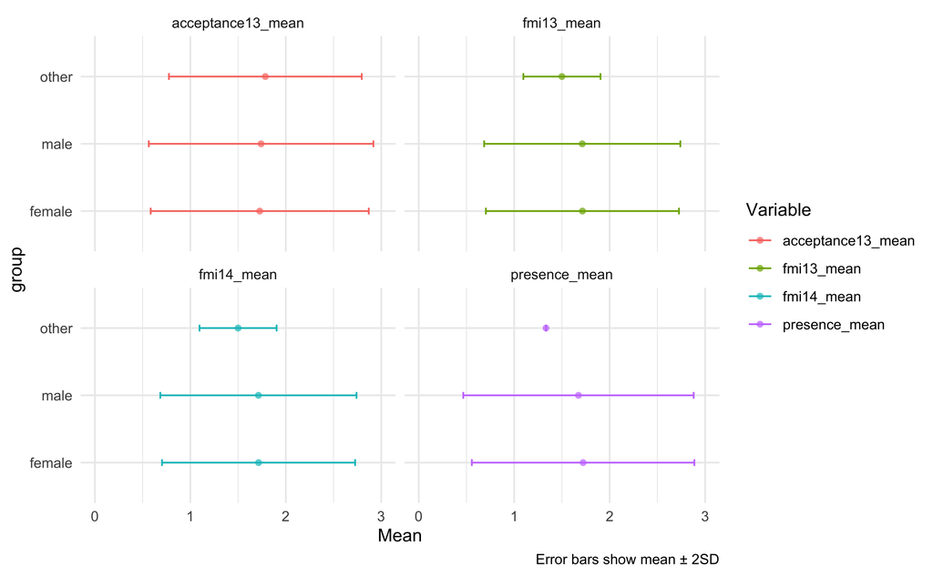

```r
plot_fmi_descriptives(data = d_w_items,
                      var = Geschlecht)
```

### 7.1.2 Norms

```r
for (i in unique(d_w_items$Geschlecht)) {
  cat("Group: ", i, "\n")
  d_w_items %>%
    filter(Geschlecht == i) %>%
    select(ends_with("_mean")) %>%
    map(~ knitr::kable(compute_all_norms(., min_score = 0, max_score = 3, by = .1),
                       digits = 2))  %>% print()
}
```

Group: male $fmi13_mean

| score | perc_rank | z | stanine | T | perc_normal |
| --- | --- | --- | --- | --- | --- |
| 0.0 | 0.00 | -3.33 | 1.00 | 16.67 | 0.00 |
| 0.1 | 0.00 | -3.14 | 1.00 | 18.61 | 0.00 |
| 0.2 | 0.00 | -2.94 | 1.00 | 20.56 | 0.00 |
| 0.3 | 0.01 | -2.75 | 1.00 | 22.50 | 0.00 |
| 0.4 | 0.02 | -2.55 | 1.00 | 24.45 | 0.01 |
| 0.5 | 0.02 | -2.36 | 1.00 | 26.40 | 0.01 |
| 0.6 | 0.03 | -2.17 | 1.00 | 28.34 | 0.02 |
| 0.7 | 0.03 | -1.97 | 1.06 | 30.29 | 0.02 |
| 0.8 | 0.05 | -1.78 | 1.45 | 32.23 | 0.04 |
| 0.9 | 0.05 | -1.58 | 1.84 | 34.18 | 0.06 |
| 1.0 | 0.08 | -1.39 | 2.23 | 36.13 | 0.08 |
| 1.1 | 0.12 | -1.19 | 2.61 | 38.07 | 0.12 |
| 1.2 | 0.15 | -1.00 | 3.00 | 40.02 | 0.16 |
| 1.3 | 0.19 | -0.80 | 3.39 | 41.96 | 0.21 |
| 1.4 | 0.23 | -0.61 | 3.78 | 43.91 | 0.27 |
| 1.5 | 0.33 | -0.41 | 4.17 | 45.86 | 0.34 |
| 1.6 | 0.39 | -0.22 | 4.56 | 47.80 | 0.41 |
| 1.7 | 0.46 | -0.03 | 4.95 | 49.75 | 0.49 |
| 1.8 | 0.59 | 0.17 | 5.34 | 51.69 | 0.57 |
| 1.9 | 0.65 | 0.36 | 5.73 | 53.64 | 0.64 |
| 2.0 | 0.77 | 0.56 | 6.12 | 55.58 | 0.71 |
| 2.1 | 0.81 | 0.75 | 6.51 | 57.53 | 0.77 |
| 2.2 | 0.84 | 0.95 | 6.90 | 59.48 | 0.83 |
| 2.3 | 0.90 | 1.14 | 7.28 | 61.42 | 0.87 |
| 2.4 | 0.91 | 1.34 | 7.67 | 63.37 | 0.91 |
| 2.5 | 0.94 | 1.53 | 8.06 | 65.31 | 0.94 |
| 2.6 | 0.96 | 1.73 | 8.45 | 67.26 | 0.96 |
| 2.7 | 0.96 | 1.92 | 8.84 | 69.21 | 0.97 |
| 2.8 | 0.98 | 2.12 | 9.00 | 71.15 | 0.98 |
| 2.9 | 0.98 | 2.31 | 9.00 | 73.10 | 0.99 |
| 3.0 | 1.00 | 2.50 | 9.00 | 75.04 | 0.99 |

$presence_mean

| score | perc_rank | z | stanine | T | perc_normal |
| --- | --- | --- | --- | --- | --- |
| 0.0 | 0.02 | -2.77 | 1.00 | 22.27 | 0.00 |
| 0.1 | 0.02 | -2.61 | 1.00 | 23.92 | 0.00 |
| 0.2 | 0.03 | -2.44 | 1.00 | 25.58 | 0.01 |
| 0.3 | 0.03 | -2.28 | 1.00 | 27.24 | 0.01 |
| 0.4 | 0.04 | -2.11 | 1.00 | 28.90 | 0.02 |
| 0.5 | 0.05 | -1.94 | 1.11 | 30.55 | 0.03 |
| 0.6 | 0.05 | -1.78 | 1.44 | 32.21 | 0.04 |
| 0.7 | 0.07 | -1.61 | 1.77 | 33.87 | 0.05 |
| 0.8 | 0.07 | -1.45 | 2.11 | 35.53 | 0.07 |
| 0.9 | 0.10 | -1.28 | 2.44 | 37.18 | 0.10 |
| 1.0 | 0.15 | -1.12 | 2.77 | 38.84 | 0.13 |
| 1.1 | 0.15 | -0.95 | 3.10 | 40.50 | 0.17 |
| 1.2 | 0.21 | -0.78 | 3.43 | 42.15 | 0.22 |
| 1.3 | 0.21 | -0.62 | 3.76 | 43.81 | 0.27 |
| 1.4 | 0.29 | -0.45 | 4.09 | 45.47 | 0.33 |
| 1.5 | 0.40 | -0.29 | 4.43 | 47.13 | 0.39 |
| 1.6 | 0.40 | -0.12 | 4.76 | 48.78 | 0.45 |
| 1.7 | 0.53 | 0.04 | 5.09 | 50.44 | 0.52 |
| 1.8 | 0.53 | 0.21 | 5.42 | 52.10 | 0.58 |
| 1.9 | 0.65 | 0.38 | 5.75 | 53.76 | 0.65 |
| 2.0 | 0.78 | 0.54 | 6.08 | 55.41 | 0.71 |
| 2.1 | 0.78 | 0.71 | 6.41 | 57.07 | 0.76 |
| 2.2 | 0.86 | 0.87 | 6.75 | 58.73 | 0.81 |
| 2.3 | 0.86 | 1.04 | 7.08 | 60.38 | 0.85 |
| 2.4 | 0.90 | 1.20 | 7.41 | 62.04 | 0.89 |
| 2.5 | 0.94 | 1.37 | 7.74 | 63.70 | 0.91 |
| 2.6 | 0.94 | 1.54 | 8.07 | 65.36 | 0.94 |
| 2.7 | 0.96 | 1.70 | 8.40 | 67.01 | 0.96 |
| 2.8 | 0.96 | 1.87 | 8.73 | 68.67 | 0.97 |
| 2.9 | 0.97 | 2.03 | 9.00 | 70.33 | 0.98 |
| 3.0 | 1.00 | 2.20 | 9.00 | 71.99 | 0.99 |

$acceptance13_mean

| score | perc_rank | z | stanine | T | perc_normal |
| --- | --- | --- | --- | --- | --- |
| 0.0 | 0.01 | -2.96 | 1.00 | 20.4 | 0.00 |
| 0.1 | 0.01 | -2.79 | 1.00 | 22.1 | 0.00 |
| 0.2 | 0.02 | -2.62 | 1.00 | 23.8 | 0.00 |
| 0.3 | 0.03 | -2.45 | 1.00 | 25.5 | 0.01 |
| 0.4 | 0.03 | -2.28 | 1.00 | 27.2 | 0.01 |
| 0.5 | 0.03 | -2.11 | 1.00 | 28.9 | 0.02 |
| 0.6 | 0.04 | -1.94 | 1.12 | 30.6 | 0.03 |
| 0.7 | 0.04 | -1.77 | 1.46 | 32.3 | 0.04 |
| 0.8 | 0.05 | -1.60 | 1.80 | 34.0 | 0.05 |
| 0.9 | 0.06 | -1.43 | 2.14 | 35.7 | 0.08 |
| 1.0 | 0.12 | -1.26 | 2.48 | 37.4 | 0.10 |
| 1.1 | 0.12 | -1.09 | 2.82 | 39.1 | 0.14 |
| 1.2 | 0.15 | -0.92 | 3.16 | 40.8 | 0.18 |
| 1.3 | 0.22 | -0.75 | 3.50 | 42.5 | 0.23 |
| 1.4 | 0.22 | -0.58 | 3.84 | 44.2 | 0.28 |
| 1.5 | 0.31 | -0.41 | 4.18 | 45.9 | 0.34 |
| 1.6 | 0.41 | -0.24 | 4.52 | 47.6 | 0.41 |
| 1.7 | 0.41 | -0.07 | 4.86 | 49.3 | 0.47 |
| 1.8 | 0.51 | 0.10 | 5.20 | 51.0 | 0.54 |
| 1.9 | 0.62 | 0.27 | 5.54 | 52.7 | 0.61 |
| 2.0 | 0.76 | 0.44 | 5.88 | 54.4 | 0.67 |
| 2.1 | 0.76 | 0.61 | 6.22 | 56.1 | 0.73 |
| 2.2 | 0.82 | 0.78 | 6.56 | 57.8 | 0.78 |
| 2.3 | 0.86 | 0.95 | 6.90 | 59.5 | 0.83 |
| 2.4 | 0.86 | 1.12 | 7.24 | 61.2 | 0.87 |
| 2.5 | 0.90 | 1.29 | 7.58 | 62.9 | 0.90 |
| 2.6 | 0.94 | 1.46 | 7.92 | 64.6 | 0.93 |
| 2.7 | 0.94 | 1.63 | 8.26 | 66.3 | 0.95 |
| 2.8 | 0.96 | 1.80 | 8.60 | 68.0 | 0.96 |
| 2.9 | 0.97 | 1.97 | 8.94 | 69.7 | 0.98 |
| 3.0 | 1.00 | 2.14 | 9.00 | 71.4 | 0.98 |

$fmi14_mean

| score | perc_rank | z | stanine | T | perc_normal |
| --- | --- | --- | --- | --- | --- |
| 0.0 | 0.00 | -3.33 | 1.00 | 16.67 | 0.00 |
| 0.1 | 0.00 | -3.14 | 1.00 | 18.61 | 0.00 |
| 0.2 | 0.00 | -2.94 | 1.00 | 20.56 | 0.00 |
| 0.3 | 0.01 | -2.75 | 1.00 | 22.50 | 0.00 |
| 0.4 | 0.02 | -2.55 | 1.00 | 24.45 | 0.01 |
| 0.5 | 0.02 | -2.36 | 1.00 | 26.40 | 0.01 |
| 0.6 | 0.03 | -2.17 | 1.00 | 28.34 | 0.02 |
| 0.7 | 0.03 | -1.97 | 1.06 | 30.29 | 0.02 |
| 0.8 | 0.05 | -1.78 | 1.45 | 32.23 | 0.04 |
| 0.9 | 0.05 | -1.58 | 1.84 | 34.18 | 0.06 |
| 1.0 | 0.08 | -1.39 | 2.23 | 36.13 | 0.08 |
| 1.1 | 0.12 | -1.19 | 2.61 | 38.07 | 0.12 |
| 1.2 | 0.15 | -1.00 | 3.00 | 40.02 | 0.16 |
| 1.3 | 0.19 | -0.80 | 3.39 | 41.96 | 0.21 |
| 1.4 | 0.23 | -0.61 | 3.78 | 43.91 | 0.27 |
| 1.5 | 0.33 | -0.41 | 4.17 | 45.86 | 0.34 |
| 1.6 | 0.39 | -0.22 | 4.56 | 47.80 | 0.41 |
| 1.7 | 0.46 | -0.03 | 4.95 | 49.75 | 0.49 |
| 1.8 | 0.59 | 0.17 | 5.34 | 51.69 | 0.57 |
| 1.9 | 0.65 | 0.36 | 5.73 | 53.64 | 0.64 |
| 2.0 | 0.77 | 0.56 | 6.12 | 55.58 | 0.71 |
| 2.1 | 0.81 | 0.75 | 6.51 | 57.53 | 0.77 |
| 2.2 | 0.84 | 0.95 | 6.90 | 59.48 | 0.83 |
| 2.3 | 0.90 | 1.14 | 7.28 | 61.42 | 0.87 |
| 2.4 | 0.91 | 1.34 | 7.67 | 63.37 | 0.91 |
| 2.5 | 0.94 | 1.53 | 8.06 | 65.31 | 0.94 |
| 2.6 | 0.96 | 1.73 | 8.45 | 67.26 | 0.96 |
| 2.7 | 0.96 | 1.92 | 8.84 | 69.21 | 0.97 |
| 2.8 | 0.98 | 2.12 | 9.00 | 71.15 | 0.98 |
| 2.9 | 0.98 | 2.31 | 9.00 | 73.10 | 0.99 |
| 3.0 | 1.00 | 2.50 | 9.00 | 75.04 | 0.99 |

Group: female $fmi13_mean

| score | perc_rank | z | stanine | T | perc_normal |
| --- | --- | --- | --- | --- | --- |
| 0.0 | 0.00 | -3.39 | 1.00 | 16.10 | 0.00 |
| 0.1 | 0.00 | -3.19 | 1.00 | 18.08 | 0.00 |
| 0.2 | 0.00 | -2.99 | 1.00 | 20.06 | 0.00 |
| 0.3 | 0.00 | -2.80 | 1.00 | 22.03 | 0.00 |
| 0.4 | 0.00 | -2.60 | 1.00 | 24.01 | 0.00 |
| 0.5 | 0.01 | -2.40 | 1.00 | 25.99 | 0.01 |
| 0.6 | 0.01 | -2.20 | 1.00 | 27.96 | 0.01 |
| 0.7 | 0.02 | -2.01 | 1.00 | 29.94 | 0.02 |
| 0.8 | 0.04 | -1.81 | 1.38 | 31.92 | 0.04 |
| 0.9 | 0.06 | -1.61 | 1.78 | 33.89 | 0.05 |
| 1.0 | 0.10 | -1.41 | 2.17 | 35.87 | 0.08 |
| 1.1 | 0.13 | -1.22 | 2.57 | 37.85 | 0.11 |
| 1.2 | 0.15 | -1.02 | 2.97 | 39.83 | 0.15 |
| 1.3 | 0.23 | -0.82 | 3.36 | 41.80 | 0.21 |
| 1.4 | 0.28 | -0.62 | 3.76 | 43.78 | 0.27 |
| 1.5 | 0.35 | -0.42 | 4.15 | 45.76 | 0.34 |
| 1.6 | 0.40 | -0.23 | 4.55 | 47.73 | 0.41 |
| 1.7 | 0.44 | -0.03 | 4.94 | 49.71 | 0.49 |
| 1.8 | 0.57 | 0.17 | 5.34 | 51.69 | 0.57 |
| 1.9 | 0.62 | 0.37 | 5.73 | 53.66 | 0.64 |
| 2.0 | 0.75 | 0.56 | 6.13 | 55.64 | 0.71 |
| 2.1 | 0.79 | 0.76 | 6.52 | 57.62 | 0.78 |
| 2.2 | 0.83 | 0.96 | 6.92 | 59.59 | 0.83 |
| 2.3 | 0.88 | 1.16 | 7.31 | 61.57 | 0.88 |
| 2.4 | 0.90 | 1.35 | 7.71 | 63.55 | 0.91 |
| 2.5 | 0.95 | 1.55 | 8.10 | 65.52 | 0.94 |
| 2.6 | 0.97 | 1.75 | 8.50 | 67.50 | 0.96 |
| 2.7 | 0.97 | 1.95 | 8.90 | 69.48 | 0.97 |
| 2.8 | 1.00 | 2.15 | 9.00 | 71.45 | 0.98 |
| 2.9 | 1.00 | 2.34 | 9.00 | 73.43 | 0.99 |
| 3.0 | 1.00 | 2.54 | 9.00 | 75.41 | 0.99 |

$presence_mean

| score | perc_rank | z | stanine | T | perc_normal |
| --- | --- | --- | --- | --- | --- |
| 0.0 | 0.00 | -2.95 | 1.00 | 20.46 | 0.00 |
| 0.1 | 0.00 | -2.78 | 1.00 | 22.18 | 0.00 |
| 0.2 | 0.01 | -2.61 | 1.00 | 23.89 | 0.00 |
| 0.3 | 0.01 | -2.44 | 1.00 | 25.61 | 0.01 |
| 0.4 | 0.01 | -2.27 | 1.00 | 27.32 | 0.01 |
| 0.5 | 0.03 | -2.10 | 1.00 | 29.04 | 0.02 |
| 0.6 | 0.03 | -1.92 | 1.15 | 30.75 | 0.03 |
| 0.7 | 0.06 | -1.75 | 1.49 | 32.47 | 0.04 |
| 0.8 | 0.06 | -1.58 | 1.84 | 34.19 | 0.06 |
| 0.9 | 0.09 | -1.41 | 2.18 | 35.90 | 0.08 |
| 1.0 | 0.14 | -1.24 | 2.52 | 37.62 | 0.11 |
| 1.1 | 0.14 | -1.07 | 2.87 | 39.33 | 0.14 |
| 1.2 | 0.20 | -0.90 | 3.21 | 41.05 | 0.19 |
| 1.3 | 0.20 | -0.72 | 3.55 | 42.77 | 0.23 |
| 1.4 | 0.29 | -0.55 | 3.90 | 44.48 | 0.29 |
| 1.5 | 0.39 | -0.38 | 4.24 | 46.20 | 0.35 |
| 1.6 | 0.39 | -0.21 | 4.58 | 47.91 | 0.42 |
| 1.7 | 0.50 | -0.04 | 4.93 | 49.63 | 0.49 |
| 1.8 | 0.50 | 0.13 | 5.27 | 51.34 | 0.55 |
| 1.9 | 0.63 | 0.31 | 5.61 | 53.06 | 0.62 |
| 2.0 | 0.76 | 0.48 | 5.96 | 54.78 | 0.68 |
| 2.1 | 0.76 | 0.65 | 6.30 | 56.49 | 0.74 |
| 2.2 | 0.82 | 0.82 | 6.64 | 58.21 | 0.79 |
| 2.3 | 0.82 | 0.99 | 6.98 | 59.92 | 0.84 |
| 2.4 | 0.88 | 1.16 | 7.33 | 61.64 | 0.88 |
| 2.5 | 0.93 | 1.34 | 7.67 | 63.35 | 0.91 |
| 2.6 | 0.93 | 1.51 | 8.01 | 65.07 | 0.93 |
| 2.7 | 0.95 | 1.68 | 8.36 | 66.79 | 0.95 |
| 2.8 | 0.95 | 1.85 | 8.70 | 68.50 | 0.97 |
| 2.9 | 0.98 | 2.02 | 9.00 | 70.22 | 0.98 |
| 3.0 | 1.00 | 2.19 | 9.00 | 71.93 | 0.99 |

$acceptance13_mean

| score | perc_rank | z | stanine | T | perc_normal |
| --- | --- | --- | --- | --- | --- |
| 0.0 | 0.00 | -3.02 | 1.00 | 19.77 | 0.00 |
| 0.1 | 0.00 | -2.85 | 1.00 | 21.52 | 0.00 |
| 0.2 | 0.00 | -2.67 | 1.00 | 23.27 | 0.00 |
| 0.3 | 0.01 | -2.50 | 1.00 | 25.02 | 0.01 |
| 0.4 | 0.01 | -2.32 | 1.00 | 26.77 | 0.01 |
| 0.5 | 0.02 | -2.15 | 1.00 | 28.53 | 0.02 |
| 0.6 | 0.03 | -1.97 | 1.06 | 30.28 | 0.02 |
| 0.7 | 0.03 | -1.80 | 1.41 | 32.03 | 0.04 |
| 0.8 | 0.05 | -1.62 | 1.76 | 33.78 | 0.05 |
| 0.9 | 0.09 | -1.45 | 2.11 | 35.53 | 0.07 |
| 1.0 | 0.14 | -1.27 | 2.46 | 37.28 | 0.10 |
| 1.1 | 0.14 | -1.10 | 2.81 | 39.03 | 0.14 |
| 1.2 | 0.18 | -0.92 | 3.16 | 40.78 | 0.18 |
| 1.3 | 0.26 | -0.75 | 3.51 | 42.53 | 0.23 |
| 1.4 | 0.26 | -0.57 | 3.86 | 44.28 | 0.28 |
| 1.5 | 0.34 | -0.40 | 4.21 | 46.03 | 0.35 |
| 1.6 | 0.42 | -0.22 | 4.56 | 47.78 | 0.41 |
| 1.7 | 0.42 | -0.05 | 4.91 | 49.53 | 0.48 |
| 1.8 | 0.51 | 0.13 | 5.26 | 51.28 | 0.55 |
| 1.9 | 0.63 | 0.30 | 5.61 | 53.03 | 0.62 |
| 2.0 | 0.75 | 0.48 | 5.96 | 54.78 | 0.68 |
| 2.1 | 0.75 | 0.65 | 6.31 | 56.53 | 0.74 |
| 2.2 | 0.83 | 0.83 | 6.66 | 58.28 | 0.80 |
| 2.3 | 0.87 | 1.00 | 7.01 | 60.03 | 0.84 |
| 2.4 | 0.87 | 1.18 | 7.36 | 61.79 | 0.88 |
| 2.5 | 0.90 | 1.35 | 7.71 | 63.54 | 0.91 |
| 2.6 | 0.93 | 1.53 | 8.06 | 65.29 | 0.94 |
| 2.7 | 0.93 | 1.70 | 8.41 | 67.04 | 0.96 |
| 2.8 | 0.97 | 1.88 | 8.76 | 68.79 | 0.97 |
| 2.9 | 0.98 | 2.05 | 9.00 | 70.54 | 0.98 |
| 3.0 | 1.00 | 2.23 | 9.00 | 72.29 | 0.99 |

$fmi14_mean

| score | perc_rank | z | stanine | T | perc_normal |
| --- | --- | --- | --- | --- | --- |
| 0.0 | 0.00 | -3.39 | 1.00 | 16.10 | 0.00 |
| 0.1 | 0.00 | -3.19 | 1.00 | 18.08 | 0.00 |
| 0.2 | 0.00 | -2.99 | 1.00 | 20.06 | 0.00 |
| 0.3 | 0.00 | -2.80 | 1.00 | 22.03 | 0.00 |
| 0.4 | 0.00 | -2.60 | 1.00 | 24.01 | 0.00 |
| 0.5 | 0.01 | -2.40 | 1.00 | 25.99 | 0.01 |
| 0.6 | 0.01 | -2.20 | 1.00 | 27.96 | 0.01 |
| 0.7 | 0.02 | -2.01 | 1.00 | 29.94 | 0.02 |
| 0.8 | 0.04 | -1.81 | 1.38 | 31.92 | 0.04 |
| 0.9 | 0.06 | -1.61 | 1.78 | 33.89 | 0.05 |
| 1.0 | 0.10 | -1.41 | 2.17 | 35.87 | 0.08 |
| 1.1 | 0.13 | -1.22 | 2.57 | 37.85 | 0.11 |
| 1.2 | 0.15 | -1.02 | 2.97 | 39.83 | 0.15 |
| 1.3 | 0.23 | -0.82 | 3.36 | 41.80 | 0.21 |
| 1.4 | 0.28 | -0.62 | 3.76 | 43.78 | 0.27 |
| 1.5 | 0.35 | -0.42 | 4.15 | 45.76 | 0.34 |
| 1.6 | 0.40 | -0.23 | 4.55 | 47.73 | 0.41 |
| 1.7 | 0.44 | -0.03 | 4.94 | 49.71 | 0.49 |
| 1.8 | 0.57 | 0.17 | 5.34 | 51.69 | 0.57 |
| 1.9 | 0.62 | 0.37 | 5.73 | 53.66 | 0.64 |
| 2.0 | 0.75 | 0.56 | 6.13 | 55.64 | 0.71 |
| 2.1 | 0.79 | 0.76 | 6.52 | 57.62 | 0.78 |
| 2.2 | 0.83 | 0.96 | 6.92 | 59.59 | 0.83 |
| 2.3 | 0.88 | 1.16 | 7.31 | 61.57 | 0.88 |
| 2.4 | 0.90 | 1.35 | 7.71 | 63.55 | 0.91 |
| 2.5 | 0.95 | 1.55 | 8.10 | 65.52 | 0.94 |
| 2.6 | 0.97 | 1.75 | 8.50 | 67.50 | 0.96 |
| 2.7 | 0.97 | 1.95 | 8.90 | 69.48 | 0.97 |
| 2.8 | 1.00 | 2.15 | 9.00 | 71.45 | 0.98 |
| 2.9 | 1.00 | 2.34 | 9.00 | 73.43 | 0.99 |
| 3.0 | 1.00 | 2.54 | 9.00 | 75.41 | 0.99 |

Group: other $fmi13_mean

| score | perc_rank | z | stanine | T | perc_normal |
| --- | --- | --- | --- | --- | --- |
| 0.0 | 0.0 | -7.42 | 1.00 | -24.25 | 0.00 |
| 0.1 | 0.0 | -6.93 | 1.00 | -19.30 | 0.00 |
| 0.2 | 0.0 | -6.43 | 1.00 | -14.35 | 0.00 |
| 0.3 | 0.0 | -5.94 | 1.00 | -9.40 | 0.00 |
| 0.4 | 0.0 | -5.44 | 1.00 | -4.45 | 0.00 |
| 0.5 | 0.0 | -4.95 | 1.00 | 0.50 | 0.00 |
| 0.6 | 0.0 | -4.45 | 1.00 | 5.45 | 0.00 |
| 0.7 | 0.0 | -3.96 | 1.00 | 10.40 | 0.00 |
| 0.8 | 0.0 | -3.46 | 1.00 | 15.35 | 0.00 |
| 0.9 | 0.0 | -2.97 | 1.00 | 20.30 | 0.00 |
| 1.0 | 0.0 | -2.47 | 1.00 | 25.25 | 0.01 |
| 1.1 | 0.0 | -1.98 | 1.04 | 30.20 | 0.02 |
| 1.2 | 0.0 | -1.48 | 2.03 | 35.15 | 0.07 |
| 1.3 | 0.0 | -0.99 | 3.02 | 40.10 | 0.16 |
| 1.4 | 0.5 | -0.49 | 4.01 | 45.05 | 0.31 |
| 1.5 | 0.5 | 0.00 | 5.00 | 50.00 | 0.50 |
| 1.6 | 0.5 | 0.49 | 5.99 | 54.95 | 0.69 |
| 1.7 | 1.0 | 0.99 | 6.98 | 59.90 | 0.84 |
| 1.8 | 1.0 | 1.48 | 7.97 | 64.85 | 0.93 |
| 1.9 | 1.0 | 1.98 | 8.96 | 69.80 | 0.98 |
| 2.0 | 1.0 | 2.47 | 9.00 | 74.75 | 0.99 |
| 2.1 | 1.0 | 2.97 | 9.00 | 79.70 | 1.00 |
| 2.2 | 1.0 | 3.46 | 9.00 | 84.65 | 1.00 |
| 2.3 | 1.0 | 3.96 | 9.00 | 89.60 | 1.00 |
| 2.4 | 1.0 | 4.45 | 9.00 | 94.55 | 1.00 |
| 2.5 | 1.0 | 4.95 | 9.00 | 99.50 | 1.00 |
| 2.6 | 1.0 | 5.44 | 9.00 | 104.45 | 1.00 |
| 2.7 | 1.0 | 5.94 | 9.00 | 109.40 | 1.00 |
| 2.8 | 1.0 | 6.43 | 9.00 | 114.35 | 1.00 |
| 2.9 | 1.0 | 6.93 | 9.00 | 119.30 | 1.00 |
| 3.0 | 1.0 | 7.42 | 9.00 | 124.25 | 1.00 |

$presence_mean

| score | perc_rank | z | stanine | T | perc_normal |
| --- | --- | --- | --- | --- | --- |
| 0.0 | 0 | -Inf | 1 | -Inf | 0 |
| 0.1 | 0 | -Inf | 1 | -Inf | 0 |
| 0.2 | 0 | -Inf | 1 | -Inf | 0 |
| 0.3 | 0 | -Inf | 1 | -Inf | 0 |
| 0.4 | 0 | -Inf | 1 | -Inf | 0 |
| 0.5 | 0 | -Inf | 1 | -Inf | 0 |
| 0.6 | 0 | -Inf | 1 | -Inf | 0 |
| 0.7 | 0 | -Inf | 1 | -Inf | 0 |
| 0.8 | 0 | -Inf | 1 | -Inf | 0 |
| 0.9 | 0 | -Inf | 1 | -Inf | 0 |
| 1.0 | 0 | -Inf | 1 | -Inf | 0 |
| 1.1 | 0 | -Inf | 1 | -Inf | 0 |
| 1.2 | 0 | -Inf | 1 | -Inf | 0 |
| 1.3 | 0 | -Inf | 1 | -Inf | 0 |
| 1.4 | 1 | Inf | 9 | Inf | 1 |
| 1.5 | 1 | Inf | 9 | Inf | 1 |
| 1.6 | 1 | Inf | 9 | Inf | 1 |
| 1.7 | 1 | Inf | 9 | Inf | 1 |
| 1.8 | 1 | Inf | 9 | Inf | 1 |
| 1.9 | 1 | Inf | 9 | Inf | 1 |
| 2.0 | 1 | Inf | 9 | Inf | 1 |
| 2.1 | 1 | Inf | 9 | Inf | 1 |
| 2.2 | 1 | Inf | 9 | Inf | 1 |
| 2.3 | 1 | Inf | 9 | Inf | 1 |
| 2.4 | 1 | Inf | 9 | Inf | 1 |
| 2.5 | 1 | Inf | 9 | Inf | 1 |
| 2.6 | 1 | Inf | 9 | Inf | 1 |
| 2.7 | 1 | Inf | 9 | Inf | 1 |
| 2.8 | 1 | Inf | 9 | Inf | 1 |
| 2.9 | 1 | Inf | 9 | Inf | 1 |
| 3.0 | 1 | Inf | 9 | Inf | 1 |

$acceptance13_mean

| score | perc_rank | z | stanine | T | perc_normal |
| --- | --- | --- | --- | --- | --- |
| 0.0 | 0.0 | -3.54 | 1.00 | 14.64 | 0.00 |
| 0.1 | 0.0 | -3.34 | 1.00 | 16.62 | 0.00 |
| 0.2 | 0.0 | -3.14 | 1.00 | 18.60 | 0.00 |
| 0.3 | 0.0 | -2.94 | 1.00 | 20.58 | 0.00 |
| 0.4 | 0.0 | -2.74 | 1.00 | 22.56 | 0.00 |
| 0.5 | 0.0 | -2.55 | 1.00 | 24.54 | 0.01 |
| 0.6 | 0.0 | -2.35 | 1.00 | 26.52 | 0.01 |
| 0.7 | 0.0 | -2.15 | 1.00 | 28.50 | 0.02 |
| 0.8 | 0.0 | -1.95 | 1.10 | 30.48 | 0.03 |
| 0.9 | 0.0 | -1.75 | 1.49 | 32.46 | 0.04 |
| 1.0 | 0.0 | -1.56 | 1.89 | 34.44 | 0.06 |
| 1.1 | 0.0 | -1.36 | 2.28 | 36.42 | 0.09 |
| 1.2 | 0.0 | -1.16 | 2.68 | 38.40 | 0.12 |
| 1.3 | 0.0 | -0.96 | 3.08 | 40.38 | 0.17 |
| 1.4 | 0.0 | -0.76 | 3.47 | 42.36 | 0.22 |
| 1.5 | 0.5 | -0.57 | 3.87 | 44.34 | 0.29 |
| 1.6 | 0.5 | -0.37 | 4.26 | 46.32 | 0.36 |
| 1.7 | 0.5 | -0.17 | 4.66 | 48.30 | 0.43 |
| 1.8 | 0.5 | 0.03 | 5.06 | 50.28 | 0.51 |
| 1.9 | 0.5 | 0.23 | 5.45 | 52.26 | 0.59 |
| 2.0 | 0.5 | 0.42 | 5.85 | 54.24 | 0.66 |
| 2.1 | 0.5 | 0.62 | 6.24 | 56.22 | 0.73 |
| 2.2 | 1.0 | 0.82 | 6.64 | 58.20 | 0.79 |
| 2.3 | 1.0 | 1.02 | 7.04 | 60.18 | 0.85 |
| 2.4 | 1.0 | 1.22 | 7.43 | 62.16 | 0.89 |
| 2.5 | 1.0 | 1.41 | 7.83 | 64.14 | 0.92 |
| 2.6 | 1.0 | 1.61 | 8.22 | 66.12 | 0.95 |
| 2.7 | 1.0 | 1.81 | 8.62 | 68.10 | 0.96 |
| 2.8 | 1.0 | 2.01 | 9.00 | 70.08 | 0.98 |
| 2.9 | 1.0 | 2.21 | 9.00 | 72.06 | 0.99 |
| 3.0 | 1.0 | 2.40 | 9.00 | 74.04 | 0.99 |

$fmi14_mean

| score | perc_rank | z | stanine | T | perc_normal |
| --- | --- | --- | --- | --- | --- |
| 0.0 | 0.0 | -7.42 | 1.00 | -24.25 | 0.00 |
| 0.1 | 0.0 | -6.93 | 1.00 | -19.30 | 0.00 |
| 0.2 | 0.0 | -6.43 | 1.00 | -14.35 | 0.00 |
| 0.3 | 0.0 | -5.94 | 1.00 | -9.40 | 0.00 |
| 0.4 | 0.0 | -5.44 | 1.00 | -4.45 | 0.00 |
| 0.5 | 0.0 | -4.95 | 1.00 | 0.50 | 0.00 |
| 0.6 | 0.0 | -4.45 | 1.00 | 5.45 | 0.00 |
| 0.7 | 0.0 | -3.96 | 1.00 | 10.40 | 0.00 |
| 0.8 | 0.0 | -3.46 | 1.00 | 15.35 | 0.00 |
| 0.9 | 0.0 | -2.97 | 1.00 | 20.30 | 0.00 |
| 1.0 | 0.0 | -2.47 | 1.00 | 25.25 | 0.01 |
| 1.1 | 0.0 | -1.98 | 1.04 | 30.20 | 0.02 |
| 1.2 | 0.0 | -1.48 | 2.03 | 35.15 | 0.07 |
| 1.3 | 0.0 | -0.99 | 3.02 | 40.10 | 0.16 |
| 1.4 | 0.5 | -0.49 | 4.01 | 45.05 | 0.31 |
| 1.5 | 0.5 | 0.00 | 5.00 | 50.00 | 0.50 |
| 1.6 | 0.5 | 0.49 | 5.99 | 54.95 | 0.69 |
| 1.7 | 1.0 | 0.99 | 6.98 | 59.90 | 0.84 |
| 1.8 | 1.0 | 1.48 | 7.97 | 64.85 | 0.93 |
| 1.9 | 1.0 | 1.98 | 8.96 | 69.80 | 0.98 |
| 2.0 | 1.0 | 2.47 | 9.00 | 74.75 | 0.99 |
| 2.1 | 1.0 | 2.97 | 9.00 | 79.70 | 1.00 |
| 2.2 | 1.0 | 3.46 | 9.00 | 84.65 | 1.00 |
| 2.3 | 1.0 | 3.96 | 9.00 | 89.60 | 1.00 |
| 2.4 | 1.0 | 4.45 | 9.00 | 94.55 | 1.00 |
| 2.5 | 1.0 | 4.95 | 9.00 | 99.50 | 1.00 |
| 2.6 | 1.0 | 5.44 | 9.00 | 104.45 | 1.00 |
| 2.7 | 1.0 | 5.94 | 9.00 | 109.40 | 1.00 |
| 2.8 | 1.0 | 6.43 | 9.00 | 114.35 | 1.00 |
| 2.9 | 1.0 | 6.93 | 9.00 | 119.30 | 1.00 |
| 3.0 | 1.0 | 7.42 | 9.00 | 124.25 | 1.00 |

## 7.2 Split by continuous mindfulness training

### 7.2.1 Stats

```r
describe_fmi_stats(data = d_w_items,
                   var = Achts_regel)
```

Achts_regel=no

| Variable | Mean | Mean_01 | SD | Range | Quartiles | Skewness | Kurtosis | n | n_Missing |
| --- | --- | --- | --- | --- | --- | --- | --- | --- | --- |
| acceptance13_mean | 1.72 | 0.57 | 0.59 | (0.00, 3.00) | 1.29, 2.00 | -0.21 | 0.18 | 792 | 0 |
| fmi13_mean | 1.69 | 0.56 | 0.51 | (0.21, 3.00) | 1.36, 2.00 | -0.16 | 0.05 | 792 | 0 |
| fmi14_mean | 1.69 | 0.56 | 0.51 | (0.21, 3.00) | 1.36, 2.00 | -0.16 | 0.05 | 792 | 0 |
| presence_mean | 1.65 | 0.55 | 0.59 | (0.00, 3.00) | 1.33, 2.00 | -0.23 | 0.13 | 792 | 0 |

Achts_regel=yes

| Variable | Mean | Mean_01 | SD | Range | Quartiles | Skewness | Kurtosis | n | n_Missing |
| --- | --- | --- | --- | --- | --- | --- | --- | --- | --- |
| acceptance13_mean | 1.80 | 0.60 | 0.55 | (0.00, 3.00) | 1.43, 2.14 | -0.19 | 0.64 | 220 | 0 |
| fmi13_mean | 1.81 | 0.60 | 0.49 | (0.21, 3.00) | 1.50, 2.07 | -0.02 | 0.52 | 220 | 0 |
| fmi14_mean | 1.81 | 0.60 | 0.49 | (0.21, 3.00) | 1.50, 2.07 | -0.02 | 0.52 | 220 | 0 |
| presence_mean | 1.86 | 0.62 | 0.56 | (0.00, 3.00) | 1.50, 2.17 | -0.20 | 0.45 | 220 | 0 |

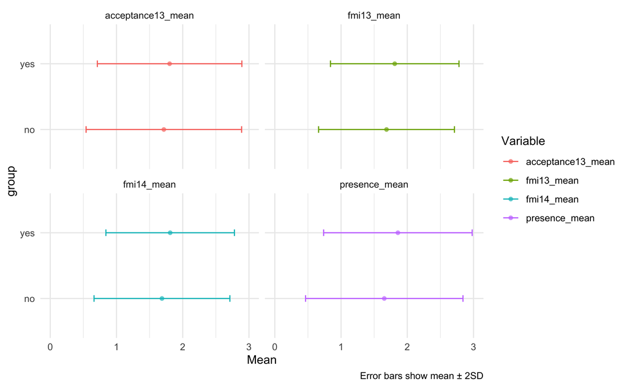

```r
plot_fmi_descriptives(data = d_w_items,
                      var = Achts_regel)
```

### 7.2.2 Norms

```r
for (i in unique(d_w_items$Achts_regel)) {
  cat("Group: ", i, "\n")
  d_w_items %>%
    filter(Achts_regel == i) %>%
    select(ends_with("_mean")) %>%
    map(~ knitr::kable(compute_all_norms(., min_score = 0, max_score = 3, by = .1),
                       digits = 2)) %>% print()
}
```

Group: no $fmi13_mean

| score | perc_rank | z | stanine | T | perc_normal |
| --- | --- | --- | --- | --- | --- |
| 0.0 | 0.00 | -3.29 | 1.00 | 17.11 | 0.00 |
| 0.1 | 0.00 | -3.09 | 1.00 | 19.06 | 0.00 |
| 0.2 | 0.00 | -2.90 | 1.00 | 21.01 | 0.00 |
| 0.3 | 0.01 | -2.70 | 1.00 | 22.96 | 0.00 |
| 0.4 | 0.01 | -2.51 | 1.00 | 24.91 | 0.01 |
| 0.5 | 0.02 | -2.31 | 1.00 | 26.86 | 0.01 |
| 0.6 | 0.03 | -2.12 | 1.00 | 28.81 | 0.02 |
| 0.7 | 0.03 | -1.92 | 1.15 | 30.76 | 0.03 |
| 0.8 | 0.05 | -1.73 | 1.54 | 32.71 | 0.04 |
| 0.9 | 0.06 | -1.53 | 1.93 | 34.66 | 0.06 |
| 1.0 | 0.10 | -1.34 | 2.32 | 36.61 | 0.09 |
| 1.1 | 0.13 | -1.14 | 2.71 | 38.56 | 0.13 |
| 1.2 | 0.17 | -0.95 | 3.10 | 40.51 | 0.17 |
| 1.3 | 0.23 | -0.75 | 3.49 | 42.46 | 0.23 |
| 1.4 | 0.27 | -0.56 | 3.88 | 44.41 | 0.29 |
| 1.5 | 0.36 | -0.36 | 4.27 | 46.36 | 0.36 |
| 1.6 | 0.42 | -0.17 | 4.66 | 48.31 | 0.43 |
| 1.7 | 0.48 | 0.03 | 5.05 | 50.26 | 0.51 |
| 1.8 | 0.60 | 0.22 | 5.44 | 52.21 | 0.59 |
| 1.9 | 0.65 | 0.42 | 5.83 | 54.16 | 0.66 |
| 2.0 | 0.78 | 0.61 | 6.22 | 56.11 | 0.73 |
| 2.1 | 0.81 | 0.81 | 6.61 | 58.06 | 0.79 |
| 2.2 | 0.84 | 1.00 | 7.00 | 60.01 | 0.84 |
| 2.3 | 0.90 | 1.20 | 7.39 | 61.97 | 0.88 |
| 2.4 | 0.91 | 1.39 | 7.78 | 63.92 | 0.92 |
| 2.5 | 0.95 | 1.59 | 8.17 | 65.87 | 0.94 |
| 2.6 | 0.97 | 1.78 | 8.56 | 67.82 | 0.96 |
| 2.7 | 0.97 | 1.98 | 8.95 | 69.77 | 0.98 |
| 2.8 | 0.99 | 2.17 | 9.00 | 71.72 | 0.99 |
| 2.9 | 0.99 | 2.37 | 9.00 | 73.67 | 0.99 |
| 3.0 | 1.00 | 2.56 | 9.00 | 75.62 | 0.99 |

$presence_mean

| score | perc_rank | z | stanine | T | perc_normal |
| --- | --- | --- | --- | --- | --- |
| 0.0 | 0.01 | -2.78 | 1.00 | 22.18 | 0.00 |
| 0.1 | 0.01 | -2.61 | 1.00 | 23.87 | 0.00 |
| 0.2 | 0.02 | -2.44 | 1.00 | 25.55 | 0.01 |
| 0.3 | 0.02 | -2.28 | 1.00 | 27.23 | 0.01 |
| 0.4 | 0.03 | -2.11 | 1.00 | 28.92 | 0.02 |
| 0.5 | 0.05 | -1.94 | 1.12 | 30.60 | 0.03 |
| 0.6 | 0.05 | -1.77 | 1.46 | 32.28 | 0.04 |
| 0.7 | 0.07 | -1.60 | 1.79 | 33.97 | 0.05 |
| 0.8 | 0.07 | -1.44 | 2.13 | 35.65 | 0.08 |
| 0.9 | 0.10 | -1.27 | 2.47 | 37.33 | 0.10 |
| 1.0 | 0.16 | -1.10 | 2.80 | 39.02 | 0.14 |
| 1.1 | 0.16 | -0.93 | 3.14 | 40.70 | 0.18 |
| 1.2 | 0.23 | -0.76 | 3.48 | 42.38 | 0.22 |
| 1.3 | 0.23 | -0.59 | 3.81 | 44.07 | 0.28 |
| 1.4 | 0.32 | -0.43 | 4.15 | 45.75 | 0.34 |
| 1.5 | 0.43 | -0.26 | 4.49 | 47.43 | 0.40 |
| 1.6 | 0.43 | -0.09 | 4.82 | 49.12 | 0.46 |
| 1.7 | 0.55 | 0.08 | 5.16 | 50.80 | 0.53 |
| 1.8 | 0.55 | 0.25 | 5.50 | 52.48 | 0.60 |
| 1.9 | 0.67 | 0.42 | 5.83 | 54.16 | 0.66 |
| 2.0 | 0.79 | 0.58 | 6.17 | 55.85 | 0.72 |
| 2.1 | 0.79 | 0.75 | 6.51 | 57.53 | 0.77 |
| 2.2 | 0.85 | 0.92 | 6.84 | 59.21 | 0.82 |
| 2.3 | 0.85 | 1.09 | 7.18 | 60.90 | 0.86 |
| 2.4 | 0.90 | 1.26 | 7.52 | 62.58 | 0.90 |
| 2.5 | 0.94 | 1.43 | 7.85 | 64.26 | 0.92 |
| 2.6 | 0.94 | 1.59 | 8.19 | 65.95 | 0.94 |
| 2.7 | 0.97 | 1.76 | 8.53 | 67.63 | 0.96 |
| 2.8 | 0.97 | 1.93 | 8.86 | 69.31 | 0.97 |
| 2.9 | 0.98 | 2.10 | 9.00 | 71.00 | 0.98 |
| 3.0 | 1.00 | 2.27 | 9.00 | 72.68 | 0.99 |

$acceptance13_mean

| score | perc_rank | z | stanine | T | perc_normal |
| --- | --- | --- | --- | --- | --- |
| 0.0 | 0.01 | -2.92 | 1.00 | 20.78 | 0.00 |
| 0.1 | 0.01 | -2.75 | 1.00 | 22.49 | 0.00 |
| 0.2 | 0.01 | -2.58 | 1.00 | 24.19 | 0.00 |
| 0.3 | 0.02 | -2.41 | 1.00 | 25.89 | 0.01 |
| 0.4 | 0.02 | -2.24 | 1.00 | 27.60 | 0.01 |
| 0.5 | 0.03 | -2.07 | 1.00 | 29.30 | 0.02 |
| 0.6 | 0.04 | -1.90 | 1.20 | 31.00 | 0.03 |
| 0.7 | 0.04 | -1.73 | 1.54 | 32.71 | 0.04 |
| 0.8 | 0.06 | -1.56 | 1.88 | 34.41 | 0.06 |
| 0.9 | 0.09 | -1.39 | 2.22 | 36.12 | 0.08 |
| 1.0 | 0.14 | -1.22 | 2.56 | 37.82 | 0.11 |
| 1.1 | 0.14 | -1.05 | 2.90 | 39.52 | 0.15 |
| 1.2 | 0.18 | -0.88 | 3.25 | 41.23 | 0.19 |
| 1.3 | 0.26 | -0.71 | 3.59 | 42.93 | 0.24 |
| 1.4 | 0.26 | -0.54 | 3.93 | 44.63 | 0.30 |
| 1.5 | 0.34 | -0.37 | 4.27 | 46.34 | 0.36 |
| 1.6 | 0.43 | -0.20 | 4.61 | 48.04 | 0.42 |
| 1.7 | 0.43 | -0.03 | 4.95 | 49.74 | 0.49 |
| 1.8 | 0.53 | 0.14 | 5.29 | 51.45 | 0.56 |
| 1.9 | 0.64 | 0.32 | 5.63 | 53.15 | 0.62 |
| 2.0 | 0.76 | 0.49 | 5.97 | 54.86 | 0.69 |
| 2.1 | 0.76 | 0.66 | 6.31 | 56.56 | 0.74 |
| 2.2 | 0.82 | 0.83 | 6.65 | 58.26 | 0.80 |
| 2.3 | 0.87 | 1.00 | 6.99 | 59.97 | 0.84 |
| 2.4 | 0.87 | 1.17 | 7.33 | 61.67 | 0.88 |
| 2.5 | 0.90 | 1.34 | 7.67 | 63.37 | 0.91 |
| 2.6 | 0.94 | 1.51 | 8.02 | 65.08 | 0.93 |
| 2.7 | 0.94 | 1.68 | 8.36 | 66.78 | 0.95 |
| 2.8 | 0.96 | 1.85 | 8.70 | 68.48 | 0.97 |
| 2.9 | 0.98 | 2.02 | 9.00 | 70.19 | 0.98 |
| 3.0 | 1.00 | 2.19 | 9.00 | 71.89 | 0.99 |

$fmi14_mean

| score | perc_rank | z | stanine | T | perc_normal |
| --- | --- | --- | --- | --- | --- |
| 0.0 | 0.00 | -3.29 | 1.00 | 17.11 | 0.00 |
| 0.1 | 0.00 | -3.09 | 1.00 | 19.06 | 0.00 |
| 0.2 | 0.00 | -2.90 | 1.00 | 21.01 | 0.00 |
| 0.3 | 0.01 | -2.70 | 1.00 | 22.96 | 0.00 |
| 0.4 | 0.01 | -2.51 | 1.00 | 24.91 | 0.01 |
| 0.5 | 0.02 | -2.31 | 1.00 | 26.86 | 0.01 |
| 0.6 | 0.03 | -2.12 | 1.00 | 28.81 | 0.02 |
| 0.7 | 0.03 | -1.92 | 1.15 | 30.76 | 0.03 |
| 0.8 | 0.05 | -1.73 | 1.54 | 32.71 | 0.04 |
| 0.9 | 0.06 | -1.53 | 1.93 | 34.66 | 0.06 |
| 1.0 | 0.10 | -1.34 | 2.32 | 36.61 | 0.09 |
| 1.1 | 0.13 | -1.14 | 2.71 | 38.56 | 0.13 |
| 1.2 | 0.17 | -0.95 | 3.10 | 40.51 | 0.17 |
| 1.3 | 0.23 | -0.75 | 3.49 | 42.46 | 0.23 |
| 1.4 | 0.27 | -0.56 | 3.88 | 44.41 | 0.29 |
| 1.5 | 0.36 | -0.36 | 4.27 | 46.36 | 0.36 |
| 1.6 | 0.42 | -0.17 | 4.66 | 48.31 | 0.43 |
| 1.7 | 0.48 | 0.03 | 5.05 | 50.26 | 0.51 |
| 1.8 | 0.60 | 0.22 | 5.44 | 52.21 | 0.59 |
| 1.9 | 0.65 | 0.42 | 5.83 | 54.16 | 0.66 |
| 2.0 | 0.78 | 0.61 | 6.22 | 56.11 | 0.73 |
| 2.1 | 0.81 | 0.81 | 6.61 | 58.06 | 0.79 |
| 2.2 | 0.84 | 1.00 | 7.00 | 60.01 | 0.84 |
| 2.3 | 0.90 | 1.20 | 7.39 | 61.97 | 0.88 |
| 2.4 | 0.91 | 1.39 | 7.78 | 63.92 | 0.92 |
| 2.5 | 0.95 | 1.59 | 8.17 | 65.87 | 0.94 |
| 2.6 | 0.97 | 1.78 | 8.56 | 67.82 | 0.96 |
| 2.7 | 0.97 | 1.98 | 8.95 | 69.77 | 0.98 |
| 2.8 | 0.99 | 2.17 | 9.00 | 71.72 | 0.99 |
| 2.9 | 0.99 | 2.37 | 9.00 | 73.67 | 0.99 |
| 3.0 | 1.00 | 2.56 | 9.00 | 75.62 | 0.99 |

Group: yes $fmi13_mean

| score | perc_rank | z | stanine | T | perc_normal |
| --- | --- | --- | --- | --- | --- |
| 0.0 | 0.00 | -3.73 | 1.00 | 12.68 | 0.00 |
| 0.1 | 0.00 | -3.53 | 1.00 | 14.74 | 0.00 |
| 0.2 | 0.00 | -3.32 | 1.00 | 16.80 | 0.00 |
| 0.3 | 0.01 | -3.11 | 1.00 | 18.86 | 0.00 |
| 0.4 | 0.01 | -2.91 | 1.00 | 20.92 | 0.00 |
| 0.5 | 0.01 | -2.70 | 1.00 | 22.99 | 0.00 |
| 0.6 | 0.01 | -2.50 | 1.00 | 25.05 | 0.01 |
| 0.7 | 0.01 | -2.29 | 1.00 | 27.11 | 0.01 |
| 0.8 | 0.02 | -2.08 | 1.00 | 29.17 | 0.02 |
| 0.9 | 0.02 | -1.88 | 1.25 | 31.23 | 0.03 |
| 1.0 | 0.06 | -1.67 | 1.66 | 33.29 | 0.05 |
| 1.1 | 0.08 | -1.46 | 2.07 | 35.35 | 0.07 |
| 1.2 | 0.09 | -1.26 | 2.48 | 37.42 | 0.10 |
| 1.3 | 0.14 | -1.05 | 2.90 | 39.48 | 0.15 |
| 1.4 | 0.19 | -0.85 | 3.31 | 41.54 | 0.20 |
| 1.5 | 0.27 | -0.64 | 3.72 | 43.60 | 0.26 |
| 1.6 | 0.32 | -0.43 | 4.13 | 45.66 | 0.33 |
| 1.7 | 0.37 | -0.23 | 4.54 | 47.72 | 0.41 |
| 1.8 | 0.51 | -0.02 | 4.96 | 49.79 | 0.49 |
| 1.9 | 0.57 | 0.18 | 5.37 | 51.85 | 0.57 |
| 2.0 | 0.70 | 0.39 | 5.78 | 53.91 | 0.65 |
| 2.1 | 0.77 | 0.60 | 6.19 | 55.97 | 0.72 |
| 2.2 | 0.81 | 0.80 | 6.61 | 58.03 | 0.79 |
| 2.3 | 0.87 | 1.01 | 7.02 | 60.09 | 0.84 |
| 2.4 | 0.90 | 1.22 | 7.43 | 62.16 | 0.89 |
| 2.5 | 0.92 | 1.42 | 7.84 | 64.22 | 0.92 |
| 2.6 | 0.94 | 1.63 | 8.26 | 66.28 | 0.95 |
| 2.7 | 0.95 | 1.83 | 8.67 | 68.34 | 0.97 |
| 2.8 | 0.97 | 2.04 | 9.00 | 70.40 | 0.98 |
| 2.9 | 0.98 | 2.25 | 9.00 | 72.46 | 0.99 |
| 3.0 | 1.00 | 2.45 | 9.00 | 74.52 | 0.99 |

$presence_mean

| score | perc_rank | z | stanine | T | perc_normal |
| --- | --- | --- | --- | --- | --- |
| 0.0 | 0.01 | -3.31 | 1.00 | 16.85 | 0.00 |
| 0.1 | 0.01 | -3.14 | 1.00 | 18.64 | 0.00 |
| 0.2 | 0.01 | -2.96 | 1.00 | 20.42 | 0.00 |
| 0.3 | 0.01 | -2.78 | 1.00 | 22.20 | 0.00 |
| 0.4 | 0.01 | -2.60 | 1.00 | 23.99 | 0.00 |
| 0.5 | 0.01 | -2.42 | 1.00 | 25.77 | 0.01 |
| 0.6 | 0.01 | -2.24 | 1.00 | 27.56 | 0.01 |
| 0.7 | 0.02 | -2.07 | 1.00 | 29.34 | 0.02 |
| 0.8 | 0.02 | -1.89 | 1.22 | 31.12 | 0.03 |
| 0.9 | 0.05 | -1.71 | 1.58 | 32.91 | 0.04 |
| 1.0 | 0.09 | -1.53 | 1.94 | 34.69 | 0.06 |
| 1.1 | 0.09 | -1.35 | 2.29 | 36.47 | 0.09 |
| 1.2 | 0.12 | -1.17 | 2.65 | 38.26 | 0.12 |
| 1.3 | 0.12 | -1.00 | 3.01 | 40.04 | 0.16 |
| 1.4 | 0.20 | -0.82 | 3.36 | 41.82 | 0.21 |
| 1.5 | 0.29 | -0.64 | 3.72 | 43.61 | 0.26 |
| 1.6 | 0.29 | -0.46 | 4.08 | 45.39 | 0.32 |
| 1.7 | 0.40 | -0.28 | 4.44 | 47.18 | 0.39 |
| 1.8 | 0.40 | -0.10 | 4.79 | 48.96 | 0.46 |
| 1.9 | 0.53 | 0.07 | 5.15 | 50.74 | 0.53 |
| 2.0 | 0.69 | 0.25 | 5.51 | 52.53 | 0.60 |
| 2.1 | 0.69 | 0.43 | 5.86 | 54.31 | 0.67 |
| 2.2 | 0.79 | 0.61 | 6.22 | 56.09 | 0.73 |
| 2.3 | 0.79 | 0.79 | 6.58 | 57.88 | 0.78 |
| 2.4 | 0.85 | 0.97 | 6.93 | 59.66 | 0.83 |
| 2.5 | 0.90 | 1.14 | 7.29 | 61.45 | 0.87 |
| 2.6 | 0.90 | 1.32 | 7.65 | 63.23 | 0.91 |
| 2.7 | 0.92 | 1.50 | 8.00 | 65.01 | 0.93 |
| 2.8 | 0.92 | 1.68 | 8.36 | 66.80 | 0.95 |
| 2.9 | 0.96 | 1.86 | 8.72 | 68.58 | 0.97 |
| 3.0 | 1.00 | 2.04 | 9.00 | 70.36 | 0.98 |

$acceptance13_mean

| score | perc_rank | z | stanine | T | perc_normal |
| --- | --- | --- | --- | --- | --- |
| 0.0 | 0.00 | -3.30 | 1.00 | 16.96 | 0.00 |
| 0.1 | 0.00 | -3.12 | 1.00 | 18.80 | 0.00 |
| 0.2 | 0.01 | -2.94 | 1.00 | 20.63 | 0.00 |
| 0.3 | 0.01 | -2.75 | 1.00 | 22.46 | 0.00 |
| 0.4 | 0.01 | -2.57 | 1.00 | 24.30 | 0.01 |
| 0.5 | 0.02 | -2.39 | 1.00 | 26.13 | 0.01 |
| 0.6 | 0.02 | -2.20 | 1.00 | 27.96 | 0.01 |
| 0.7 | 0.02 | -2.02 | 1.00 | 29.80 | 0.02 |
| 0.8 | 0.03 | -1.84 | 1.33 | 31.63 | 0.03 |
| 0.9 | 0.05 | -1.65 | 1.69 | 33.46 | 0.05 |
| 1.0 | 0.09 | -1.47 | 2.06 | 35.30 | 0.07 |
| 1.1 | 0.09 | -1.29 | 2.43 | 37.13 | 0.10 |
| 1.2 | 0.12 | -1.10 | 2.79 | 38.96 | 0.13 |
| 1.3 | 0.18 | -0.92 | 3.16 | 40.80 | 0.18 |
| 1.4 | 0.18 | -0.74 | 3.53 | 42.63 | 0.23 |
| 1.5 | 0.27 | -0.55 | 3.89 | 44.46 | 0.29 |
| 1.6 | 0.38 | -0.37 | 4.26 | 46.30 | 0.36 |
| 1.7 | 0.38 | -0.19 | 4.63 | 48.13 | 0.43 |
| 1.8 | 0.45 | 0.00 | 4.99 | 49.96 | 0.50 |
| 1.9 | 0.59 | 0.18 | 5.36 | 51.80 | 0.57 |
| 2.0 | 0.73 | 0.36 | 5.73 | 53.63 | 0.64 |
| 2.1 | 0.73 | 0.55 | 6.09 | 55.46 | 0.71 |
| 2.2 | 0.83 | 0.73 | 6.46 | 57.30 | 0.77 |
| 2.3 | 0.86 | 0.91 | 6.83 | 59.13 | 0.82 |
| 2.4 | 0.86 | 1.10 | 7.19 | 60.97 | 0.86 |
| 2.5 | 0.90 | 1.28 | 7.56 | 62.80 | 0.90 |
| 2.6 | 0.92 | 1.46 | 7.93 | 64.63 | 0.93 |
| 2.7 | 0.92 | 1.65 | 8.29 | 66.47 | 0.95 |
| 2.8 | 0.95 | 1.83 | 8.66 | 68.30 | 0.97 |
| 2.9 | 0.97 | 2.01 | 9.00 | 70.13 | 0.98 |
| 3.0 | 1.00 | 2.20 | 9.00 | 71.97 | 0.99 |

$fmi14_mean

| score | perc_rank | z | stanine | T | perc_normal |
| --- | --- | --- | --- | --- | --- |
| 0.0 | 0.00 | -3.73 | 1.00 | 12.68 | 0.00 |
| 0.1 | 0.00 | -3.53 | 1.00 | 14.74 | 0.00 |
| 0.2 | 0.00 | -3.32 | 1.00 | 16.80 | 0.00 |
| 0.3 | 0.01 | -3.11 | 1.00 | 18.86 | 0.00 |
| 0.4 | 0.01 | -2.91 | 1.00 | 20.92 | 0.00 |
| 0.5 | 0.01 | -2.70 | 1.00 | 22.99 | 0.00 |
| 0.6 | 0.01 | -2.50 | 1.00 | 25.05 | 0.01 |
| 0.7 | 0.01 | -2.29 | 1.00 | 27.11 | 0.01 |
| 0.8 | 0.02 | -2.08 | 1.00 | 29.17 | 0.02 |
| 0.9 | 0.02 | -1.88 | 1.25 | 31.23 | 0.03 |
| 1.0 | 0.06 | -1.67 | 1.66 | 33.29 | 0.05 |
| 1.1 | 0.08 | -1.46 | 2.07 | 35.35 | 0.07 |
| 1.2 | 0.09 | -1.26 | 2.48 | 37.42 | 0.10 |
| 1.3 | 0.14 | -1.05 | 2.90 | 39.48 | 0.15 |
| 1.4 | 0.19 | -0.85 | 3.31 | 41.54 | 0.20 |
| 1.5 | 0.27 | -0.64 | 3.72 | 43.60 | 0.26 |
| 1.6 | 0.32 | -0.43 | 4.13 | 45.66 | 0.33 |
| 1.7 | 0.37 | -0.23 | 4.54 | 47.72 | 0.41 |
| 1.8 | 0.51 | -0.02 | 4.96 | 49.79 | 0.49 |
| 1.9 | 0.57 | 0.18 | 5.37 | 51.85 | 0.57 |
| 2.0 | 0.70 | 0.39 | 5.78 | 53.91 | 0.65 |
| 2.1 | 0.77 | 0.60 | 6.19 | 55.97 | 0.72 |
| 2.2 | 0.81 | 0.80 | 6.61 | 58.03 | 0.79 |
| 2.3 | 0.87 | 1.01 | 7.02 | 60.09 | 0.84 |
| 2.4 | 0.90 | 1.22 | 7.43 | 62.16 | 0.89 |
| 2.5 | 0.92 | 1.42 | 7.84 | 64.22 | 0.92 |
| 2.6 | 0.94 | 1.63 | 8.26 | 66.28 | 0.95 |
| 2.7 | 0.95 | 1.83 | 8.67 | 68.34 | 0.97 |
| 2.8 | 0.97 | 2.04 | 9.00 | 70.40 | 0.98 |
| 2.9 | 0.98 | 2.25 | 9.00 | 72.46 | 0.99 |
| 3.0 | 1.00 | 2.45 | 9.00 | 74.52 | 0.99 |

## 7.3 Split by retreats

### 7.3.1 Stats

```r
describe_fmi_stats(data = d_w_items,
                   var = Retreats)
```

Retreats=Multiple retreats per year

| Variable | Mean | Mean_01 | SD | Range | Quartiles | Skewness | Kurtosis | n | n_Missing |
| --- | --- | --- | --- | --- | --- | --- | --- | --- | --- |
| acceptance13_mean | 1.81 | 0.60 | 0.48 | (0.71, 3.00) | 1.57, 2.04 | -0.03 | -0.06 | 116 | 0 |
| fmi13_mean | 1.82 | 0.61 | 0.43 | (0.71, 3.00) | 1.57, 2.00 | 0.03 | 0.32 | 116 | 0 |
| fmi14_mean | 1.82 | 0.61 | 0.43 | (0.71, 3.00) | 1.57, 2.00 | 0.03 | 0.32 | 116 | 0 |
| presence_mean | 1.84 | 0.61 | 0.50 | (0.33, 3.00) | 1.50, 2.04 | -0.15 | 0.28 | 116 | 0 |

Retreats=Never

| Variable | Mean | Mean_01 | SD | Range | Quartiles | Skewness | Kurtosis | n | n_Missing |
| --- | --- | --- | --- | --- | --- | --- | --- | --- | --- |
| acceptance13_mean | 1.70 | 0.57 | 0.60 | (0.00, 3.00) | 1.29, 2.00 | -0.27 | 0.21 | 673 | 0 |
| fmi13_mean | 1.68 | 0.56 | 0.52 | (0.21, 3.00) | 1.36, 2.00 | -0.18 | 0.10 | 673 | 0 |
| fmi14_mean | 1.68 | 0.56 | 0.52 | (0.21, 3.00) | 1.36, 2.00 | -0.18 | 0.10 | 673 | 0 |
| presence_mean | 1.64 | 0.55 | 0.59 | (0.00, 3.00) | 1.33, 2.00 | -0.28 | 0.20 | 673 | 0 |

Retreats=Once a year

| Variable | Mean | Mean_01 | SD | Range | Quartiles | Skewness | Kurtosis | n | n_Missing |
| --- | --- | --- | --- | --- | --- | --- | --- | --- | --- |
| acceptance13_mean | 1.73 | 0.58 | 0.50 | (0.71, 3.00) | 1.43, 2.00 | 0.59 | 0.46 | 58 | 0 |
| fmi13_mean | 1.71 | 0.57 | 0.45 | (0.57, 2.93) | 1.43, 1.98 | 0.30 | 0.36 | 58 | 0 |
| fmi14_mean | 1.71 | 0.57 | 0.45 | (0.57, 2.93) | 1.43, 1.98 | 0.30 | 0.36 | 58 | 0 |
| presence_mean | 1.68 | 0.56 | 0.55 | (0.17, 3.00) | 1.33, 2.00 | 0.04 | 0.25 | 58 | 0 |

Retreats=Once every couple of years

| Variable | Mean | Mean_01 | SD | Range | Quartiles | Skewness | Kurtosis | n | n_Missing |
| --- | --- | --- | --- | --- | --- | --- | --- | --- | --- |
| acceptance13_mean | 1.74 | 0.58 | 0.53 | (0.29, 3.00) | 1.43, 2.11 | 0.14 | 0.12 | 86 | 0 |
| fmi13_mean | 1.71 | 0.57 | 0.46 | (0.93, 2.93) | 1.36, 2.07 | 0.38 | -0.32 | 86 | 0 |
| fmi14_mean | 1.71 | 0.57 | 0.46 | (0.93, 2.93) | 1.36, 2.07 | 0.38 | -0.32 | 86 | 0 |
| presence_mean | 1.71 | 0.57 | 0.59 | (0.67, 3.00) | 1.33, 2.17 | 0.20 | -0.44 | 86 | 0 |

Retreats=Rarely

| Variable | Mean | Mean_01 | SD | Range | Quartiles | Skewness | Kurtosis | n | n_Missing |
| --- | --- | --- | --- | --- | --- | --- | --- | --- | --- |
| acceptance13_mean | 1.93 | 0.64 | 0.63 | (0.14, 3.00) | 1.57, 2.29 | -0.38 | 0.35 | 79 | 0 |
| fmi13_mean | 1.89 | 0.63 | 0.55 | (0.29, 2.79) | 1.57, 2.29 | -0.51 | 0.60 | 79 | 0 |
| fmi14_mean | 1.89 | 0.63 | 0.55 | (0.29, 2.79) | 1.57, 2.29 | -0.51 | 0.60 | 79 | 0 |
| presence_mean | 1.94 | 0.65 | 0.68 | (0.00, 3.00) | 1.50, 2.33 | -0.60 | 0.63 | 79 | 0 |

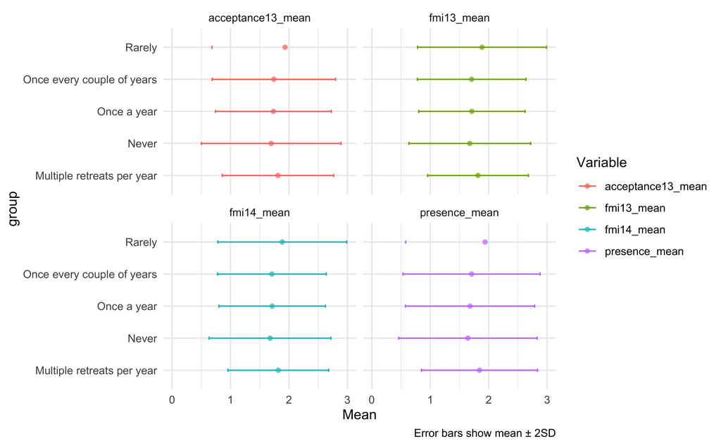

```r
plot_fmi_descriptives(data = d_w_items,
                      var = Retreats)
```

### 7.3.2 Norms

```r
for (i in unique(d_w_items$Retreats)) {
  cat("Group: ", i, "\n")
  d_w_items %>%
    filter(Retreats == i) %>%
    select(ends_with("_mean")) %>%
    map(~ knitr::kable(compute_all_norms(., min_score = 0, max_score = 3, by = .1),
                       digits = 2)) %>%
    print()
}
```

Group: Never $fmi13_mean

| score | perc_rank | z | stanine | T | perc_normal |
| --- | --- | --- | --- | --- | --- |
| 0.0 | 0.00 | -3.22 | 1.00 | 17.82 | 0.00 |
| 0.1 | 0.00 | -3.03 | 1.00 | 19.74 | 0.00 |
| 0.2 | 0.00 | -2.83 | 1.00 | 21.66 | 0.00 |
| 0.3 | 0.01 | -2.64 | 1.00 | 23.58 | 0.00 |
| 0.4 | 0.01 | -2.45 | 1.00 | 25.50 | 0.01 |
| 0.5 | 0.02 | -2.26 | 1.00 | 27.42 | 0.01 |
| 0.6 | 0.03 | -2.07 | 1.00 | 29.34 | 0.02 |
| 0.7 | 0.04 | -1.87 | 1.25 | 31.26 | 0.03 |
| 0.8 | 0.06 | -1.68 | 1.64 | 33.18 | 0.05 |
| 0.9 | 0.07 | -1.49 | 2.02 | 35.10 | 0.07 |
| 1.0 | 0.11 | -1.30 | 2.40 | 37.02 | 0.10 |
| 1.1 | 0.14 | -1.11 | 2.79 | 38.94 | 0.13 |
| 1.2 | 0.17 | -0.91 | 3.17 | 40.86 | 0.18 |
| 1.3 | 0.24 | -0.72 | 3.56 | 42.78 | 0.24 |
| 1.4 | 0.29 | -0.53 | 3.94 | 44.70 | 0.30 |
| 1.5 | 0.36 | -0.34 | 4.32 | 46.62 | 0.37 |
| 1.6 | 0.41 | -0.15 | 4.71 | 48.54 | 0.44 |
| 1.7 | 0.47 | 0.05 | 5.09 | 50.46 | 0.52 |
| 1.8 | 0.60 | 0.24 | 5.47 | 52.37 | 0.59 |
| 1.9 | 0.66 | 0.43 | 5.86 | 54.29 | 0.67 |
| 2.0 | 0.77 | 0.62 | 6.24 | 56.21 | 0.73 |
| 2.1 | 0.81 | 0.81 | 6.63 | 58.13 | 0.79 |
| 2.2 | 0.85 | 1.01 | 7.01 | 60.05 | 0.84 |
| 2.3 | 0.90 | 1.20 | 7.39 | 61.97 | 0.88 |
| 2.4 | 0.92 | 1.39 | 7.78 | 63.89 | 0.92 |
| 2.5 | 0.95 | 1.58 | 8.16 | 65.81 | 0.94 |
| 2.6 | 0.97 | 1.77 | 8.55 | 67.73 | 0.96 |
| 2.7 | 0.97 | 1.97 | 8.93 | 69.65 | 0.98 |
| 2.8 | 0.99 | 2.16 | 9.00 | 71.57 | 0.98 |
| 2.9 | 0.99 | 2.35 | 9.00 | 73.49 | 0.99 |
| 3.0 | 1.00 | 2.54 | 9.00 | 75.41 | 0.99 |

$presence_mean

| score | perc_rank | z | stanine | T | perc_normal |
| --- | --- | --- | --- | --- | --- |
| 0.0 | 0.01 | -2.78 | 1.00 | 22.23 | 0.00 |
| 0.1 | 0.01 | -2.61 | 1.00 | 23.91 | 0.00 |
| 0.2 | 0.02 | -2.44 | 1.00 | 25.60 | 0.01 |
| 0.3 | 0.02 | -2.27 | 1.00 | 27.29 | 0.01 |
| 0.4 | 0.03 | -2.10 | 1.00 | 28.98 | 0.02 |
| 0.5 | 0.05 | -1.93 | 1.13 | 30.67 | 0.03 |
| 0.6 | 0.05 | -1.76 | 1.47 | 32.36 | 0.04 |
| 0.7 | 0.08 | -1.60 | 1.81 | 34.05 | 0.06 |
| 0.8 | 0.08 | -1.43 | 2.15 | 35.74 | 0.08 |
| 0.9 | 0.11 | -1.26 | 2.49 | 37.43 | 0.10 |
| 1.0 | 0.16 | -1.09 | 2.82 | 39.12 | 0.14 |
| 1.1 | 0.16 | -0.92 | 3.16 | 40.81 | 0.18 |
| 1.2 | 0.23 | -0.75 | 3.50 | 42.49 | 0.23 |
| 1.3 | 0.23 | -0.58 | 3.84 | 44.18 | 0.28 |
| 1.4 | 0.32 | -0.41 | 4.17 | 45.87 | 0.34 |
| 1.5 | 0.42 | -0.24 | 4.51 | 47.56 | 0.40 |
| 1.6 | 0.42 | -0.07 | 4.85 | 49.25 | 0.47 |
| 1.7 | 0.55 | 0.09 | 5.19 | 50.94 | 0.54 |
| 1.8 | 0.55 | 0.26 | 5.53 | 52.63 | 0.60 |
| 1.9 | 0.68 | 0.43 | 5.86 | 54.32 | 0.67 |
| 2.0 | 0.80 | 0.60 | 6.20 | 56.01 | 0.73 |
| 2.1 | 0.80 | 0.77 | 6.54 | 57.70 | 0.78 |
| 2.2 | 0.86 | 0.94 | 6.88 | 59.38 | 0.83 |
| 2.3 | 0.86 | 1.11 | 7.21 | 61.07 | 0.87 |
| 2.4 | 0.91 | 1.28 | 7.55 | 62.76 | 0.90 |
| 2.5 | 0.95 | 1.45 | 7.89 | 64.45 | 0.93 |
| 2.6 | 0.95 | 1.61 | 8.23 | 66.14 | 0.95 |
| 2.7 | 0.97 | 1.78 | 8.57 | 67.83 | 0.96 |
| 2.8 | 0.97 | 1.95 | 8.90 | 69.52 | 0.97 |
| 2.9 | 0.98 | 2.12 | 9.00 | 71.21 | 0.98 |
| 3.0 | 1.00 | 2.29 | 9.00 | 72.90 | 0.99 |

$acceptance13_mean

| score | perc_rank | z | stanine | T | perc_normal |
| --- | --- | --- | --- | --- | --- |
| 0.0 | 0.01 | -2.84 | 1.00 | 21.61 | 0.00 |
| 0.1 | 0.01 | -2.67 | 1.00 | 23.29 | 0.00 |
| 0.2 | 0.02 | -2.50 | 1.00 | 24.96 | 0.01 |
| 0.3 | 0.02 | -2.34 | 1.00 | 26.63 | 0.01 |
| 0.4 | 0.02 | -2.17 | 1.00 | 28.31 | 0.02 |
| 0.5 | 0.03 | -2.00 | 1.00 | 29.98 | 0.02 |
| 0.6 | 0.05 | -1.83 | 1.33 | 31.65 | 0.03 |
| 0.7 | 0.05 | -1.67 | 1.67 | 33.33 | 0.05 |
| 0.8 | 0.07 | -1.50 | 2.00 | 35.00 | 0.07 |
| 0.9 | 0.10 | -1.33 | 2.33 | 36.67 | 0.09 |
| 1.0 | 0.15 | -1.17 | 2.67 | 38.35 | 0.12 |
| 1.1 | 0.15 | -1.00 | 3.00 | 40.02 | 0.16 |
| 1.2 | 0.20 | -0.83 | 3.34 | 41.69 | 0.20 |
| 1.3 | 0.27 | -0.66 | 3.67 | 43.37 | 0.25 |
| 1.4 | 0.27 | -0.50 | 4.01 | 45.04 | 0.31 |
| 1.5 | 0.35 | -0.33 | 4.34 | 46.72 | 0.37 |
| 1.6 | 0.43 | -0.16 | 4.68 | 48.39 | 0.44 |
| 1.7 | 0.43 | 0.01 | 5.01 | 50.06 | 0.50 |
| 1.8 | 0.53 | 0.17 | 5.35 | 51.74 | 0.57 |
| 1.9 | 0.64 | 0.34 | 5.68 | 53.41 | 0.63 |
| 2.0 | 0.76 | 0.51 | 6.02 | 55.08 | 0.69 |
| 2.1 | 0.76 | 0.68 | 6.35 | 56.76 | 0.75 |
| 2.2 | 0.83 | 0.84 | 6.69 | 58.43 | 0.80 |
| 2.3 | 0.87 | 1.01 | 7.02 | 60.10 | 0.84 |
| 2.4 | 0.87 | 1.18 | 7.36 | 61.78 | 0.88 |
| 2.5 | 0.91 | 1.35 | 7.69 | 63.45 | 0.91 |
| 2.6 | 0.95 | 1.51 | 8.03 | 65.13 | 0.93 |
| 2.7 | 0.95 | 1.68 | 8.36 | 66.80 | 0.95 |
| 2.8 | 0.96 | 1.85 | 8.69 | 68.47 | 0.97 |
| 2.9 | 0.98 | 2.01 | 9.00 | 70.15 | 0.98 |
| 3.0 | 1.00 | 2.18 | 9.00 | 71.82 | 0.99 |

$fmi14_mean

| score | perc_rank | z | stanine | T | perc_normal |
| --- | --- | --- | --- | --- | --- |
| 0.0 | 0.00 | -3.22 | 1.00 | 17.82 | 0.00 |
| 0.1 | 0.00 | -3.03 | 1.00 | 19.74 | 0.00 |
| 0.2 | 0.00 | -2.83 | 1.00 | 21.66 | 0.00 |
| 0.3 | 0.01 | -2.64 | 1.00 | 23.58 | 0.00 |
| 0.4 | 0.01 | -2.45 | 1.00 | 25.50 | 0.01 |
| 0.5 | 0.02 | -2.26 | 1.00 | 27.42 | 0.01 |
| 0.6 | 0.03 | -2.07 | 1.00 | 29.34 | 0.02 |
| 0.7 | 0.04 | -1.87 | 1.25 | 31.26 | 0.03 |
| 0.8 | 0.06 | -1.68 | 1.64 | 33.18 | 0.05 |
| 0.9 | 0.07 | -1.49 | 2.02 | 35.10 | 0.07 |
| 1.0 | 0.11 | -1.30 | 2.40 | 37.02 | 0.10 |
| 1.1 | 0.14 | -1.11 | 2.79 | 38.94 | 0.13 |
| 1.2 | 0.17 | -0.91 | 3.17 | 40.86 | 0.18 |
| 1.3 | 0.24 | -0.72 | 3.56 | 42.78 | 0.24 |
| 1.4 | 0.29 | -0.53 | 3.94 | 44.70 | 0.30 |
| 1.5 | 0.36 | -0.34 | 4.32 | 46.62 | 0.37 |
| 1.6 | 0.41 | -0.15 | 4.71 | 48.54 | 0.44 |
| 1.7 | 0.47 | 0.05 | 5.09 | 50.46 | 0.52 |
| 1.8 | 0.60 | 0.24 | 5.47 | 52.37 | 0.59 |
| 1.9 | 0.66 | 0.43 | 5.86 | 54.29 | 0.67 |
| 2.0 | 0.77 | 0.62 | 6.24 | 56.21 | 0.73 |
| 2.1 | 0.81 | 0.81 | 6.63 | 58.13 | 0.79 |
| 2.2 | 0.85 | 1.01 | 7.01 | 60.05 | 0.84 |
| 2.3 | 0.90 | 1.20 | 7.39 | 61.97 | 0.88 |
| 2.4 | 0.92 | 1.39 | 7.78 | 63.89 | 0.92 |
| 2.5 | 0.95 | 1.58 | 8.16 | 65.81 | 0.94 |
| 2.6 | 0.97 | 1.77 | 8.55 | 67.73 | 0.96 |
| 2.7 | 0.97 | 1.97 | 8.93 | 69.65 | 0.98 |
| 2.8 | 0.99 | 2.16 | 9.00 | 71.57 | 0.98 |
| 2.9 | 0.99 | 2.35 | 9.00 | 73.49 | 0.99 |
| 3.0 | 1.00 | 2.54 | 9.00 | 75.41 | 0.99 |

Group: Once every couple of years $fmi13_mean

| score | perc_rank | z | stanine | T | perc_normal |
| --- | --- | --- | --- | --- | --- |
| 0.0 | 0.00 | -3.67 | 1.00 | 13.26 | 0.00 |
| 0.1 | 0.00 | -3.46 | 1.00 | 15.41 | 0.00 |
| 0.2 | 0.00 | -3.24 | 1.00 | 17.56 | 0.00 |
| 0.3 | 0.00 | -3.03 | 1.00 | 19.72 | 0.00 |
| 0.4 | 0.00 | -2.81 | 1.00 | 21.87 | 0.00 |
| 0.5 | 0.00 | -2.60 | 1.00 | 24.02 | 0.00 |
| 0.6 | 0.00 | -2.38 | 1.00 | 26.17 | 0.01 |
| 0.7 | 0.00 | -2.17 | 1.00 | 28.32 | 0.02 |
| 0.8 | 0.00 | -1.95 | 1.09 | 30.47 | 0.03 |
| 0.9 | 0.00 | -1.74 | 1.52 | 32.62 | 0.04 |
| 1.0 | 0.07 | -1.52 | 1.96 | 34.78 | 0.06 |
| 1.1 | 0.09 | -1.31 | 2.39 | 36.93 | 0.10 |
| 1.2 | 0.14 | -1.09 | 2.82 | 39.08 | 0.14 |
| 1.3 | 0.23 | -0.88 | 3.25 | 41.23 | 0.19 |
| 1.4 | 0.28 | -0.66 | 3.68 | 43.38 | 0.25 |
| 1.5 | 0.37 | -0.45 | 4.11 | 45.53 | 0.33 |
| 1.6 | 0.48 | -0.23 | 4.54 | 47.68 | 0.41 |
| 1.7 | 0.51 | -0.02 | 4.97 | 49.84 | 0.49 |
| 1.8 | 0.60 | 0.20 | 5.40 | 51.99 | 0.58 |
| 1.9 | 0.63 | 0.41 | 5.83 | 54.14 | 0.66 |
| 2.0 | 0.73 | 0.63 | 6.26 | 56.29 | 0.74 |
| 2.1 | 0.80 | 0.84 | 6.69 | 58.44 | 0.80 |
| 2.2 | 0.87 | 1.06 | 7.12 | 60.59 | 0.86 |
| 2.3 | 0.92 | 1.27 | 7.55 | 62.74 | 0.90 |
| 2.4 | 0.92 | 1.49 | 7.98 | 64.90 | 0.93 |
| 2.5 | 0.95 | 1.70 | 8.41 | 67.05 | 0.96 |
| 2.6 | 0.97 | 1.92 | 8.84 | 69.20 | 0.97 |
| 2.7 | 0.97 | 2.14 | 9.00 | 71.35 | 0.98 |
| 2.8 | 0.99 | 2.35 | 9.00 | 73.50 | 0.99 |
| 2.9 | 0.99 | 2.57 | 9.00 | 75.65 | 0.99 |
| 3.0 | 1.00 | 2.78 | 9.00 | 77.80 | 1.00 |

$presence_mean

| score | perc_rank | z | stanine | T | perc_normal |
| --- | --- | --- | --- | --- | --- |
| 0.0 | 0.00 | -2.91 | 1.00 | 20.88 | 0.00 |
| 0.1 | 0.00 | -2.74 | 1.00 | 22.58 | 0.00 |
| 0.2 | 0.00 | -2.57 | 1.00 | 24.29 | 0.01 |
| 0.3 | 0.00 | -2.40 | 1.00 | 26.00 | 0.01 |
| 0.4 | 0.00 | -2.23 | 1.00 | 27.70 | 0.01 |
| 0.5 | 0.00 | -2.06 | 1.00 | 29.41 | 0.02 |
| 0.6 | 0.00 | -1.89 | 1.22 | 31.11 | 0.03 |
| 0.7 | 0.05 | -1.72 | 1.56 | 32.82 | 0.04 |
| 0.8 | 0.05 | -1.55 | 1.90 | 34.52 | 0.06 |
| 0.9 | 0.10 | -1.38 | 2.25 | 36.23 | 0.08 |
| 1.0 | 0.17 | -1.21 | 2.59 | 37.94 | 0.11 |
| 1.1 | 0.17 | -1.04 | 2.93 | 39.64 | 0.15 |
| 1.2 | 0.22 | -0.87 | 3.27 | 41.35 | 0.19 |
| 1.3 | 0.22 | -0.69 | 3.61 | 43.05 | 0.24 |
| 1.4 | 0.29 | -0.52 | 3.95 | 44.76 | 0.30 |
| 1.5 | 0.45 | -0.35 | 4.29 | 46.46 | 0.36 |
| 1.6 | 0.45 | -0.18 | 4.63 | 48.17 | 0.43 |
| 1.7 | 0.56 | -0.01 | 4.97 | 49.87 | 0.49 |
| 1.8 | 0.56 | 0.16 | 5.32 | 51.58 | 0.56 |
| 1.9 | 0.63 | 0.33 | 5.66 | 53.29 | 0.63 |
| 2.0 | 0.72 | 0.50 | 6.00 | 54.99 | 0.69 |
| 2.1 | 0.72 | 0.67 | 6.34 | 56.70 | 0.75 |
| 2.2 | 0.81 | 0.84 | 6.68 | 58.40 | 0.80 |
| 2.3 | 0.81 | 1.01 | 7.02 | 60.11 | 0.84 |
| 2.4 | 0.92 | 1.18 | 7.36 | 61.81 | 0.88 |
| 2.5 | 0.93 | 1.35 | 7.70 | 63.52 | 0.91 |
| 2.6 | 0.93 | 1.52 | 8.04 | 65.22 | 0.94 |
| 2.7 | 0.93 | 1.69 | 8.39 | 66.93 | 0.95 |
| 2.8 | 0.93 | 1.86 | 8.73 | 68.64 | 0.97 |
| 2.9 | 0.97 | 2.03 | 9.00 | 70.34 | 0.98 |
| 3.0 | 1.00 | 2.20 | 9.00 | 72.05 | 0.99 |

$acceptance13_mean

| score | perc_rank | z | stanine | T | perc_normal |
| --- | --- | --- | --- | --- | --- |
| 0.0 | 0.00 | -3.30 | 1.00 | 17.03 | 0.00 |
| 0.1 | 0.00 | -3.11 | 1.00 | 18.92 | 0.00 |
| 0.2 | 0.00 | -2.92 | 1.00 | 20.82 | 0.00 |
| 0.3 | 0.01 | -2.73 | 1.00 | 22.71 | 0.00 |
| 0.4 | 0.01 | -2.54 | 1.00 | 24.60 | 0.01 |
| 0.5 | 0.01 | -2.35 | 1.00 | 26.50 | 0.01 |
| 0.6 | 0.01 | -2.16 | 1.00 | 28.39 | 0.02 |
| 0.7 | 0.01 | -1.97 | 1.06 | 30.29 | 0.02 |
| 0.8 | 0.01 | -1.78 | 1.44 | 32.18 | 0.04 |
| 0.9 | 0.05 | -1.59 | 1.81 | 34.07 | 0.06 |
| 1.0 | 0.12 | -1.40 | 2.19 | 35.97 | 0.08 |
| 1.1 | 0.12 | -1.21 | 2.57 | 37.86 | 0.11 |
| 1.2 | 0.15 | -1.02 | 2.95 | 39.76 | 0.15 |
| 1.3 | 0.21 | -0.84 | 3.33 | 41.65 | 0.20 |
| 1.4 | 0.21 | -0.65 | 3.71 | 43.54 | 0.26 |
| 1.5 | 0.35 | -0.46 | 4.09 | 45.44 | 0.32 |
| 1.6 | 0.45 | -0.27 | 4.47 | 47.33 | 0.39 |
| 1.7 | 0.45 | -0.08 | 4.85 | 49.23 | 0.47 |
| 1.8 | 0.55 | 0.11 | 5.22 | 51.12 | 0.54 |
| 1.9 | 0.63 | 0.30 | 5.60 | 53.01 | 0.62 |
| 2.0 | 0.74 | 0.49 | 5.98 | 54.91 | 0.69 |
| 2.1 | 0.74 | 0.68 | 6.36 | 56.80 | 0.75 |
| 2.2 | 0.84 | 0.87 | 6.74 | 58.70 | 0.81 |
| 2.3 | 0.87 | 1.06 | 7.12 | 60.59 | 0.86 |
| 2.4 | 0.87 | 1.25 | 7.50 | 62.48 | 0.89 |
| 2.5 | 0.93 | 1.44 | 7.88 | 64.38 | 0.92 |
| 2.6 | 0.95 | 1.63 | 8.25 | 66.27 | 0.95 |
| 2.7 | 0.95 | 1.82 | 8.63 | 68.17 | 0.97 |
| 2.8 | 0.97 | 2.01 | 9.00 | 70.06 | 0.98 |
| 2.9 | 0.97 | 2.20 | 9.00 | 71.95 | 0.99 |
| 3.0 | 1.00 | 2.38 | 9.00 | 73.85 | 0.99 |

$fmi14_mean

| score | perc_rank | z | stanine | T | perc_normal |
| --- | --- | --- | --- | --- | --- |
| 0.0 | 0.00 | -3.67 | 1.00 | 13.26 | 0.00 |
| 0.1 | 0.00 | -3.46 | 1.00 | 15.41 | 0.00 |
| 0.2 | 0.00 | -3.24 | 1.00 | 17.56 | 0.00 |
| 0.3 | 0.00 | -3.03 | 1.00 | 19.72 | 0.00 |
| 0.4 | 0.00 | -2.81 | 1.00 | 21.87 | 0.00 |
| 0.5 | 0.00 | -2.60 | 1.00 | 24.02 | 0.00 |
| 0.6 | 0.00 | -2.38 | 1.00 | 26.17 | 0.01 |
| 0.7 | 0.00 | -2.17 | 1.00 | 28.32 | 0.02 |
| 0.8 | 0.00 | -1.95 | 1.09 | 30.47 | 0.03 |
| 0.9 | 0.00 | -1.74 | 1.52 | 32.62 | 0.04 |
| 1.0 | 0.07 | -1.52 | 1.96 | 34.78 | 0.06 |
| 1.1 | 0.09 | -1.31 | 2.39 | 36.93 | 0.10 |
| 1.2 | 0.14 | -1.09 | 2.82 | 39.08 | 0.14 |
| 1.3 | 0.23 | -0.88 | 3.25 | 41.23 | 0.19 |
| 1.4 | 0.28 | -0.66 | 3.68 | 43.38 | 0.25 |
| 1.5 | 0.37 | -0.45 | 4.11 | 45.53 | 0.33 |
| 1.6 | 0.48 | -0.23 | 4.54 | 47.68 | 0.41 |
| 1.7 | 0.51 | -0.02 | 4.97 | 49.84 | 0.49 |
| 1.8 | 0.60 | 0.20 | 5.40 | 51.99 | 0.58 |
| 1.9 | 0.63 | 0.41 | 5.83 | 54.14 | 0.66 |
| 2.0 | 0.73 | 0.63 | 6.26 | 56.29 | 0.74 |
| 2.1 | 0.80 | 0.84 | 6.69 | 58.44 | 0.80 |
| 2.2 | 0.87 | 1.06 | 7.12 | 60.59 | 0.86 |
| 2.3 | 0.92 | 1.27 | 7.55 | 62.74 | 0.90 |
| 2.4 | 0.92 | 1.49 | 7.98 | 64.90 | 0.93 |
| 2.5 | 0.95 | 1.70 | 8.41 | 67.05 | 0.96 |
| 2.6 | 0.97 | 1.92 | 8.84 | 69.20 | 0.97 |
| 2.7 | 0.97 | 2.14 | 9.00 | 71.35 | 0.98 |
| 2.8 | 0.99 | 2.35 | 9.00 | 73.50 | 0.99 |
| 2.9 | 0.99 | 2.57 | 9.00 | 75.65 | 0.99 |
| 3.0 | 1.00 | 2.78 | 9.00 | 77.80 | 1.00 |

Group: Multiple retreats per year $fmi13_mean

| score | perc_rank | z | stanine | T | perc_normal |
| --- | --- | --- | --- | --- | --- |
| 0.0 | 0.00 | -4.22 | 1.00 | 7.83 | 0.00 |
| 0.1 | 0.00 | -3.99 | 1.00 | 10.15 | 0.00 |
| 0.2 | 0.00 | -3.75 | 1.00 | 12.47 | 0.00 |
| 0.3 | 0.00 | -3.52 | 1.00 | 14.79 | 0.00 |
| 0.4 | 0.00 | -3.29 | 1.00 | 17.11 | 0.00 |
| 0.5 | 0.00 | -3.06 | 1.00 | 19.43 | 0.00 |
| 0.6 | 0.00 | -2.82 | 1.00 | 21.75 | 0.00 |
| 0.7 | 0.00 | -2.59 | 1.00 | 24.07 | 0.00 |
| 0.8 | 0.02 | -2.36 | 1.00 | 26.39 | 0.01 |
| 0.9 | 0.02 | -2.13 | 1.00 | 28.71 | 0.02 |
| 1.0 | 0.03 | -1.90 | 1.21 | 31.04 | 0.03 |
| 1.1 | 0.07 | -1.66 | 1.67 | 33.36 | 0.05 |
| 1.2 | 0.09 | -1.43 | 2.14 | 35.68 | 0.08 |
| 1.3 | 0.13 | -1.20 | 2.60 | 38.00 | 0.12 |
| 1.4 | 0.16 | -0.97 | 3.06 | 40.32 | 0.17 |
| 1.5 | 0.22 | -0.74 | 3.53 | 42.64 | 0.23 |
| 1.6 | 0.28 | -0.50 | 3.99 | 44.96 | 0.31 |
| 1.7 | 0.34 | -0.27 | 4.46 | 47.28 | 0.39 |
| 1.8 | 0.51 | -0.04 | 4.92 | 49.60 | 0.48 |
| 1.9 | 0.59 | 0.19 | 5.38 | 51.92 | 0.58 |
| 2.0 | 0.76 | 0.42 | 5.85 | 54.24 | 0.66 |
| 2.1 | 0.78 | 0.66 | 6.31 | 56.57 | 0.74 |
| 2.2 | 0.80 | 0.89 | 6.78 | 58.89 | 0.81 |
| 2.3 | 0.90 | 1.12 | 7.24 | 61.21 | 0.87 |
| 2.4 | 0.91 | 1.35 | 7.71 | 63.53 | 0.91 |
| 2.5 | 0.93 | 1.58 | 8.17 | 65.85 | 0.94 |
| 2.6 | 0.95 | 1.82 | 8.63 | 68.17 | 0.97 |
| 2.7 | 0.97 | 2.05 | 9.00 | 70.49 | 0.98 |
| 2.8 | 0.99 | 2.28 | 9.00 | 72.81 | 0.99 |
| 2.9 | 0.99 | 2.51 | 9.00 | 75.13 | 0.99 |
| 3.0 | 1.00 | 2.75 | 9.00 | 77.45 | 1.00 |

$presence_mean

| score | perc_rank | z | stanine | T | perc_normal |
| --- | --- | --- | --- | --- | --- |
| 0.0 | 0.00 | -3.71 | 1.00 | 12.89 | 0.00 |
| 0.1 | 0.00 | -3.51 | 1.00 | 14.90 | 0.00 |
| 0.2 | 0.00 | -3.31 | 1.00 | 16.92 | 0.00 |
| 0.3 | 0.00 | -3.11 | 1.00 | 18.93 | 0.00 |
| 0.4 | 0.01 | -2.91 | 1.00 | 20.95 | 0.00 |
| 0.5 | 0.01 | -2.70 | 1.00 | 22.96 | 0.00 |
| 0.6 | 0.01 | -2.50 | 1.00 | 24.98 | 0.01 |
| 0.7 | 0.02 | -2.30 | 1.00 | 26.99 | 0.01 |
| 0.8 | 0.02 | -2.10 | 1.00 | 29.01 | 0.02 |
| 0.9 | 0.03 | -1.90 | 1.20 | 31.02 | 0.03 |
| 1.0 | 0.08 | -1.70 | 1.61 | 33.03 | 0.04 |
| 1.1 | 0.08 | -1.50 | 2.01 | 35.05 | 0.07 |
| 1.2 | 0.12 | -1.29 | 2.41 | 37.06 | 0.10 |
| 1.3 | 0.12 | -1.09 | 2.82 | 39.08 | 0.14 |
| 1.4 | 0.18 | -0.89 | 3.22 | 41.09 | 0.19 |
| 1.5 | 0.28 | -0.69 | 3.62 | 43.11 | 0.25 |
| 1.6 | 0.28 | -0.49 | 4.02 | 45.12 | 0.31 |
| 1.7 | 0.39 | -0.29 | 4.43 | 47.14 | 0.39 |
| 1.8 | 0.39 | -0.08 | 4.83 | 49.15 | 0.47 |
| 1.9 | 0.52 | 0.12 | 5.23 | 51.17 | 0.55 |
| 2.0 | 0.75 | 0.32 | 5.64 | 53.18 | 0.62 |
| 2.1 | 0.75 | 0.52 | 6.04 | 55.20 | 0.70 |
| 2.2 | 0.84 | 0.72 | 6.44 | 57.21 | 0.76 |
| 2.3 | 0.84 | 0.92 | 6.85 | 59.23 | 0.82 |
| 2.4 | 0.86 | 1.12 | 7.25 | 61.24 | 0.87 |
| 2.5 | 0.92 | 1.33 | 7.65 | 63.26 | 0.91 |
| 2.6 | 0.92 | 1.53 | 8.05 | 65.27 | 0.94 |
| 2.7 | 0.97 | 1.73 | 8.46 | 67.29 | 0.96 |
| 2.8 | 0.97 | 1.93 | 8.86 | 69.30 | 0.97 |
| 2.9 | 0.98 | 2.13 | 9.00 | 71.32 | 0.98 |
| 3.0 | 1.00 | 2.33 | 9.00 | 73.33 | 0.99 |

$acceptance13_mean

| score | perc_rank | z | stanine | T | perc_normal |
| --- | --- | --- | --- | --- | --- |
| 0.0 | 0.00 | -3.80 | 1.00 | 11.98 | 0.00 |
| 0.1 | 0.00 | -3.59 | 1.00 | 14.08 | 0.00 |
| 0.2 | 0.00 | -3.38 | 1.00 | 16.18 | 0.00 |
| 0.3 | 0.00 | -3.17 | 1.00 | 18.27 | 0.00 |
| 0.4 | 0.00 | -2.96 | 1.00 | 20.37 | 0.00 |
| 0.5 | 0.00 | -2.75 | 1.00 | 22.47 | 0.00 |
| 0.6 | 0.00 | -2.54 | 1.00 | 24.57 | 0.01 |
| 0.7 | 0.00 | -2.33 | 1.00 | 26.67 | 0.01 |
| 0.8 | 0.02 | -2.12 | 1.00 | 28.77 | 0.02 |
| 0.9 | 0.03 | -1.91 | 1.17 | 30.87 | 0.03 |
| 1.0 | 0.09 | -1.70 | 1.59 | 32.97 | 0.04 |
| 1.1 | 0.09 | -1.49 | 2.01 | 35.07 | 0.07 |
| 1.2 | 0.11 | -1.28 | 2.43 | 37.16 | 0.10 |
| 1.3 | 0.18 | -1.07 | 2.85 | 39.26 | 0.14 |
| 1.4 | 0.18 | -0.86 | 3.27 | 41.36 | 0.19 |
| 1.5 | 0.23 | -0.65 | 3.69 | 43.46 | 0.26 |
| 1.6 | 0.33 | -0.44 | 4.11 | 45.56 | 0.33 |
| 1.7 | 0.33 | -0.23 | 4.53 | 47.66 | 0.41 |
| 1.8 | 0.43 | -0.02 | 4.95 | 49.76 | 0.49 |
| 1.9 | 0.60 | 0.19 | 5.37 | 51.86 | 0.57 |
| 2.0 | 0.75 | 0.40 | 5.79 | 53.95 | 0.65 |
| 2.1 | 0.75 | 0.61 | 6.21 | 56.05 | 0.73 |
| 2.2 | 0.84 | 0.82 | 6.63 | 58.15 | 0.79 |
| 2.3 | 0.88 | 1.03 | 7.05 | 60.25 | 0.85 |
| 2.4 | 0.88 | 1.24 | 7.47 | 62.35 | 0.89 |
| 2.5 | 0.91 | 1.44 | 7.89 | 64.45 | 0.93 |
| 2.6 | 0.93 | 1.65 | 8.31 | 66.55 | 0.95 |
| 2.7 | 0.93 | 1.86 | 8.73 | 68.65 | 0.97 |
| 2.8 | 0.99 | 2.07 | 9.00 | 70.75 | 0.98 |
| 2.9 | 0.99 | 2.28 | 9.00 | 72.84 | 0.99 |
| 3.0 | 1.00 | 2.49 | 9.00 | 74.94 | 0.99 |

$fmi14_mean

| score | perc_rank | z | stanine | T | perc_normal |
| --- | --- | --- | --- | --- | --- |
| 0.0 | 0.00 | -4.22 | 1.00 | 7.83 | 0.00 |
| 0.1 | 0.00 | -3.99 | 1.00 | 10.15 | 0.00 |
| 0.2 | 0.00 | -3.75 | 1.00 | 12.47 | 0.00 |
| 0.3 | 0.00 | -3.52 | 1.00 | 14.79 | 0.00 |
| 0.4 | 0.00 | -3.29 | 1.00 | 17.11 | 0.00 |
| 0.5 | 0.00 | -3.06 | 1.00 | 19.43 | 0.00 |
| 0.6 | 0.00 | -2.82 | 1.00 | 21.75 | 0.00 |
| 0.7 | 0.00 | -2.59 | 1.00 | 24.07 | 0.00 |
| 0.8 | 0.02 | -2.36 | 1.00 | 26.39 | 0.01 |
| 0.9 | 0.02 | -2.13 | 1.00 | 28.71 | 0.02 |
| 1.0 | 0.03 | -1.90 | 1.21 | 31.04 | 0.03 |
| 1.1 | 0.07 | -1.66 | 1.67 | 33.36 | 0.05 |
| 1.2 | 0.09 | -1.43 | 2.14 | 35.68 | 0.08 |
| 1.3 | 0.13 | -1.20 | 2.60 | 38.00 | 0.12 |
| 1.4 | 0.16 | -0.97 | 3.06 | 40.32 | 0.17 |
| 1.5 | 0.22 | -0.74 | 3.53 | 42.64 | 0.23 |
| 1.6 | 0.28 | -0.50 | 3.99 | 44.96 | 0.31 |
| 1.7 | 0.34 | -0.27 | 4.46 | 47.28 | 0.39 |
| 1.8 | 0.51 | -0.04 | 4.92 | 49.60 | 0.48 |
| 1.9 | 0.59 | 0.19 | 5.38 | 51.92 | 0.58 |
| 2.0 | 0.76 | 0.42 | 5.85 | 54.24 | 0.66 |
| 2.1 | 0.78 | 0.66 | 6.31 | 56.57 | 0.74 |
| 2.2 | 0.80 | 0.89 | 6.78 | 58.89 | 0.81 |
| 2.3 | 0.90 | 1.12 | 7.24 | 61.21 | 0.87 |
| 2.4 | 0.91 | 1.35 | 7.71 | 63.53 | 0.91 |
| 2.5 | 0.93 | 1.58 | 8.17 | 65.85 | 0.94 |
| 2.6 | 0.95 | 1.82 | 8.63 | 68.17 | 0.97 |
| 2.7 | 0.97 | 2.05 | 9.00 | 70.49 | 0.98 |
| 2.8 | 0.99 | 2.28 | 9.00 | 72.81 | 0.99 |
| 2.9 | 0.99 | 2.51 | 9.00 | 75.13 | 0.99 |
| 3.0 | 1.00 | 2.75 | 9.00 | 77.45 | 1.00 |

Group: Rarely $fmi13_mean

| score | perc_rank | z | stanine | T | perc_normal |
| --- | --- | --- | --- | --- | --- |
| 0.0 | 0.00 | -3.42 | 1.00 | 15.83 | 0.00 |
| 0.1 | 0.00 | -3.24 | 1.00 | 17.64 | 0.00 |
| 0.2 | 0.00 | -3.05 | 1.00 | 19.45 | 0.00 |
| 0.3 | 0.01 | -2.87 | 1.00 | 21.27 | 0.00 |
| 0.4 | 0.01 | -2.69 | 1.00 | 23.08 | 0.00 |
| 0.5 | 0.04 | -2.51 | 1.00 | 24.89 | 0.01 |
| 0.6 | 0.04 | -2.33 | 1.00 | 26.70 | 0.01 |
| 0.7 | 0.04 | -2.15 | 1.00 | 28.52 | 0.02 |
| 0.8 | 0.05 | -1.97 | 1.07 | 30.33 | 0.02 |
| 0.9 | 0.05 | -1.79 | 1.43 | 32.14 | 0.04 |
| 1.0 | 0.05 | -1.60 | 1.79 | 33.95 | 0.05 |
| 1.1 | 0.08 | -1.42 | 2.15 | 35.77 | 0.08 |
| 1.2 | 0.08 | -1.24 | 2.52 | 37.58 | 0.11 |
| 1.3 | 0.09 | -1.06 | 2.88 | 39.39 | 0.14 |
| 1.4 | 0.13 | -0.88 | 3.24 | 41.21 | 0.19 |
| 1.5 | 0.24 | -0.70 | 3.60 | 43.02 | 0.24 |
| 1.6 | 0.30 | -0.52 | 3.97 | 44.83 | 0.30 |
| 1.7 | 0.35 | -0.34 | 4.33 | 46.64 | 0.37 |
| 1.8 | 0.44 | -0.15 | 4.69 | 48.46 | 0.44 |
| 1.9 | 0.49 | 0.03 | 5.05 | 50.27 | 0.51 |
| 2.0 | 0.63 | 0.21 | 5.42 | 52.08 | 0.58 |
| 2.1 | 0.68 | 0.39 | 5.78 | 53.89 | 0.65 |
| 2.2 | 0.71 | 0.57 | 6.14 | 55.71 | 0.72 |
| 2.3 | 0.77 | 0.75 | 6.50 | 57.52 | 0.77 |
| 2.4 | 0.80 | 0.93 | 6.87 | 59.33 | 0.82 |
| 2.5 | 0.89 | 1.11 | 7.23 | 61.14 | 0.87 |
| 2.6 | 0.90 | 1.30 | 7.59 | 62.96 | 0.90 |
| 2.7 | 0.90 | 1.48 | 7.95 | 64.77 | 0.93 |
| 2.8 | 1.00 | 1.66 | 8.32 | 66.58 | 0.95 |
| 2.9 | 1.00 | 1.84 | 8.68 | 68.40 | 0.97 |
| 3.0 | 1.00 | 2.02 | 9.00 | 70.21 | 0.98 |

$presence_mean

| score | perc_rank | z | stanine | T | perc_normal |
| --- | --- | --- | --- | --- | --- |
| 0.0 | 0.03 | -2.85 | 1.00 | 21.48 | 0.00 |
| 0.1 | 0.03 | -2.71 | 1.00 | 22.95 | 0.00 |
| 0.2 | 0.04 | -2.56 | 1.00 | 24.42 | 0.01 |
| 0.3 | 0.04 | -2.41 | 1.00 | 25.90 | 0.01 |
| 0.4 | 0.04 | -2.26 | 1.00 | 27.37 | 0.01 |
| 0.5 | 0.04 | -2.12 | 1.00 | 28.84 | 0.02 |
| 0.6 | 0.04 | -1.97 | 1.06 | 30.31 | 0.02 |
| 0.7 | 0.05 | -1.82 | 1.36 | 31.79 | 0.03 |
| 0.8 | 0.05 | -1.67 | 1.65 | 33.26 | 0.05 |
| 0.9 | 0.05 | -1.53 | 1.95 | 34.73 | 0.06 |
| 1.0 | 0.08 | -1.38 | 2.24 | 36.20 | 0.08 |
| 1.1 | 0.08 | -1.23 | 2.54 | 37.68 | 0.11 |
| 1.2 | 0.15 | -1.08 | 2.83 | 39.15 | 0.14 |
| 1.3 | 0.15 | -0.94 | 3.12 | 40.62 | 0.17 |
| 1.4 | 0.19 | -0.79 | 3.42 | 42.10 | 0.21 |
| 1.5 | 0.28 | -0.64 | 3.71 | 43.57 | 0.26 |
| 1.6 | 0.28 | -0.50 | 4.01 | 45.04 | 0.31 |
| 1.7 | 0.35 | -0.35 | 4.30 | 46.51 | 0.36 |
| 1.8 | 0.35 | -0.20 | 4.60 | 47.99 | 0.42 |
| 1.9 | 0.46 | -0.05 | 4.89 | 49.46 | 0.48 |
| 2.0 | 0.58 | 0.09 | 5.19 | 50.93 | 0.54 |
| 2.1 | 0.58 | 0.24 | 5.48 | 52.40 | 0.60 |
| 2.2 | 0.68 | 0.39 | 5.78 | 53.88 | 0.65 |
| 2.3 | 0.68 | 0.54 | 6.07 | 55.35 | 0.70 |
| 2.4 | 0.76 | 0.68 | 6.36 | 56.82 | 0.75 |
| 2.5 | 0.82 | 0.83 | 6.66 | 58.30 | 0.80 |
| 2.6 | 0.82 | 0.98 | 6.95 | 59.77 | 0.84 |
| 2.7 | 0.87 | 1.12 | 7.25 | 61.24 | 0.87 |
| 2.8 | 0.87 | 1.27 | 7.54 | 62.71 | 0.90 |
| 2.9 | 0.91 | 1.42 | 7.84 | 64.19 | 0.92 |
| 3.0 | 1.00 | 1.57 | 8.13 | 65.66 | 0.94 |

$acceptance13_mean

| score | perc_rank | z | stanine | T | perc_normal |
| --- | --- | --- | --- | --- | --- |
| 0.0 | 0.00 | -3.09 | 1.00 | 19.08 | 0.00 |
| 0.1 | 0.00 | -2.93 | 1.00 | 20.68 | 0.00 |
| 0.2 | 0.01 | -2.77 | 1.00 | 22.28 | 0.00 |
| 0.3 | 0.03 | -2.61 | 1.00 | 23.88 | 0.00 |
| 0.4 | 0.03 | -2.45 | 1.00 | 25.48 | 0.01 |
| 0.5 | 0.03 | -2.29 | 1.00 | 27.08 | 0.01 |
| 0.6 | 0.05 | -2.13 | 1.00 | 28.68 | 0.02 |
| 0.7 | 0.05 | -1.97 | 1.06 | 30.28 | 0.02 |
| 0.8 | 0.05 | -1.81 | 1.37 | 31.87 | 0.03 |
| 0.9 | 0.05 | -1.65 | 1.69 | 33.47 | 0.05 |
| 1.0 | 0.05 | -1.49 | 2.01 | 35.07 | 0.07 |
| 1.1 | 0.05 | -1.33 | 2.33 | 36.67 | 0.09 |
| 1.2 | 0.09 | -1.17 | 2.65 | 38.27 | 0.12 |
| 1.3 | 0.15 | -1.01 | 2.97 | 39.87 | 0.16 |
| 1.4 | 0.15 | -0.85 | 3.29 | 41.47 | 0.20 |
| 1.5 | 0.24 | -0.69 | 3.61 | 43.07 | 0.24 |
| 1.6 | 0.29 | -0.53 | 3.93 | 44.67 | 0.30 |
| 1.7 | 0.29 | -0.37 | 4.25 | 46.27 | 0.35 |
| 1.8 | 0.41 | -0.21 | 4.57 | 47.87 | 0.42 |
| 1.9 | 0.47 | -0.05 | 4.89 | 49.47 | 0.48 |
| 2.0 | 0.63 | 0.11 | 5.21 | 51.07 | 0.54 |
| 2.1 | 0.63 | 0.27 | 5.53 | 52.67 | 0.61 |
| 2.2 | 0.70 | 0.43 | 5.85 | 54.27 | 0.67 |
| 2.3 | 0.76 | 0.59 | 6.17 | 55.87 | 0.72 |
| 2.4 | 0.76 | 0.75 | 6.49 | 57.47 | 0.77 |
| 2.5 | 0.78 | 0.91 | 6.81 | 59.07 | 0.82 |
| 2.6 | 0.85 | 1.07 | 7.13 | 60.67 | 0.86 |
| 2.7 | 0.85 | 1.23 | 7.45 | 62.27 | 0.89 |
| 2.8 | 0.90 | 1.39 | 7.77 | 63.87 | 0.92 |
| 2.9 | 0.94 | 1.55 | 8.09 | 65.47 | 0.94 |
| 3.0 | 1.00 | 1.71 | 8.41 | 67.07 | 0.96 |

$fmi14_mean

| score | perc_rank | z | stanine | T | perc_normal |
| --- | --- | --- | --- | --- | --- |
| 0.0 | 0.00 | -3.42 | 1.00 | 15.83 | 0.00 |
| 0.1 | 0.00 | -3.24 | 1.00 | 17.64 | 0.00 |
| 0.2 | 0.00 | -3.05 | 1.00 | 19.45 | 0.00 |
| 0.3 | 0.01 | -2.87 | 1.00 | 21.27 | 0.00 |
| 0.4 | 0.01 | -2.69 | 1.00 | 23.08 | 0.00 |
| 0.5 | 0.04 | -2.51 | 1.00 | 24.89 | 0.01 |
| 0.6 | 0.04 | -2.33 | 1.00 | 26.70 | 0.01 |
| 0.7 | 0.04 | -2.15 | 1.00 | 28.52 | 0.02 |
| 0.8 | 0.05 | -1.97 | 1.07 | 30.33 | 0.02 |
| 0.9 | 0.05 | -1.79 | 1.43 | 32.14 | 0.04 |
| 1.0 | 0.05 | -1.60 | 1.79 | 33.95 | 0.05 |
| 1.1 | 0.08 | -1.42 | 2.15 | 35.77 | 0.08 |
| 1.2 | 0.08 | -1.24 | 2.52 | 37.58 | 0.11 |
| 1.3 | 0.09 | -1.06 | 2.88 | 39.39 | 0.14 |
| 1.4 | 0.13 | -0.88 | 3.24 | 41.21 | 0.19 |
| 1.5 | 0.24 | -0.70 | 3.60 | 43.02 | 0.24 |
| 1.6 | 0.30 | -0.52 | 3.97 | 44.83 | 0.30 |
| 1.7 | 0.35 | -0.34 | 4.33 | 46.64 | 0.37 |
| 1.8 | 0.44 | -0.15 | 4.69 | 48.46 | 0.44 |
| 1.9 | 0.49 | 0.03 | 5.05 | 50.27 | 0.51 |
| 2.0 | 0.63 | 0.21 | 5.42 | 52.08 | 0.58 |
| 2.1 | 0.68 | 0.39 | 5.78 | 53.89 | 0.65 |
| 2.2 | 0.71 | 0.57 | 6.14 | 55.71 | 0.72 |
| 2.3 | 0.77 | 0.75 | 6.50 | 57.52 | 0.77 |
| 2.4 | 0.80 | 0.93 | 6.87 | 59.33 | 0.82 |
| 2.5 | 0.89 | 1.11 | 7.23 | 61.14 | 0.87 |
| 2.6 | 0.90 | 1.30 | 7.59 | 62.96 | 0.90 |
| 2.7 | 0.90 | 1.48 | 7.95 | 64.77 | 0.93 |
| 2.8 | 1.00 | 1.66 | 8.32 | 66.58 | 0.95 |
| 2.9 | 1.00 | 1.84 | 8.68 | 68.40 | 0.97 |
| 3.0 | 1.00 | 2.02 | 9.00 | 70.21 | 0.98 |

Group: Once a year $fmi13_mean

| score | perc_rank | z | stanine | T | perc_normal |
| --- | --- | --- | --- | --- | --- |
| 0.0 | 0.00 | -3.76 | 1.00 | 12.37 | 0.00 |
| 0.1 | 0.00 | -3.54 | 1.00 | 14.57 | 0.00 |
| 0.2 | 0.00 | -3.32 | 1.00 | 16.77 | 0.00 |
| 0.3 | 0.00 | -3.10 | 1.00 | 18.96 | 0.00 |
| 0.4 | 0.00 | -2.88 | 1.00 | 21.16 | 0.00 |
| 0.5 | 0.00 | -2.66 | 1.00 | 23.36 | 0.00 |
| 0.6 | 0.02 | -2.44 | 1.00 | 25.56 | 0.01 |
| 0.7 | 0.02 | -2.22 | 1.00 | 27.76 | 0.01 |
| 0.8 | 0.02 | -2.00 | 1.00 | 29.96 | 0.02 |
| 0.9 | 0.02 | -1.78 | 1.43 | 32.15 | 0.04 |
| 1.0 | 0.07 | -1.56 | 1.87 | 34.35 | 0.06 |
| 1.1 | 0.07 | -1.34 | 2.31 | 36.55 | 0.09 |
| 1.2 | 0.10 | -1.13 | 2.75 | 38.75 | 0.13 |
| 1.3 | 0.14 | -0.91 | 3.19 | 40.95 | 0.18 |
| 1.4 | 0.21 | -0.69 | 3.63 | 43.15 | 0.25 |
| 1.5 | 0.38 | -0.47 | 4.07 | 45.34 | 0.32 |
| 1.6 | 0.45 | -0.25 | 4.51 | 47.54 | 0.40 |
| 1.7 | 0.52 | -0.03 | 4.95 | 49.74 | 0.49 |
| 1.8 | 0.66 | 0.19 | 5.39 | 51.94 | 0.58 |
| 1.9 | 0.67 | 0.41 | 5.83 | 54.14 | 0.66 |
| 2.0 | 0.79 | 0.63 | 6.27 | 56.33 | 0.74 |
| 2.1 | 0.83 | 0.85 | 6.71 | 58.53 | 0.80 |
| 2.2 | 0.83 | 1.07 | 7.15 | 60.73 | 0.86 |
| 2.3 | 0.90 | 1.29 | 7.59 | 62.93 | 0.90 |
| 2.4 | 0.91 | 1.51 | 8.03 | 65.13 | 0.93 |
| 2.5 | 0.95 | 1.73 | 8.47 | 67.33 | 0.96 |
| 2.6 | 0.97 | 1.95 | 8.90 | 69.52 | 0.97 |
| 2.7 | 0.98 | 2.17 | 9.00 | 71.72 | 0.99 |
| 2.8 | 0.98 | 2.39 | 9.00 | 73.92 | 0.99 |
| 2.9 | 0.98 | 2.61 | 9.00 | 76.12 | 1.00 |
| 3.0 | 1.00 | 2.83 | 9.00 | 78.32 | 1.00 |

$presence_mean

| score | perc_rank | z | stanine | T | perc_normal |
| --- | --- | --- | --- | --- | --- |
| 0.0 | 0.00 | -3.04 | 1.00 | 19.58 | 0.00 |
| 0.1 | 0.00 | -2.86 | 1.00 | 21.39 | 0.00 |
| 0.2 | 0.02 | -2.68 | 1.00 | 23.20 | 0.00 |
| 0.3 | 0.02 | -2.50 | 1.00 | 25.01 | 0.01 |
| 0.4 | 0.02 | -2.32 | 1.00 | 26.82 | 0.01 |
| 0.5 | 0.02 | -2.14 | 1.00 | 28.63 | 0.02 |
| 0.6 | 0.02 | -1.96 | 1.09 | 30.44 | 0.03 |
| 0.7 | 0.03 | -1.78 | 1.45 | 32.25 | 0.04 |
| 0.8 | 0.03 | -1.59 | 1.81 | 34.06 | 0.06 |
| 0.9 | 0.05 | -1.41 | 2.17 | 35.87 | 0.08 |
| 1.0 | 0.14 | -1.23 | 2.54 | 37.68 | 0.11 |
| 1.1 | 0.14 | -1.05 | 2.90 | 39.49 | 0.15 |
| 1.2 | 0.21 | -0.87 | 3.26 | 41.29 | 0.19 |
| 1.3 | 0.21 | -0.69 | 3.62 | 43.10 | 0.25 |
| 1.4 | 0.33 | -0.51 | 3.98 | 44.91 | 0.31 |
| 1.5 | 0.43 | -0.33 | 4.34 | 46.72 | 0.37 |
| 1.6 | 0.43 | -0.15 | 4.71 | 48.53 | 0.44 |
| 1.7 | 0.57 | 0.03 | 5.07 | 50.34 | 0.51 |
| 1.8 | 0.57 | 0.22 | 5.43 | 52.15 | 0.59 |
| 1.9 | 0.67 | 0.40 | 5.79 | 53.96 | 0.65 |
| 2.0 | 0.79 | 0.58 | 6.15 | 55.77 | 0.72 |
| 2.1 | 0.79 | 0.76 | 6.52 | 57.58 | 0.78 |
| 2.2 | 0.86 | 0.94 | 6.88 | 59.39 | 0.83 |
| 2.3 | 0.86 | 1.12 | 7.24 | 61.20 | 0.87 |
| 2.4 | 0.88 | 1.30 | 7.60 | 63.01 | 0.90 |
| 2.5 | 0.95 | 1.48 | 7.96 | 64.82 | 0.93 |
| 2.6 | 0.95 | 1.66 | 8.33 | 66.63 | 0.95 |
| 2.7 | 0.97 | 1.84 | 8.69 | 68.44 | 0.97 |
| 2.8 | 0.97 | 2.02 | 9.00 | 70.25 | 0.98 |
| 2.9 | 0.98 | 2.21 | 9.00 | 72.06 | 0.99 |
| 3.0 | 1.00 | 2.39 | 9.00 | 73.87 | 0.99 |

$acceptance13_mean

| score | perc_rank | z | stanine | T | perc_normal |
| --- | --- | --- | --- | --- | --- |
| 0.0 | 0.00 | -3.50 | 1.00 | 14.98 | 0.00 |
| 0.1 | 0.00 | -3.30 | 1.00 | 17.00 | 0.00 |
| 0.2 | 0.00 | -3.10 | 1.00 | 19.02 | 0.00 |
| 0.3 | 0.00 | -2.90 | 1.00 | 21.04 | 0.00 |
| 0.4 | 0.00 | -2.69 | 1.00 | 23.06 | 0.00 |
| 0.5 | 0.00 | -2.49 | 1.00 | 25.08 | 0.01 |
| 0.6 | 0.00 | -2.29 | 1.00 | 27.10 | 0.01 |
| 0.7 | 0.00 | -2.09 | 1.00 | 29.12 | 0.02 |
| 0.8 | 0.02 | -1.89 | 1.23 | 31.14 | 0.03 |
| 0.9 | 0.03 | -1.68 | 1.63 | 33.16 | 0.05 |
| 1.0 | 0.09 | -1.48 | 2.04 | 35.18 | 0.07 |
| 1.1 | 0.09 | -1.28 | 2.44 | 37.20 | 0.10 |
| 1.2 | 0.10 | -1.08 | 2.84 | 39.22 | 0.14 |
| 1.3 | 0.19 | -0.88 | 3.25 | 41.24 | 0.19 |
| 1.4 | 0.19 | -0.67 | 3.65 | 43.26 | 0.25 |
| 1.5 | 0.31 | -0.47 | 4.05 | 45.27 | 0.32 |
| 1.6 | 0.53 | -0.27 | 4.46 | 47.29 | 0.39 |
| 1.7 | 0.53 | -0.07 | 4.86 | 49.31 | 0.47 |
| 1.8 | 0.57 | 0.13 | 5.27 | 51.33 | 0.55 |
| 1.9 | 0.69 | 0.34 | 5.67 | 53.35 | 0.63 |
| 2.0 | 0.79 | 0.54 | 6.07 | 55.37 | 0.70 |
| 2.1 | 0.79 | 0.74 | 6.48 | 57.39 | 0.77 |
| 2.2 | 0.86 | 0.94 | 6.88 | 59.41 | 0.83 |
| 2.3 | 0.91 | 1.14 | 7.29 | 61.43 | 0.87 |
| 2.4 | 0.91 | 1.34 | 7.69 | 63.45 | 0.91 |
| 2.5 | 0.91 | 1.55 | 8.09 | 65.47 | 0.94 |
| 2.6 | 0.93 | 1.75 | 8.50 | 67.49 | 0.96 |
| 2.7 | 0.93 | 1.95 | 8.90 | 69.51 | 0.97 |
| 2.8 | 0.93 | 2.15 | 9.00 | 71.53 | 0.98 |
| 2.9 | 0.98 | 2.35 | 9.00 | 73.55 | 0.99 |
| 3.0 | 1.00 | 2.56 | 9.00 | 75.57 | 0.99 |

$fmi14_mean

| score | perc_rank | z | stanine | T | perc_normal |
| --- | --- | --- | --- | --- | --- |
| 0.0 | 0.00 | -3.76 | 1.00 | 12.37 | 0.00 |
| 0.1 | 0.00 | -3.54 | 1.00 | 14.57 | 0.00 |
| 0.2 | 0.00 | -3.32 | 1.00 | 16.77 | 0.00 |
| 0.3 | 0.00 | -3.10 | 1.00 | 18.96 | 0.00 |
| 0.4 | 0.00 | -2.88 | 1.00 | 21.16 | 0.00 |
| 0.5 | 0.00 | -2.66 | 1.00 | 23.36 | 0.00 |
| 0.6 | 0.02 | -2.44 | 1.00 | 25.56 | 0.01 |
| 0.7 | 0.02 | -2.22 | 1.00 | 27.76 | 0.01 |
| 0.8 | 0.02 | -2.00 | 1.00 | 29.96 | 0.02 |
| 0.9 | 0.02 | -1.78 | 1.43 | 32.15 | 0.04 |
| 1.0 | 0.07 | -1.56 | 1.87 | 34.35 | 0.06 |
| 1.1 | 0.07 | -1.34 | 2.31 | 36.55 | 0.09 |
| 1.2 | 0.10 | -1.13 | 2.75 | 38.75 | 0.13 |
| 1.3 | 0.14 | -0.91 | 3.19 | 40.95 | 0.18 |
| 1.4 | 0.21 | -0.69 | 3.63 | 43.15 | 0.25 |
| 1.5 | 0.38 | -0.47 | 4.07 | 45.34 | 0.32 |
| 1.6 | 0.45 | -0.25 | 4.51 | 47.54 | 0.40 |
| 1.7 | 0.52 | -0.03 | 4.95 | 49.74 | 0.49 |
| 1.8 | 0.66 | 0.19 | 5.39 | 51.94 | 0.58 |
| 1.9 | 0.67 | 0.41 | 5.83 | 54.14 | 0.66 |
| 2.0 | 0.79 | 0.63 | 6.27 | 56.33 | 0.74 |
| 2.1 | 0.83 | 0.85 | 6.71 | 58.53 | 0.80 |
| 2.2 | 0.83 | 1.07 | 7.15 | 60.73 | 0.86 |
| 2.3 | 0.90 | 1.29 | 7.59 | 62.93 | 0.90 |
| 2.4 | 0.91 | 1.51 | 8.03 | 65.13 | 0.93 |
| 2.5 | 0.95 | 1.73 | 8.47 | 67.33 | 0.96 |
| 2.6 | 0.97 | 1.95 | 8.90 | 69.52 | 0.97 |
| 2.7 | 0.98 | 2.17 | 9.00 | 71.72 | 0.99 |
| 2.8 | 0.98 | 2.39 | 9.00 | 73.92 | 0.99 |
| 2.9 | 0.98 | 2.61 | 9.00 | 76.12 | 1.00 |
| 3.0 | 1.00 | 2.83 | 9.00 | 78.32 | 1.00 |

## 7.4 Split by Vipassana continuously

### 7.4.1 Stats

```r
describe_fmi_stats(data = d_w_items,
                   var = Vip_regel)
```

Vip_regel=ja

| Variable | Mean | Mean_01 | SD | Range | Quartiles | Skewness | Kurtosis | n | n_Missing |
| --- | --- | --- | --- | --- | --- | --- | --- | --- | --- |
| acceptance13_mean | 1.71 | 0.57 | 0.64 | (0.29, 3.00) | 1.43, 2.14 | -0.02 | 0.04 | 33 | 0 |
| fmi13_mean | 1.67 | 0.56 | 0.59 | (0.43, 2.79) | 1.36, 2.14 | -0.21 | 0.02 | 33 | 0 |
| fmi14_mean | 1.67 | 0.56 | 0.59 | (0.43, 2.79) | 1.36, 2.14 | -0.21 | 0.02 | 33 | 0 |
| presence_mean | 1.66 | 0.55 | 0.77 | (0.00, 3.00) | 1.33, 2.17 | -0.37 | -0.18 | 33 | 0 |

Vip_regel=nicht

| Variable | Mean | Mean_01 | SD | Range | Quartiles | Skewness | Kurtosis | n | n_Missing |
| --- | --- | --- | --- | --- | --- | --- | --- | --- | --- |
| acceptance13_mean | 1.73 | 0.58 | 0.58 | (0.00, 3.00) | 1.43, 2.00 | -0.22 | 0.28 | 979 | 0 |
| fmi13_mean | 1.71 | 0.57 | 0.51 | (0.21, 3.00) | 1.36, 2.00 | -0.14 | 0.16 | 979 | 0 |
| fmi14_mean | 1.71 | 0.57 | 0.51 | (0.21, 3.00) | 1.36, 2.00 | -0.14 | 0.16 | 979 | 0 |
| presence_mean | 1.70 | 0.57 | 0.59 | (0.00, 3.00) | 1.33, 2.00 | -0.22 | 0.19 | 979 | 0 |

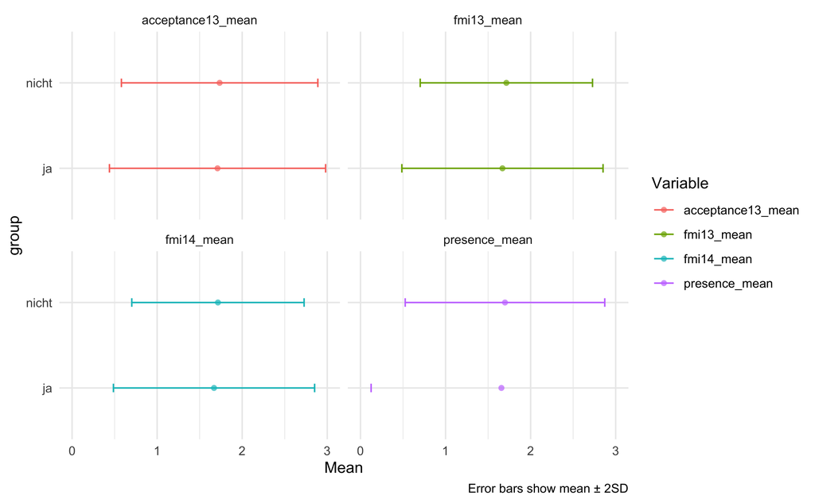

```r
plot_fmi_descriptives(data = d_w_items,
                      var = Vip_regel)
```

### 7.4.2 Norms

```r
for (i in unique(d_w_items$Vip_regel)) {
  cat("Group: ", i, "\n")
  d_w_items %>%
    filter(Vip_regel == i) %>%
    select(ends_with("_mean")) %>%
    map(~ knitr::kable(compute_all_norms(., min_score = 0, max_score = 3, by = .1),
                       digits = 2)) %>%
    print()
}
```

Group: nicht $fmi13_mean

| score | perc_rank | z | stanine | T | perc_normal |
| --- | --- | --- | --- | --- | --- |
| 0.0 | 0.00 | -3.39 | 1.00 | 16.14 | 0.00 |
| 0.1 | 0.00 | -3.19 | 1.00 | 18.11 | 0.00 |
| 0.2 | 0.00 | -2.99 | 1.00 | 20.09 | 0.00 |
| 0.3 | 0.01 | -2.79 | 1.00 | 22.06 | 0.00 |
| 0.4 | 0.01 | -2.60 | 1.00 | 24.04 | 0.00 |
| 0.5 | 0.01 | -2.40 | 1.00 | 26.01 | 0.01 |
| 0.6 | 0.02 | -2.20 | 1.00 | 27.99 | 0.01 |
| 0.7 | 0.03 | -2.00 | 1.00 | 29.96 | 0.02 |
| 0.8 | 0.04 | -1.81 | 1.39 | 31.93 | 0.04 |
| 0.9 | 0.05 | -1.61 | 1.78 | 33.91 | 0.05 |
| 1.0 | 0.09 | -1.41 | 2.18 | 35.88 | 0.08 |
| 1.1 | 0.12 | -1.21 | 2.57 | 37.86 | 0.11 |
| 1.2 | 0.15 | -1.02 | 2.97 | 39.83 | 0.15 |
| 1.3 | 0.21 | -0.82 | 3.36 | 41.81 | 0.21 |
| 1.4 | 0.25 | -0.62 | 3.76 | 43.78 | 0.27 |
| 1.5 | 0.34 | -0.42 | 4.15 | 45.76 | 0.34 |
| 1.6 | 0.39 | -0.23 | 4.55 | 47.73 | 0.41 |
| 1.7 | 0.45 | -0.03 | 4.94 | 49.70 | 0.49 |
| 1.8 | 0.58 | 0.17 | 5.34 | 51.68 | 0.57 |
| 1.9 | 0.63 | 0.37 | 5.73 | 53.65 | 0.64 |
| 2.0 | 0.76 | 0.56 | 6.13 | 55.63 | 0.71 |
| 2.1 | 0.80 | 0.76 | 6.52 | 57.60 | 0.78 |
| 2.2 | 0.83 | 0.96 | 6.92 | 59.58 | 0.83 |
| 2.3 | 0.89 | 1.16 | 7.31 | 61.55 | 0.88 |
| 2.4 | 0.91 | 1.35 | 7.71 | 63.53 | 0.91 |
| 2.5 | 0.95 | 1.55 | 8.10 | 65.50 | 0.94 |
| 2.6 | 0.96 | 1.75 | 8.50 | 67.48 | 0.96 |
| 2.7 | 0.97 | 1.94 | 8.89 | 69.45 | 0.97 |
| 2.8 | 0.99 | 2.14 | 9.00 | 71.42 | 0.98 |
| 2.9 | 0.99 | 2.34 | 9.00 | 73.40 | 0.99 |
| 3.0 | 1.00 | 2.54 | 9.00 | 75.37 | 0.99 |

$presence_mean

| score | perc_rank | z | stanine | T | perc_normal |
| --- | --- | --- | --- | --- | --- |
| 0.0 | 0.01 | -2.90 | 1.00 | 21.04 | 0.00 |
| 0.1 | 0.01 | -2.73 | 1.00 | 22.75 | 0.00 |
| 0.2 | 0.01 | -2.55 | 1.00 | 24.45 | 0.01 |
| 0.3 | 0.01 | -2.38 | 1.00 | 26.16 | 0.01 |
| 0.4 | 0.02 | -2.21 | 1.00 | 27.86 | 0.01 |
| 0.5 | 0.04 | -2.04 | 1.00 | 29.56 | 0.02 |
| 0.6 | 0.04 | -1.87 | 1.25 | 31.27 | 0.03 |
| 0.7 | 0.06 | -1.70 | 1.59 | 32.97 | 0.04 |
| 0.8 | 0.06 | -1.53 | 1.94 | 34.68 | 0.06 |
| 0.9 | 0.09 | -1.36 | 2.28 | 36.38 | 0.09 |
| 1.0 | 0.14 | -1.19 | 2.62 | 38.09 | 0.12 |
| 1.1 | 0.14 | -1.02 | 2.96 | 39.79 | 0.15 |
| 1.2 | 0.21 | -0.85 | 3.30 | 41.50 | 0.20 |
| 1.3 | 0.21 | -0.68 | 3.64 | 43.20 | 0.25 |
| 1.4 | 0.29 | -0.51 | 3.98 | 44.91 | 0.31 |
| 1.5 | 0.40 | -0.34 | 4.32 | 46.61 | 0.37 |
| 1.6 | 0.40 | -0.17 | 4.66 | 48.32 | 0.43 |
| 1.7 | 0.51 | 0.00 | 5.00 | 50.02 | 0.50 |
| 1.8 | 0.51 | 0.17 | 5.35 | 51.73 | 0.57 |
| 1.9 | 0.64 | 0.34 | 5.69 | 53.43 | 0.63 |
| 2.0 | 0.77 | 0.51 | 6.03 | 55.14 | 0.70 |
| 2.1 | 0.77 | 0.68 | 6.37 | 56.84 | 0.75 |
| 2.2 | 0.84 | 0.85 | 6.71 | 58.55 | 0.80 |
| 2.3 | 0.84 | 1.03 | 7.05 | 60.25 | 0.85 |
| 2.4 | 0.89 | 1.20 | 7.39 | 61.96 | 0.88 |
| 2.5 | 0.94 | 1.37 | 7.73 | 63.66 | 0.91 |
| 2.6 | 0.94 | 1.54 | 8.07 | 65.37 | 0.94 |
| 2.7 | 0.96 | 1.71 | 8.41 | 67.07 | 0.96 |
| 2.8 | 0.96 | 1.88 | 8.76 | 68.78 | 0.97 |
| 2.9 | 0.98 | 2.05 | 9.00 | 70.48 | 0.98 |
| 3.0 | 1.00 | 2.22 | 9.00 | 72.19 | 0.99 |

$acceptance13_mean

| score | perc_rank | z | stanine | T | perc_normal |
| --- | --- | --- | --- | --- | --- |
| 0.0 | 0.01 | -3.00 | 1.00 | 19.96 | 0.00 |
| 0.1 | 0.01 | -2.83 | 1.00 | 21.69 | 0.00 |
| 0.2 | 0.01 | -2.66 | 1.00 | 23.42 | 0.00 |
| 0.3 | 0.02 | -2.48 | 1.00 | 25.15 | 0.01 |
| 0.4 | 0.02 | -2.31 | 1.00 | 26.88 | 0.01 |
| 0.5 | 0.03 | -2.14 | 1.00 | 28.62 | 0.02 |
| 0.6 | 0.03 | -1.97 | 1.07 | 30.35 | 0.02 |
| 0.7 | 0.03 | -1.79 | 1.42 | 32.08 | 0.04 |
| 0.8 | 0.05 | -1.62 | 1.76 | 33.81 | 0.05 |
| 0.9 | 0.08 | -1.45 | 2.11 | 35.54 | 0.07 |
| 1.0 | 0.13 | -1.27 | 2.46 | 37.28 | 0.10 |
| 1.1 | 0.13 | -1.10 | 2.80 | 39.01 | 0.14 |
| 1.2 | 0.17 | -0.93 | 3.15 | 40.74 | 0.18 |
| 1.3 | 0.24 | -0.75 | 3.49 | 42.47 | 0.23 |
| 1.4 | 0.24 | -0.58 | 3.84 | 44.20 | 0.28 |
| 1.5 | 0.33 | -0.41 | 4.19 | 45.93 | 0.34 |
| 1.6 | 0.42 | -0.23 | 4.53 | 47.67 | 0.41 |
| 1.7 | 0.42 | -0.06 | 4.88 | 49.40 | 0.48 |
| 1.8 | 0.51 | 0.11 | 5.23 | 51.13 | 0.55 |
| 1.9 | 0.63 | 0.29 | 5.57 | 52.86 | 0.61 |
| 2.0 | 0.75 | 0.46 | 5.92 | 54.59 | 0.68 |
| 2.1 | 0.75 | 0.63 | 6.27 | 56.33 | 0.74 |
| 2.2 | 0.82 | 0.81 | 6.61 | 58.06 | 0.79 |
| 2.3 | 0.87 | 0.98 | 6.96 | 59.79 | 0.84 |
| 2.4 | 0.87 | 1.15 | 7.30 | 61.52 | 0.88 |
| 2.5 | 0.90 | 1.33 | 7.65 | 63.25 | 0.91 |
| 2.6 | 0.94 | 1.50 | 8.00 | 64.99 | 0.93 |
| 2.7 | 0.94 | 1.67 | 8.34 | 66.72 | 0.95 |
| 2.8 | 0.96 | 1.85 | 8.69 | 68.45 | 0.97 |
| 2.9 | 0.98 | 2.02 | 9.00 | 70.18 | 0.98 |
| 3.0 | 1.00 | 2.19 | 9.00 | 71.91 | 0.99 |

$fmi14_mean

| score | perc_rank | z | stanine | T | perc_normal |
| --- | --- | --- | --- | --- | --- |
| 0.0 | 0.00 | -3.39 | 1.00 | 16.14 | 0.00 |
| 0.1 | 0.00 | -3.19 | 1.00 | 18.11 | 0.00 |
| 0.2 | 0.00 | -2.99 | 1.00 | 20.09 | 0.00 |
| 0.3 | 0.01 | -2.79 | 1.00 | 22.06 | 0.00 |
| 0.4 | 0.01 | -2.60 | 1.00 | 24.04 | 0.00 |
| 0.5 | 0.01 | -2.40 | 1.00 | 26.01 | 0.01 |
| 0.6 | 0.02 | -2.20 | 1.00 | 27.99 | 0.01 |
| 0.7 | 0.03 | -2.00 | 1.00 | 29.96 | 0.02 |
| 0.8 | 0.04 | -1.81 | 1.39 | 31.93 | 0.04 |
| 0.9 | 0.05 | -1.61 | 1.78 | 33.91 | 0.05 |
| 1.0 | 0.09 | -1.41 | 2.18 | 35.88 | 0.08 |
| 1.1 | 0.12 | -1.21 | 2.57 | 37.86 | 0.11 |
| 1.2 | 0.15 | -1.02 | 2.97 | 39.83 | 0.15 |
| 1.3 | 0.21 | -0.82 | 3.36 | 41.81 | 0.21 |
| 1.4 | 0.25 | -0.62 | 3.76 | 43.78 | 0.27 |
| 1.5 | 0.34 | -0.42 | 4.15 | 45.76 | 0.34 |
| 1.6 | 0.39 | -0.23 | 4.55 | 47.73 | 0.41 |
| 1.7 | 0.45 | -0.03 | 4.94 | 49.70 | 0.49 |
| 1.8 | 0.58 | 0.17 | 5.34 | 51.68 | 0.57 |
| 1.9 | 0.63 | 0.37 | 5.73 | 53.65 | 0.64 |
| 2.0 | 0.76 | 0.56 | 6.13 | 55.63 | 0.71 |
| 2.1 | 0.80 | 0.76 | 6.52 | 57.60 | 0.78 |
| 2.2 | 0.83 | 0.96 | 6.92 | 59.58 | 0.83 |
| 2.3 | 0.89 | 1.16 | 7.31 | 61.55 | 0.88 |
| 2.4 | 0.91 | 1.35 | 7.71 | 63.53 | 0.91 |
| 2.5 | 0.95 | 1.55 | 8.10 | 65.50 | 0.94 |
| 2.6 | 0.96 | 1.75 | 8.50 | 67.48 | 0.96 |
| 2.7 | 0.97 | 1.94 | 8.89 | 69.45 | 0.97 |
| 2.8 | 0.99 | 2.14 | 9.00 | 71.42 | 0.98 |
| 2.9 | 0.99 | 2.34 | 9.00 | 73.40 | 0.99 |
| 3.0 | 1.00 | 2.54 | 9.00 | 75.37 | 0.99 |

Group: ja $fmi13_mean

| score | perc_rank | z | stanine | T | perc_normal |
| --- | --- | --- | --- | --- | --- |
| 0.0 | 0.00 | -2.82 | 1.00 | 21.78 | 0.00 |
| 0.1 | 0.00 | -2.65 | 1.00 | 23.47 | 0.00 |
| 0.2 | 0.00 | -2.48 | 1.00 | 25.16 | 0.01 |
| 0.3 | 0.00 | -2.31 | 1.00 | 26.85 | 0.01 |
| 0.4 | 0.00 | -2.15 | 1.00 | 28.55 | 0.02 |
| 0.5 | 0.06 | -1.98 | 1.05 | 30.24 | 0.02 |
| 0.6 | 0.09 | -1.81 | 1.39 | 31.93 | 0.04 |
| 0.7 | 0.09 | -1.64 | 1.72 | 33.62 | 0.05 |
| 0.8 | 0.09 | -1.47 | 2.06 | 35.31 | 0.07 |
| 0.9 | 0.09 | -1.30 | 2.40 | 37.00 | 0.10 |
| 1.0 | 0.12 | -1.13 | 2.74 | 38.69 | 0.13 |
| 1.1 | 0.12 | -0.96 | 3.08 | 40.38 | 0.17 |
| 1.2 | 0.12 | -0.79 | 3.41 | 42.07 | 0.21 |
| 1.3 | 0.21 | -0.62 | 3.75 | 43.76 | 0.27 |
| 1.4 | 0.27 | -0.45 | 4.09 | 45.45 | 0.32 |
| 1.5 | 0.39 | -0.29 | 4.43 | 47.15 | 0.39 |
| 1.6 | 0.52 | -0.12 | 4.77 | 48.84 | 0.45 |
| 1.7 | 0.52 | 0.05 | 5.11 | 50.53 | 0.52 |
| 1.8 | 0.70 | 0.22 | 5.44 | 52.22 | 0.59 |
| 1.9 | 0.73 | 0.39 | 5.78 | 53.91 | 0.65 |
| 2.0 | 0.73 | 0.56 | 6.12 | 55.60 | 0.71 |
| 2.1 | 0.73 | 0.73 | 6.46 | 57.29 | 0.77 |
| 2.2 | 0.79 | 0.90 | 6.80 | 58.98 | 0.82 |
| 2.3 | 0.85 | 1.07 | 7.13 | 60.67 | 0.86 |
| 2.4 | 0.88 | 1.24 | 7.47 | 62.36 | 0.89 |
| 2.5 | 0.94 | 1.41 | 7.81 | 64.05 | 0.92 |
| 2.6 | 0.94 | 1.57 | 8.15 | 65.75 | 0.94 |
| 2.7 | 0.94 | 1.74 | 8.49 | 67.44 | 0.96 |
| 2.8 | 1.00 | 1.91 | 8.83 | 69.13 | 0.97 |
| 2.9 | 1.00 | 2.08 | 9.00 | 70.82 | 0.98 |
| 3.0 | 1.00 | 2.25 | 9.00 | 72.51 | 0.99 |

$presence_mean

| score | perc_rank | z | stanine | T | perc_normal |
| --- | --- | --- | --- | --- | --- |
| 0.0 | 0.03 | -2.16 | 1.00 | 28.37 | 0.02 |
| 0.1 | 0.03 | -2.03 | 1.00 | 29.68 | 0.02 |
| 0.2 | 0.09 | -1.90 | 1.20 | 30.98 | 0.03 |
| 0.3 | 0.09 | -1.77 | 1.46 | 32.29 | 0.04 |
| 0.4 | 0.09 | -1.64 | 1.72 | 33.59 | 0.05 |
| 0.5 | 0.09 | -1.51 | 1.98 | 34.90 | 0.07 |
| 0.6 | 0.09 | -1.38 | 2.24 | 36.21 | 0.08 |
| 0.7 | 0.12 | -1.25 | 2.50 | 37.51 | 0.11 |
| 0.8 | 0.12 | -1.12 | 2.76 | 38.82 | 0.13 |
| 0.9 | 0.15 | -0.99 | 3.02 | 40.12 | 0.16 |
| 1.0 | 0.21 | -0.86 | 3.29 | 41.43 | 0.20 |
| 1.1 | 0.21 | -0.73 | 3.55 | 42.73 | 0.23 |
| 1.2 | 0.24 | -0.60 | 3.81 | 44.04 | 0.28 |
| 1.3 | 0.24 | -0.47 | 4.07 | 45.34 | 0.32 |
| 1.4 | 0.30 | -0.33 | 4.33 | 46.65 | 0.37 |
| 1.5 | 0.45 | -0.20 | 4.59 | 47.96 | 0.42 |
| 1.6 | 0.45 | -0.07 | 4.85 | 49.26 | 0.47 |
| 1.7 | 0.58 | 0.06 | 5.11 | 50.57 | 0.52 |
| 1.8 | 0.58 | 0.19 | 5.37 | 51.87 | 0.57 |
| 1.9 | 0.67 | 0.32 | 5.64 | 53.18 | 0.62 |
| 2.0 | 0.67 | 0.45 | 5.90 | 54.48 | 0.67 |
| 2.1 | 0.67 | 0.58 | 6.16 | 55.79 | 0.72 |
| 2.2 | 0.76 | 0.71 | 6.42 | 57.09 | 0.76 |
| 2.3 | 0.76 | 0.84 | 6.68 | 58.40 | 0.80 |
| 2.4 | 0.82 | 0.97 | 6.94 | 59.71 | 0.83 |
| 2.5 | 0.91 | 1.10 | 7.20 | 61.01 | 0.86 |
| 2.6 | 0.91 | 1.23 | 7.46 | 62.32 | 0.89 |
| 2.7 | 0.91 | 1.36 | 7.72 | 63.62 | 0.91 |
| 2.8 | 0.91 | 1.49 | 7.99 | 64.93 | 0.93 |
| 2.9 | 0.97 | 1.62 | 8.25 | 66.23 | 0.95 |
| 3.0 | 1.00 | 1.75 | 8.51 | 67.54 | 0.96 |

$acceptance13_mean

| score | perc_rank | z | stanine | T | perc_normal |
| --- | --- | --- | --- | --- | --- |
| 0.0 | 0.00 | -2.69 | 1.00 | 23.09 | 0.00 |
| 0.1 | 0.00 | -2.53 | 1.00 | 24.66 | 0.01 |
| 0.2 | 0.00 | -2.38 | 1.00 | 26.23 | 0.01 |
| 0.3 | 0.03 | -2.22 | 1.00 | 27.81 | 0.01 |
| 0.4 | 0.03 | -2.06 | 1.00 | 29.38 | 0.02 |
| 0.5 | 0.03 | -1.90 | 1.19 | 30.96 | 0.03 |
| 0.6 | 0.06 | -1.75 | 1.51 | 32.53 | 0.04 |
| 0.7 | 0.06 | -1.59 | 1.82 | 34.10 | 0.06 |
| 0.8 | 0.09 | -1.43 | 2.14 | 35.68 | 0.08 |
| 0.9 | 0.12 | -1.27 | 2.45 | 37.25 | 0.10 |
| 1.0 | 0.12 | -1.12 | 2.77 | 38.83 | 0.13 |
| 1.1 | 0.12 | -0.96 | 3.08 | 40.40 | 0.17 |
| 1.2 | 0.18 | -0.80 | 3.39 | 41.97 | 0.21 |
| 1.3 | 0.24 | -0.65 | 3.71 | 43.55 | 0.26 |
| 1.4 | 0.24 | -0.49 | 4.02 | 45.12 | 0.31 |
| 1.5 | 0.33 | -0.33 | 4.34 | 46.70 | 0.37 |
| 1.6 | 0.45 | -0.17 | 4.65 | 48.27 | 0.43 |
| 1.7 | 0.45 | -0.02 | 4.97 | 49.84 | 0.49 |
| 1.8 | 0.64 | 0.14 | 5.28 | 51.42 | 0.56 |
| 1.9 | 0.67 | 0.30 | 5.60 | 52.99 | 0.62 |
| 2.0 | 0.73 | 0.46 | 5.91 | 54.57 | 0.68 |
| 2.1 | 0.73 | 0.61 | 6.23 | 56.14 | 0.73 |
| 2.2 | 0.82 | 0.77 | 6.54 | 57.71 | 0.78 |
| 2.3 | 0.85 | 0.93 | 6.86 | 59.29 | 0.82 |
| 2.4 | 0.85 | 1.09 | 7.17 | 60.86 | 0.86 |
| 2.5 | 0.85 | 1.24 | 7.49 | 62.43 | 0.89 |
| 2.6 | 0.91 | 1.40 | 7.80 | 64.01 | 0.92 |
| 2.7 | 0.91 | 1.56 | 8.12 | 65.58 | 0.94 |
| 2.8 | 0.94 | 1.72 | 8.43 | 67.16 | 0.96 |
| 2.9 | 0.97 | 1.87 | 8.75 | 68.73 | 0.97 |
| 3.0 | 1.00 | 2.03 | 9.00 | 70.30 | 0.98 |

$fmi14_mean

| score | perc_rank | z | stanine | T | perc_normal |
| --- | --- | --- | --- | --- | --- |
| 0.0 | 0.00 | -2.82 | 1.00 | 21.78 | 0.00 |
| 0.1 | 0.00 | -2.65 | 1.00 | 23.47 | 0.00 |
| 0.2 | 0.00 | -2.48 | 1.00 | 25.16 | 0.01 |
| 0.3 | 0.00 | -2.31 | 1.00 | 26.85 | 0.01 |
| 0.4 | 0.00 | -2.15 | 1.00 | 28.55 | 0.02 |
| 0.5 | 0.06 | -1.98 | 1.05 | 30.24 | 0.02 |
| 0.6 | 0.09 | -1.81 | 1.39 | 31.93 | 0.04 |
| 0.7 | 0.09 | -1.64 | 1.72 | 33.62 | 0.05 |
| 0.8 | 0.09 | -1.47 | 2.06 | 35.31 | 0.07 |
| 0.9 | 0.09 | -1.30 | 2.40 | 37.00 | 0.10 |
| 1.0 | 0.12 | -1.13 | 2.74 | 38.69 | 0.13 |
| 1.1 | 0.12 | -0.96 | 3.08 | 40.38 | 0.17 |
| 1.2 | 0.12 | -0.79 | 3.41 | 42.07 | 0.21 |
| 1.3 | 0.21 | -0.62 | 3.75 | 43.76 | 0.27 |
| 1.4 | 0.27 | -0.45 | 4.09 | 45.45 | 0.32 |
| 1.5 | 0.39 | -0.29 | 4.43 | 47.15 | 0.39 |
| 1.6 | 0.52 | -0.12 | 4.77 | 48.84 | 0.45 |
| 1.7 | 0.52 | 0.05 | 5.11 | 50.53 | 0.52 |
| 1.8 | 0.70 | 0.22 | 5.44 | 52.22 | 0.59 |
| 1.9 | 0.73 | 0.39 | 5.78 | 53.91 | 0.65 |
| 2.0 | 0.73 | 0.56 | 6.12 | 55.60 | 0.71 |
| 2.1 | 0.73 | 0.73 | 6.46 | 57.29 | 0.77 |
| 2.2 | 0.79 | 0.90 | 6.80 | 58.98 | 0.82 |
| 2.3 | 0.85 | 1.07 | 7.13 | 60.67 | 0.86 |
| 2.4 | 0.88 | 1.24 | 7.47 | 62.36 | 0.89 |
| 2.5 | 0.94 | 1.41 | 7.81 | 64.05 | 0.92 |
| 2.6 | 0.94 | 1.57 | 8.15 | 65.75 | 0.94 |
| 2.7 | 0.94 | 1.74 | 8.49 | 67.44 | 0.96 |
| 2.8 | 1.00 | 1.91 | 8.83 | 69.13 | 0.97 |
| 2.9 | 1.00 | 2.08 | 9.00 | 70.82 | 0.98 |
| 3.0 | 1.00 | 2.25 | 9.00 | 72.51 | 0.99 |

## 7.5 Split by Age

### 7.5.1 Stats

Median age in sample?

```r
d_w_items$Alter %>% median()
```

```
## [1] 49
```

```r
d_w_items <-
  d_w_items %>%
  mutate(age_below_md = if_else(Alter < median(Alter), "young", "old"))
```

```r
describe_fmi_stats(data = d_w_items,
                   var = age_below_md)
```

age_below_md=old

| Variable | Mean | Mean_01 | SD | Range | Quartiles | Skewness | Kurtosis | n | n_Missing |
| --- | --- | --- | --- | --- | --- | --- | --- | --- | --- |
| acceptance13_mean | 1.76 | 0.59 | 0.59 | (0.00, 3.00) | 1.43, 2.14 | -0.38 | 0.41 | 526 | 0 |
| fmi13_mean | 1.74 | 0.58 | 0.51 | (0.21, 3.00) | 1.43, 2.07 | -0.29 | 0.25 | 526 | 0 |
| fmi14_mean | 1.74 | 0.58 | 0.51 | (0.21, 3.00) | 1.43, 2.07 | -0.29 | 0.25 | 526 | 0 |
| presence_mean | 1.71 | 0.57 | 0.58 | (0.00, 3.00) | 1.33, 2.00 | -0.38 | 0.39 | 526 | 0 |

age_below_md=young

| Variable | Mean | Mean_01 | SD | Range | Quartiles | Skewness | Kurtosis | n | n_Missing |
| --- | --- | --- | --- | --- | --- | --- | --- | --- | --- |
| acceptance13_mean | 1.70 | 0.57 | 0.56 | (0.00, 3.00) | 1.29, 2.00 | -0.03 | 0.17 | 486 | 0 |
| fmi13_mean | 1.68 | 0.56 | 0.50 | (0.21, 3.00) | 1.36, 2.00 | 0.01 | 0.14 | 486 | 0 |
| fmi14_mean | 1.68 | 0.56 | 0.50 | (0.21, 3.00) | 1.36, 2.00 | 0.01 | 0.14 | 486 | 0 |
| presence_mean | 1.68 | 0.56 | 0.60 | (0.00, 3.00) | 1.33, 2.00 | -0.09 | 0.05 | 486 | 0 |

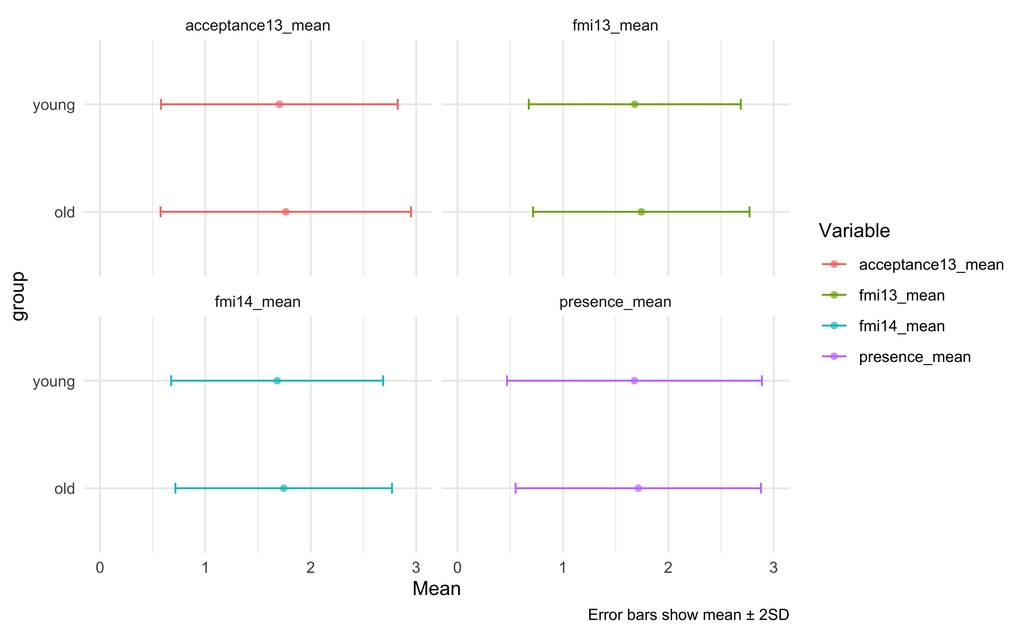

```r
plot_fmi_descriptives(data = d_w_items,
                      var = age_below_md)
```

### 7.5.2 Norms

```r
for (i in unique(d_w_items$age_below_md)) {
  cat("Group: ", i, "\n")
  d_w_items %>%
    filter(age_below_md == i) %>%
    select(ends_with("_mean")) %>%
    map(~ knitr::kable(compute_all_norms(., min_score = 0, max_score = 3, by = .1),
                       digits = 2)) %>%
    print()
}
```

Group: young $fmi13_mean

| score | perc_rank | z | stanine | T | perc_normal |
| --- | --- | --- | --- | --- | --- |
| 0.0 | 0.00 | -3.34 | 1.00 | 16.56 | 0.00 |
| 0.1 | 0.00 | -3.14 | 1.00 | 18.55 | 0.00 |
| 0.2 | 0.00 | -2.95 | 1.00 | 20.54 | 0.00 |
| 0.3 | 0.01 | -2.75 | 1.00 | 22.53 | 0.00 |
| 0.4 | 0.01 | -2.55 | 1.00 | 24.52 | 0.01 |
| 0.5 | 0.01 | -2.35 | 1.00 | 26.51 | 0.01 |
| 0.6 | 0.02 | -2.15 | 1.00 | 28.50 | 0.02 |
| 0.7 | 0.02 | -1.95 | 1.10 | 30.49 | 0.03 |
| 0.8 | 0.04 | -1.75 | 1.49 | 32.47 | 0.04 |
| 0.9 | 0.06 | -1.55 | 1.89 | 34.46 | 0.06 |
| 1.0 | 0.09 | -1.35 | 2.29 | 36.45 | 0.09 |
| 1.1 | 0.12 | -1.16 | 2.69 | 38.44 | 0.12 |
| 1.2 | 0.16 | -0.96 | 3.09 | 40.43 | 0.17 |
| 1.3 | 0.22 | -0.76 | 3.48 | 42.42 | 0.22 |
| 1.4 | 0.27 | -0.56 | 3.88 | 44.41 | 0.29 |
| 1.5 | 0.39 | -0.36 | 4.28 | 46.40 | 0.36 |
| 1.6 | 0.45 | -0.16 | 4.68 | 48.38 | 0.44 |
| 1.7 | 0.50 | 0.04 | 5.07 | 50.37 | 0.51 |
| 1.8 | 0.62 | 0.24 | 5.47 | 52.36 | 0.59 |
| 1.9 | 0.66 | 0.44 | 5.87 | 54.35 | 0.67 |
| 2.0 | 0.78 | 0.63 | 6.27 | 56.34 | 0.74 |
| 2.1 | 0.83 | 0.83 | 6.67 | 58.33 | 0.80 |
| 2.2 | 0.86 | 1.03 | 7.06 | 60.32 | 0.85 |
| 2.3 | 0.90 | 1.23 | 7.46 | 62.31 | 0.89 |
| 2.4 | 0.91 | 1.43 | 7.86 | 64.29 | 0.92 |
| 2.5 | 0.95 | 1.63 | 8.26 | 66.28 | 0.95 |
| 2.6 | 0.96 | 1.83 | 8.65 | 68.27 | 0.97 |
| 2.7 | 0.96 | 2.03 | 9.00 | 70.26 | 0.98 |
| 2.8 | 0.99 | 2.22 | 9.00 | 72.25 | 0.99 |
| 2.9 | 0.99 | 2.42 | 9.00 | 74.24 | 0.99 |
| 3.0 | 1.00 | 2.62 | 9.00 | 76.23 | 1.00 |

$presence_mean

| score | perc_rank | z | stanine | T | perc_normal |
| --- | --- | --- | --- | --- | --- |
| 0.0 | 0.01 | -2.78 | 1.00 | 22.23 | 0.00 |
| 0.1 | 0.01 | -2.61 | 1.00 | 23.89 | 0.00 |
| 0.2 | 0.02 | -2.45 | 1.00 | 25.54 | 0.01 |
| 0.3 | 0.02 | -2.28 | 1.00 | 27.20 | 0.01 |
| 0.4 | 0.02 | -2.11 | 1.00 | 28.85 | 0.02 |
| 0.5 | 0.03 | -1.95 | 1.10 | 30.51 | 0.03 |
| 0.6 | 0.03 | -1.78 | 1.43 | 32.16 | 0.04 |
| 0.7 | 0.07 | -1.62 | 1.76 | 33.82 | 0.05 |
| 0.8 | 0.07 | -1.45 | 2.09 | 35.47 | 0.07 |
| 0.9 | 0.10 | -1.29 | 2.42 | 37.12 | 0.10 |
| 1.0 | 0.15 | -1.12 | 2.76 | 38.78 | 0.13 |
| 1.1 | 0.15 | -0.96 | 3.09 | 40.43 | 0.17 |
| 1.2 | 0.23 | -0.79 | 3.42 | 42.09 | 0.21 |
| 1.3 | 0.23 | -0.63 | 3.75 | 43.74 | 0.27 |
| 1.4 | 0.31 | -0.46 | 4.08 | 45.40 | 0.32 |
| 1.5 | 0.43 | -0.30 | 4.41 | 47.05 | 0.38 |
| 1.6 | 0.43 | -0.13 | 4.74 | 48.70 | 0.45 |
| 1.7 | 0.56 | 0.04 | 5.07 | 50.36 | 0.51 |
| 1.8 | 0.56 | 0.20 | 5.40 | 52.01 | 0.58 |
| 1.9 | 0.66 | 0.37 | 5.73 | 53.67 | 0.64 |
| 2.0 | 0.77 | 0.53 | 6.06 | 55.32 | 0.70 |
| 2.1 | 0.77 | 0.70 | 6.40 | 56.98 | 0.76 |
| 2.2 | 0.84 | 0.86 | 6.73 | 58.63 | 0.81 |
| 2.3 | 0.84 | 1.03 | 7.06 | 60.28 | 0.85 |
| 2.4 | 0.88 | 1.19 | 7.39 | 61.94 | 0.88 |
| 2.5 | 0.92 | 1.36 | 7.72 | 63.59 | 0.91 |
| 2.6 | 0.92 | 1.52 | 8.05 | 65.25 | 0.94 |
| 2.7 | 0.95 | 1.69 | 8.38 | 66.90 | 0.95 |
| 2.8 | 0.95 | 1.86 | 8.71 | 68.56 | 0.97 |
| 2.9 | 0.97 | 2.02 | 9.00 | 70.21 | 0.98 |
| 3.0 | 1.00 | 2.19 | 9.00 | 71.86 | 0.99 |

$acceptance13_mean

| score | perc_rank | z | stanine | T | perc_normal |
| --- | --- | --- | --- | --- | --- |
| 0.0 | 0.00 | -3.03 | 1.00 | 19.67 | 0.00 |
| 0.1 | 0.00 | -2.85 | 1.00 | 21.45 | 0.00 |
| 0.2 | 0.01 | -2.68 | 1.00 | 23.23 | 0.00 |
| 0.3 | 0.01 | -2.50 | 1.00 | 25.02 | 0.01 |
| 0.4 | 0.01 | -2.32 | 1.00 | 26.80 | 0.01 |
| 0.5 | 0.02 | -2.14 | 1.00 | 28.58 | 0.02 |
| 0.6 | 0.03 | -1.96 | 1.07 | 30.36 | 0.02 |
| 0.7 | 0.03 | -1.79 | 1.43 | 32.14 | 0.04 |
| 0.8 | 0.04 | -1.61 | 1.78 | 33.92 | 0.05 |
| 0.9 | 0.08 | -1.43 | 2.14 | 35.70 | 0.08 |
| 1.0 | 0.13 | -1.25 | 2.50 | 37.49 | 0.11 |
| 1.1 | 0.13 | -1.07 | 2.85 | 39.27 | 0.14 |
| 1.2 | 0.18 | -0.90 | 3.21 | 41.05 | 0.19 |
| 1.3 | 0.26 | -0.72 | 3.57 | 42.83 | 0.24 |
| 1.4 | 0.26 | -0.54 | 3.92 | 44.61 | 0.29 |
| 1.5 | 0.35 | -0.36 | 4.28 | 46.39 | 0.36 |
| 1.6 | 0.46 | -0.18 | 4.63 | 48.17 | 0.43 |
| 1.7 | 0.46 | 0.00 | 4.99 | 49.95 | 0.50 |
| 1.8 | 0.55 | 0.17 | 5.35 | 51.74 | 0.57 |
| 1.9 | 0.66 | 0.35 | 5.70 | 53.52 | 0.64 |
| 2.0 | 0.78 | 0.53 | 6.06 | 55.30 | 0.70 |
| 2.1 | 0.78 | 0.71 | 6.42 | 57.08 | 0.76 |
| 2.2 | 0.84 | 0.89 | 6.77 | 58.86 | 0.81 |
| 2.3 | 0.89 | 1.06 | 7.13 | 60.64 | 0.86 |
| 2.4 | 0.89 | 1.24 | 7.48 | 62.42 | 0.89 |
| 2.5 | 0.91 | 1.42 | 7.84 | 64.21 | 0.92 |
| 2.6 | 0.94 | 1.60 | 8.20 | 65.99 | 0.95 |
| 2.7 | 0.94 | 1.78 | 8.55 | 67.77 | 0.96 |
| 2.8 | 0.96 | 1.96 | 8.91 | 69.55 | 0.97 |
| 2.9 | 0.98 | 2.13 | 9.00 | 71.33 | 0.98 |
| 3.0 | 1.00 | 2.31 | 9.00 | 73.11 | 0.99 |

$fmi14_mean

| score | perc_rank | z | stanine | T | perc_normal |
| --- | --- | --- | --- | --- | --- |
| 0.0 | 0.00 | -3.34 | 1.00 | 16.56 | 0.00 |
| 0.1 | 0.00 | -3.14 | 1.00 | 18.55 | 0.00 |
| 0.2 | 0.00 | -2.95 | 1.00 | 20.54 | 0.00 |
| 0.3 | 0.01 | -2.75 | 1.00 | 22.53 | 0.00 |
| 0.4 | 0.01 | -2.55 | 1.00 | 24.52 | 0.01 |
| 0.5 | 0.01 | -2.35 | 1.00 | 26.51 | 0.01 |
| 0.6 | 0.02 | -2.15 | 1.00 | 28.50 | 0.02 |
| 0.7 | 0.02 | -1.95 | 1.10 | 30.49 | 0.03 |
| 0.8 | 0.04 | -1.75 | 1.49 | 32.47 | 0.04 |
| 0.9 | 0.06 | -1.55 | 1.89 | 34.46 | 0.06 |
| 1.0 | 0.09 | -1.35 | 2.29 | 36.45 | 0.09 |
| 1.1 | 0.12 | -1.16 | 2.69 | 38.44 | 0.12 |
| 1.2 | 0.16 | -0.96 | 3.09 | 40.43 | 0.17 |
| 1.3 | 0.22 | -0.76 | 3.48 | 42.42 | 0.22 |
| 1.4 | 0.27 | -0.56 | 3.88 | 44.41 | 0.29 |
| 1.5 | 0.39 | -0.36 | 4.28 | 46.40 | 0.36 |
| 1.6 | 0.45 | -0.16 | 4.68 | 48.38 | 0.44 |
| 1.7 | 0.50 | 0.04 | 5.07 | 50.37 | 0.51 |
| 1.8 | 0.62 | 0.24 | 5.47 | 52.36 | 0.59 |
| 1.9 | 0.66 | 0.44 | 5.87 | 54.35 | 0.67 |
| 2.0 | 0.78 | 0.63 | 6.27 | 56.34 | 0.74 |
| 2.1 | 0.83 | 0.83 | 6.67 | 58.33 | 0.80 |
| 2.2 | 0.86 | 1.03 | 7.06 | 60.32 | 0.85 |
| 2.3 | 0.90 | 1.23 | 7.46 | 62.31 | 0.89 |
| 2.4 | 0.91 | 1.43 | 7.86 | 64.29 | 0.92 |
| 2.5 | 0.95 | 1.63 | 8.26 | 66.28 | 0.95 |
| 2.6 | 0.96 | 1.83 | 8.65 | 68.27 | 0.97 |
| 2.7 | 0.96 | 2.03 | 9.00 | 70.26 | 0.98 |
| 2.8 | 0.99 | 2.22 | 9.00 | 72.25 | 0.99 |
| 2.9 | 0.99 | 2.42 | 9.00 | 74.24 | 0.99 |
| 3.0 | 1.00 | 2.62 | 9.00 | 76.23 | 1.00 |

Group: old $fmi13_mean

| score | perc_rank | z | stanine | T | perc_normal |
| --- | --- | --- | --- | --- | --- |
| 0.0 | 0.00 | -3.39 | 1.00 | 16.06 | 0.00 |
| 0.1 | 0.00 | -3.20 | 1.00 | 18.01 | 0.00 |
| 0.2 | 0.00 | -3.00 | 1.00 | 19.96 | 0.00 |
| 0.3 | 0.01 | -2.81 | 1.00 | 21.90 | 0.00 |
| 0.4 | 0.01 | -2.61 | 1.00 | 23.85 | 0.00 |
| 0.5 | 0.02 | -2.42 | 1.00 | 25.80 | 0.01 |
| 0.6 | 0.03 | -2.23 | 1.00 | 27.74 | 0.01 |
| 0.7 | 0.03 | -2.03 | 1.00 | 29.69 | 0.02 |
| 0.8 | 0.05 | -1.84 | 1.33 | 31.64 | 0.03 |
| 0.9 | 0.05 | -1.64 | 1.72 | 33.58 | 0.05 |
| 1.0 | 0.09 | -1.45 | 2.11 | 35.53 | 0.07 |
| 1.1 | 0.12 | -1.25 | 2.50 | 37.48 | 0.11 |
| 1.2 | 0.14 | -1.06 | 2.88 | 39.42 | 0.15 |
| 1.3 | 0.20 | -0.86 | 3.27 | 41.37 | 0.19 |
| 1.4 | 0.23 | -0.67 | 3.66 | 43.32 | 0.25 |
| 1.5 | 0.29 | -0.47 | 4.05 | 45.27 | 0.32 |
| 1.6 | 0.34 | -0.28 | 4.44 | 47.21 | 0.39 |
| 1.7 | 0.41 | -0.08 | 4.83 | 49.16 | 0.47 |
| 1.8 | 0.54 | 0.11 | 5.22 | 51.11 | 0.54 |
| 1.9 | 0.61 | 0.31 | 5.61 | 53.05 | 0.62 |
| 2.0 | 0.74 | 0.50 | 6.00 | 55.00 | 0.69 |
| 2.1 | 0.77 | 0.69 | 6.39 | 56.95 | 0.76 |
| 2.2 | 0.81 | 0.89 | 6.78 | 58.89 | 0.81 |
| 2.3 | 0.89 | 1.08 | 7.17 | 60.84 | 0.86 |
| 2.4 | 0.90 | 1.28 | 7.56 | 62.79 | 0.90 |
| 2.5 | 0.94 | 1.47 | 7.95 | 64.73 | 0.93 |
| 2.6 | 0.96 | 1.67 | 8.34 | 66.68 | 0.95 |
| 2.7 | 0.97 | 1.86 | 8.73 | 68.63 | 0.97 |
| 2.8 | 0.99 | 2.06 | 9.00 | 70.57 | 0.98 |
| 2.9 | 0.99 | 2.25 | 9.00 | 72.52 | 0.99 |
| 3.0 | 1.00 | 2.45 | 9.00 | 74.47 | 0.99 |

$presence_mean

| score | perc_rank | z | stanine | T | perc_normal |
| --- | --- | --- | --- | --- | --- |
| 0.0 | 0.01 | -2.95 | 1.00 | 20.53 | 0.00 |
| 0.1 | 0.01 | -2.78 | 1.00 | 22.25 | 0.00 |
| 0.2 | 0.01 | -2.60 | 1.00 | 23.97 | 0.00 |
| 0.3 | 0.01 | -2.43 | 1.00 | 25.69 | 0.01 |
| 0.4 | 0.03 | -2.26 | 1.00 | 27.41 | 0.01 |
| 0.5 | 0.05 | -2.09 | 1.00 | 29.12 | 0.02 |
| 0.6 | 0.05 | -1.92 | 1.17 | 30.84 | 0.03 |
| 0.7 | 0.06 | -1.74 | 1.51 | 32.56 | 0.04 |
| 0.8 | 0.06 | -1.57 | 1.86 | 34.28 | 0.06 |
| 0.9 | 0.09 | -1.40 | 2.20 | 36.00 | 0.08 |
| 1.0 | 0.14 | -1.23 | 2.54 | 37.72 | 0.11 |
| 1.1 | 0.14 | -1.06 | 2.89 | 39.43 | 0.15 |
| 1.2 | 0.19 | -0.88 | 3.23 | 41.15 | 0.19 |
| 1.3 | 0.19 | -0.71 | 3.57 | 42.87 | 0.24 |
| 1.4 | 0.28 | -0.54 | 3.92 | 44.59 | 0.29 |
| 1.5 | 0.37 | -0.37 | 4.26 | 46.31 | 0.36 |
| 1.6 | 0.37 | -0.20 | 4.61 | 48.03 | 0.42 |
| 1.7 | 0.48 | -0.03 | 4.95 | 49.75 | 0.49 |
| 1.8 | 0.48 | 0.15 | 5.29 | 51.46 | 0.56 |
| 1.9 | 0.61 | 0.32 | 5.64 | 53.18 | 0.62 |
| 2.0 | 0.77 | 0.49 | 5.98 | 54.90 | 0.69 |
| 2.1 | 0.77 | 0.66 | 6.32 | 56.62 | 0.75 |
| 2.2 | 0.84 | 0.83 | 6.67 | 58.34 | 0.80 |
| 2.3 | 0.84 | 1.01 | 7.01 | 60.06 | 0.84 |
| 2.4 | 0.90 | 1.18 | 7.35 | 61.77 | 0.88 |
| 2.5 | 0.94 | 1.35 | 7.70 | 63.49 | 0.91 |
| 2.6 | 0.94 | 1.52 | 8.04 | 65.21 | 0.94 |
| 2.7 | 0.96 | 1.69 | 8.39 | 66.93 | 0.95 |
| 2.8 | 0.96 | 1.86 | 8.73 | 68.65 | 0.97 |
| 2.9 | 0.98 | 2.04 | 9.00 | 70.37 | 0.98 |
| 3.0 | 1.00 | 2.21 | 9.00 | 72.09 | 0.99 |

$acceptance13_mean

| score | perc_rank | z | stanine | T | perc_normal |
| --- | --- | --- | --- | --- | --- |
| 0.0 | 0.01 | -2.97 | 1.00 | 20.32 | 0.00 |
| 0.1 | 0.01 | -2.80 | 1.00 | 22.00 | 0.00 |
| 0.2 | 0.02 | -2.63 | 1.00 | 23.69 | 0.00 |
| 0.3 | 0.02 | -2.46 | 1.00 | 25.37 | 0.01 |
| 0.4 | 0.02 | -2.29 | 1.00 | 27.05 | 0.01 |
| 0.5 | 0.03 | -2.13 | 1.00 | 28.74 | 0.02 |
| 0.6 | 0.04 | -1.96 | 1.08 | 30.42 | 0.03 |
| 0.7 | 0.04 | -1.79 | 1.42 | 32.11 | 0.04 |
| 0.8 | 0.06 | -1.62 | 1.76 | 33.79 | 0.05 |
| 0.9 | 0.08 | -1.45 | 2.09 | 35.47 | 0.07 |
| 1.0 | 0.12 | -1.28 | 2.43 | 37.16 | 0.10 |
| 1.1 | 0.12 | -1.12 | 2.77 | 38.84 | 0.13 |
| 1.2 | 0.16 | -0.95 | 3.10 | 40.52 | 0.17 |
| 1.3 | 0.23 | -0.78 | 3.44 | 42.21 | 0.22 |
| 1.4 | 0.23 | -0.61 | 3.78 | 43.89 | 0.27 |
| 1.5 | 0.30 | -0.44 | 4.11 | 45.57 | 0.33 |
| 1.6 | 0.37 | -0.27 | 4.45 | 47.26 | 0.39 |
| 1.7 | 0.37 | -0.11 | 4.79 | 48.94 | 0.46 |
| 1.8 | 0.48 | 0.06 | 5.12 | 50.62 | 0.52 |
| 1.9 | 0.60 | 0.23 | 5.46 | 52.31 | 0.59 |
| 2.0 | 0.73 | 0.40 | 5.80 | 53.99 | 0.66 |
| 2.1 | 0.73 | 0.57 | 6.14 | 55.68 | 0.71 |
| 2.2 | 0.81 | 0.74 | 6.47 | 57.36 | 0.77 |
| 2.3 | 0.85 | 0.90 | 6.81 | 59.04 | 0.82 |
| 2.4 | 0.85 | 1.07 | 7.15 | 60.73 | 0.86 |
| 2.5 | 0.89 | 1.24 | 7.48 | 62.41 | 0.89 |
| 2.6 | 0.94 | 1.41 | 7.82 | 64.09 | 0.92 |
| 2.7 | 0.94 | 1.58 | 8.16 | 65.78 | 0.94 |
| 2.8 | 0.96 | 1.75 | 8.49 | 67.46 | 0.96 |
| 2.9 | 0.97 | 1.91 | 8.83 | 69.14 | 0.97 |
| 3.0 | 1.00 | 2.08 | 9.00 | 70.83 | 0.98 |

$fmi14_mean

| score | perc_rank | z | stanine | T | perc_normal |
| --- | --- | --- | --- | --- | --- |
| 0.0 | 0.00 | -3.39 | 1.00 | 16.06 | 0.00 |
| 0.1 | 0.00 | -3.20 | 1.00 | 18.01 | 0.00 |
| 0.2 | 0.00 | -3.00 | 1.00 | 19.96 | 0.00 |
| 0.3 | 0.01 | -2.81 | 1.00 | 21.90 | 0.00 |
| 0.4 | 0.01 | -2.61 | 1.00 | 23.85 | 0.00 |
| 0.5 | 0.02 | -2.42 | 1.00 | 25.80 | 0.01 |
| 0.6 | 0.03 | -2.23 | 1.00 | 27.74 | 0.01 |
| 0.7 | 0.03 | -2.03 | 1.00 | 29.69 | 0.02 |
| 0.8 | 0.05 | -1.84 | 1.33 | 31.64 | 0.03 |
| 0.9 | 0.05 | -1.64 | 1.72 | 33.58 | 0.05 |
| 1.0 | 0.09 | -1.45 | 2.11 | 35.53 | 0.07 |
| 1.1 | 0.12 | -1.25 | 2.50 | 37.48 | 0.11 |
| 1.2 | 0.14 | -1.06 | 2.88 | 39.42 | 0.15 |
| 1.3 | 0.20 | -0.86 | 3.27 | 41.37 | 0.19 |
| 1.4 | 0.23 | -0.67 | 3.66 | 43.32 | 0.25 |
| 1.5 | 0.29 | -0.47 | 4.05 | 45.27 | 0.32 |
| 1.6 | 0.34 | -0.28 | 4.44 | 47.21 | 0.39 |
| 1.7 | 0.41 | -0.08 | 4.83 | 49.16 | 0.47 |
| 1.8 | 0.54 | 0.11 | 5.22 | 51.11 | 0.54 |
| 1.9 | 0.61 | 0.31 | 5.61 | 53.05 | 0.62 |
| 2.0 | 0.74 | 0.50 | 6.00 | 55.00 | 0.69 |
| 2.1 | 0.77 | 0.69 | 6.39 | 56.95 | 0.76 |
| 2.2 | 0.81 | 0.89 | 6.78 | 58.89 | 0.81 |
| 2.3 | 0.89 | 1.08 | 7.17 | 60.84 | 0.86 |
| 2.4 | 0.90 | 1.28 | 7.56 | 62.79 | 0.90 |
| 2.5 | 0.94 | 1.47 | 7.95 | 64.73 | 0.93 |
| 2.6 | 0.96 | 1.67 | 8.34 | 66.68 | 0.95 |
| 2.7 | 0.97 | 1.86 | 8.73 | 68.63 | 0.97 |
| 2.8 | 0.99 | 2.06 | 9.00 | 70.57 | 0.98 |
| 2.9 | 0.99 | 2.25 | 9.00 | 72.52 | 0.99 |
| 3.0 | 1.00 | 2.45 | 9.00 | 74.47 | 0.99 |

# 8 Overview on descriptive statistics per subgroup

```r
subgroup_stats <- list()

for (i in seq_along(subgroup_vars)){

subgroup_stats[[i]] <-
  d_w_items %>%
  select(ends_with("mean"),
         any_of(subgroup_vars)[i]) %>%
  group_by(across(any_of(subgroup_vars[i]))) %>%
    describe_distribution() %>%
  select(Variable, Mean, SD, IQR, Min, Max, n, .group)

subgroup_stats[[i]][["subgroup_var"]] <- subgroup_vars[i]
}

subgroup_stats_df <- do.call(rbind, subgroup_stats)

subgroup_stats_df <-
  subgroup_stats_df %>%
  mutate(group = str_remove(.group, "^.+=")) %>%
  select(-.group)

display(subgroup_stats_df)
```

| Variable | Mean | SD | IQR | Range | n | subgroup_var | group |
| --- | --- | --- | --- | --- | --- | --- | --- |
| fmi13_mean | 1.71 | 0.51 | 0.71 | (0.21, 3.00) | 515 | Geschlecht | female |
| presence_mean | 1.72 | 0.58 | 0.67 | (0.00, 3.00) | 515 | Geschlecht | female |
| acceptance13_mean | 1.73 | 0.57 | 0.86 | (0.00, 3.00) | 515 | Geschlecht | female |
| fmi14_mean | 1.71 | 0.51 | 0.71 | (0.21, 3.00) | 515 | Geschlecht | female |
| fmi13_mean | 1.71 | 0.51 | 0.57 | (0.21, 3.00) | 495 | Geschlecht | male |
| presence_mean | 1.67 | 0.60 | 0.67 | (0.00, 3.00) | 495 | Geschlecht | male |
| acceptance13_mean | 1.74 | 0.59 | 0.57 | (0.00, 3.00) | 495 | Geschlecht | male |
| fmi14_mean | 1.71 | 0.51 | 0.57 | (0.21, 3.00) | 495 | Geschlecht | male |
| fmi13_mean | 1.50 | 0.20 | 0.29 | (1.36, 1.64) | 2 | Geschlecht | other |
| presence_mean | 1.33 | 0.00 | 0.00 | (1.33, 1.33) | 2 | Geschlecht | other |
| acceptance13_mean | 1.79 | 0.51 | 0.71 | (1.43, 2.14) | 2 | Geschlecht | other |
| fmi14_mean | 1.50 | 0.20 | 0.29 | (1.36, 1.64) | 2 | Geschlecht | other |
| fmi13_mean | 1.69 | 0.51 | 0.64 | (0.21, 3.00) | 792 | Achts_regel | no |
| presence_mean | 1.65 | 0.59 | 0.67 | (0.00, 3.00) | 792 | Achts_regel | no |
| acceptance13_mean | 1.72 | 0.59 | 0.71 | (0.00, 3.00) | 792 | Achts_regel | no |
| fmi14_mean | 1.69 | 0.51 | 0.64 | (0.21, 3.00) | 792 | Achts_regel | no |
| fmi13_mean | 1.81 | 0.49 | 0.57 | (0.21, 3.00) | 220 | Achts_regel | yes |
| presence_mean | 1.86 | 0.56 | 0.67 | (0.00, 3.00) | 220 | Achts_regel | yes |
| acceptance13_mean | 1.80 | 0.55 | 0.71 | (0.00, 3.00) | 220 | Achts_regel | yes |
| fmi14_mean | 1.81 | 0.49 | 0.57 | (0.21, 3.00) | 220 | Achts_regel | yes |
| fmi13_mean | 1.82 | 0.43 | 0.43 | (0.71, 3.00) | 116 | Retreats | Multiple retreats per year |
| presence_mean | 1.84 | 0.50 | 0.62 | (0.33, 3.00) | 116 | Retreats | Multiple retreats per year |
| acceptance13_mean | 1.81 | 0.48 | 0.54 | (0.71, 3.00) | 116 | Retreats | Multiple retreats per year |
| fmi14_mean | 1.82 | 0.43 | 0.43 | (0.71, 3.00) | 116 | Retreats | Multiple retreats per year |
| fmi13_mean | 1.68 | 0.52 | 0.64 | (0.21, 3.00) | 673 | Retreats | Never |
| presence_mean | 1.64 | 0.59 | 0.67 | (0.00, 3.00) | 673 | Retreats | Never |
| acceptance13_mean | 1.70 | 0.60 | 0.71 | (0.00, 3.00) | 673 | Retreats | Never |
| fmi14_mean | 1.68 | 0.52 | 0.64 | (0.21, 3.00) | 673 | Retreats | Never |
| fmi13_mean | 1.71 | 0.45 | 0.57 | (0.57, 2.93) | 58 | Retreats | Once a year |
| presence_mean | 1.68 | 0.55 | 0.67 | (0.17, 3.00) | 58 | Retreats | Once a year |
| acceptance13_mean | 1.73 | 0.50 | 0.57 | (0.71, 3.00) | 58 | Retreats | Once a year |
| fmi14_mean | 1.71 | 0.45 | 0.57 | (0.57, 2.93) | 58 | Retreats | Once a year |
| fmi13_mean | 1.71 | 0.46 | 0.71 | (0.93, 2.93) | 86 | Retreats | Once every couple of years |
| presence_mean | 1.71 | 0.59 | 0.83 | (0.67, 3.00) | 86 | Retreats | Once every couple of years |
| acceptance13_mean | 1.74 | 0.53 | 0.71 | (0.29, 3.00) | 86 | Retreats | Once every couple of years |
| fmi14_mean | 1.71 | 0.46 | 0.71 | (0.93, 2.93) | 86 | Retreats | Once every couple of years |
| fmi13_mean | 1.89 | 0.55 | 0.71 | (0.29, 2.79) | 79 | Retreats | Rarely |
| presence_mean | 1.94 | 0.68 | 0.83 | (0.00, 3.00) | 79 | Retreats | Rarely |
| acceptance13_mean | 1.93 | 0.63 | 0.71 | (0.14, 3.00) | 79 | Retreats | Rarely |
| fmi14_mean | 1.89 | 0.55 | 0.71 | (0.29, 2.79) | 79 | Retreats | Rarely |
| fmi13_mean | 1.67 | 0.59 | 0.79 | (0.43, 2.79) | 33 | Vip_regel | ja |
| presence_mean | 1.66 | 0.77 | 1.00 | (0.00, 3.00) | 33 | Vip_regel | ja |
| acceptance13_mean | 1.71 | 0.64 | 0.79 | (0.29, 3.00) | 33 | Vip_regel | ja |
| fmi14_mean | 1.67 | 0.59 | 0.79 | (0.43, 2.79) | 33 | Vip_regel | ja |
| fmi13_mean | 1.71 | 0.51 | 0.64 | (0.21, 3.00) | 979 | Vip_regel | nicht |
| presence_mean | 1.70 | 0.59 | 0.67 | (0.00, 3.00) | 979 | Vip_regel | nicht |
| acceptance13_mean | 1.73 | 0.58 | 0.57 | (0.00, 3.00) | 979 | Vip_regel | nicht |
| fmi14_mean | 1.71 | 0.51 | 0.64 | (0.21, 3.00) | 979 | Vip_regel | nicht |
| fmi13_mean | 1.74 | 0.51 | 0.64 | (0.21, 3.00) | 526 | age_below_md | old |
| presence_mean | 1.71 | 0.58 | 0.67 | (0.00, 3.00) | 526 | age_below_md | old |
| acceptance13_mean | 1.76 | 0.59 | 0.71 | (0.00, 3.00) | 526 | age_below_md | old |
| fmi14_mean | 1.74 | 0.51 | 0.64 | (0.21, 3.00) | 526 | age_below_md | old |
| fmi13_mean | 1.68 | 0.50 | 0.64 | (0.21, 3.00) | 486 | age_below_md | young |
| presence_mean | 1.68 | 0.60 | 0.67 | (0.00, 3.00) | 486 | age_below_md | young |
| acceptance13_mean | 1.70 | 0.56 | 0.71 | (0.00, 3.00) | 486 | age_below_md | young |
| fmi14_mean | 1.68 | 0.50 | 0.64 | (0.21, 3.00) | 486 | age_below_md | young |

```r
subgroup_stats_long <-
subgroup_stats_df %>%
  select(Variable, Mean, SD, group, subgroup_var) %>%
  mutate(Subscale = str_remove(Variable, "_mean")) %>%
  pivot_longer(-c(Variable, group, Mean, Subscale, subgroup_var),
               values_to = "SD")

display(subgroup_stats_long)
```

| Variable | Mean | group | subgroup_var | Subscale | name | SD |
| --- | --- | --- | --- | --- | --- | --- |
| fmi13_mean | 1.71 | female | Geschlecht | fmi13 | SD | 0.51 |
| presence_mean | 1.72 | female | Geschlecht | presence | SD | 0.58 |
| acceptance13_mean | 1.73 | female | Geschlecht | acceptance13 | SD | 0.57 |
| fmi14_mean | 1.71 | female | Geschlecht | fmi14 | SD | 0.51 |
| fmi13_mean | 1.71 | male | Geschlecht | fmi13 | SD | 0.51 |
| presence_mean | 1.67 | male | Geschlecht | presence | SD | 0.60 |
| acceptance13_mean | 1.74 | male | Geschlecht | acceptance13 | SD | 0.59 |
| fmi14_mean | 1.71 | male | Geschlecht | fmi14 | SD | 0.51 |
| fmi13_mean | 1.50 | other | Geschlecht | fmi13 | SD | 0.20 |
| presence_mean | 1.33 | other | Geschlecht | presence | SD | 0.00 |
| acceptance13_mean | 1.79 | other | Geschlecht | acceptance13 | SD | 0.51 |
| fmi14_mean | 1.50 | other | Geschlecht | fmi14 | SD | 0.20 |
| fmi13_mean | 1.69 | no | Achts_regel | fmi13 | SD | 0.51 |
| presence_mean | 1.65 | no | Achts_regel | presence | SD | 0.59 |
| acceptance13_mean | 1.72 | no | Achts_regel | acceptance13 | SD | 0.59 |
| fmi14_mean | 1.69 | no | Achts_regel | fmi14 | SD | 0.51 |
| fmi13_mean | 1.81 | yes | Achts_regel | fmi13 | SD | 0.49 |
| presence_mean | 1.86 | yes | Achts_regel | presence | SD | 0.56 |
| acceptance13_mean | 1.80 | yes | Achts_regel | acceptance13 | SD | 0.55 |
| fmi14_mean | 1.81 | yes | Achts_regel | fmi14 | SD | 0.49 |
| fmi13_mean | 1.82 | Multiple retreats per year | Retreats | fmi13 | SD | 0.43 |
| presence_mean | 1.84 | Multiple retreats per year | Retreats | presence | SD | 0.50 |
| acceptance13_mean | 1.81 | Multiple retreats per year | Retreats | acceptance13 | SD | 0.48 |
| fmi14_mean | 1.82 | Multiple retreats per year | Retreats | fmi14 | SD | 0.43 |
| fmi13_mean | 1.68 | Never | Retreats | fmi13 | SD | 0.52 |
| presence_mean | 1.64 | Never | Retreats | presence | SD | 0.59 |
| acceptance13_mean | 1.70 | Never | Retreats | acceptance13 | SD | 0.60 |
| fmi14_mean | 1.68 | Never | Retreats | fmi14 | SD | 0.52 |
| fmi13_mean | 1.71 | Once a year | Retreats | fmi13 | SD | 0.45 |
| presence_mean | 1.68 | Once a year | Retreats | presence | SD | 0.55 |
| acceptance13_mean | 1.73 | Once a year | Retreats | acceptance13 | SD | 0.50 |
| fmi14_mean | 1.71 | Once a year | Retreats | fmi14 | SD | 0.45 |
| fmi13_mean | 1.71 | Once every couple of years | Retreats | fmi13 | SD | 0.46 |
| presence_mean | 1.71 | Once every couple of years | Retreats | presence | SD | 0.59 |
| acceptance13_mean | 1.74 | Once every couple of years | Retreats | acceptance13 | SD | 0.53 |
| fmi14_mean | 1.71 | Once every couple of years | Retreats | fmi14 | SD | 0.46 |
| fmi13_mean | 1.89 | Rarely | Retreats | fmi13 | SD | 0.55 |
| presence_mean | 1.94 | Rarely | Retreats | presence | SD | 0.68 |
| acceptance13_mean | 1.93 | Rarely | Retreats | acceptance13 | SD | 0.63 |
| fmi14_mean | 1.89 | Rarely | Retreats | fmi14 | SD | 0.55 |
| fmi13_mean | 1.67 | ja | Vip_regel | fmi13 | SD | 0.59 |
| presence_mean | 1.66 | ja | Vip_regel | presence | SD | 0.77 |
| acceptance13_mean | 1.71 | ja | Vip_regel | acceptance13 | SD | 0.64 |
| fmi14_mean | 1.67 | ja | Vip_regel | fmi14 | SD | 0.59 |
| fmi13_mean | 1.71 | nicht | Vip_regel | fmi13 | SD | 0.51 |
| presence_mean | 1.70 | nicht | Vip_regel | presence | SD | 0.59 |
| acceptance13_mean | 1.73 | nicht | Vip_regel | acceptance13 | SD | 0.58 |
| fmi14_mean | 1.71 | nicht | Vip_regel | fmi14 | SD | 0.51 |
| fmi13_mean | 1.74 | old | age_below_md | fmi13 | SD | 0.51 |
| presence_mean | 1.71 | old | age_below_md | presence | SD | 0.58 |
| acceptance13_mean | 1.76 | old | age_below_md | acceptance13 | SD | 0.59 |
| fmi14_mean | 1.74 | old | age_below_md | fmi14 | SD | 0.51 |
| fmi13_mean | 1.68 | young | age_below_md | fmi13 | SD | 0.50 |
| presence_mean | 1.68 | young | age_below_md | presence | SD | 0.60 |
| acceptance13_mean | 1.70 | young | age_below_md | acceptance13 | SD | 0.56 |
| fmi14_mean | 1.68 | young | age_below_md | fmi14 | SD | 0.50 |

```r
# subgroup_stats_long %>%
#   ggplot(aes(x = Variable, color = group)) +
#   geom_errorbar(aes(ymin = Mean-SD, ymax = Mean+SD), position = "dodge") +
#   geom_point2(aes(y = Mean), alpha = .7, size = 2) +
#   facet_wrap(subgroup_vars ~ Variable, scales = "free")
```

## 8.1 Regression models

### 8.1.1 m1

```r
m1 <- lm(phq_sum ~ presence_mean + acceptance13_mean, data = d_w_items)
parameters(m1) %>% display()

performance(m1) %>% display
summary(m1)
```

[output not shown]

Standardized data:

```r
parameters(m1, standardize = "refit") %>% display
```

[output not shown]